# Master Thesis R Markdown Code

Mihail Silvan Pop (607433)

2025-08-15

### 1. Data Preparation

#### 1.1 Loading Packages

```r
library(tidyr)
library(dplyr)
library(magrittr)
library(lubridate)
library(corrplot)
library(janitor)
library(stringr)
library(DT)
library(readr)
library(skimr)
library(plm)
library(ggplot2)
library(stargazer)
library(readxl)
library(tidyverse)
library(tidymodels)
library(vip)
library(car)
library(themis)
library(doParallel)
library(skimr)
library(DescTools)
library(MatchIt)
library(cobalt)
library(Hmisc)
library(xtable)
library(kableExtra)
library(knitr)
library(sandwich)
library(lmtest)
library(fixest)
library(scales)
```

#### 1.2 Set-up for Analysis

```r
# Creating file path for saving data, results, and figures
dir <- "/Users/mihail/Desktop/Master BAM/Thesis/"
dirRslt <- paste0(dir, "Results/")
dirData <- paste0(dir, "Data/")
dirFig <- paste0(dir, "Figures/")
```

#### 1.3 Importing Data

```r
compustat_global_df <- read.csv("/Users/mihail/Desktop/Master BAM/Thesis/compustat_global.csv")
compustat_global_prices_df <- read.csv("/Users/mihail/Desktop/Master BAM/Thesis/compustat_global_prices.csv")
compustat_na_df <- read.csv("/Users/mihail/Desktop/Master BAM/Thesis/compustat_na.csv")
worldbank_df <- read.csv("/Users/mihail/Desktop/Master BAM/Thesis/worldbankindicators.csv")
refinitiv_df <- read_excel("/Users/mihail/Desktop/Master BAM/Thesis/RefinitivESG.xlsx", sheet = "ISIN Code")
exchange_rates_df <- read.csv("/Users/mihail/Desktop/Master BAM/Thesis/imf_exchange_rates.csv")

skim(compustat_global_df)
```

Data summary

| Name | compustat_global_df |
| --- | --- |
| Number of rows | 541176 |
| Number of columns | 31 |
| _______________________ |  |
| Column type frequency: |  |
| character | 11 |
| numeric | 20 |
| ________________________ |  |
| Group variables | None |

**Variable type: character**

| skim_variable | n_missing | complete_rate | min | max | empty | n_unique | whitespace |
| --- | --- | --- | --- | --- | --- | --- | --- |
| fic | 0 | 1 | 3 | 3 | 0 | 118 | 0 |
| costat | 0 | 1 | 1 | 1 | 0 | 1 | 0 |
| datafmt | 0 | 1 | 8 | 8 | 0 | 1 | 0 |
| indfmt | 0 | 1 | 2 | 4 | 0 | 2 | 0 |
| consol | 0 | 1 | 1 | 1 | 0 | 1 | 0 |
| isin | 0 | 1 | 0 | 12 | 1996 | 39673 | 0 |
| datadate | 0 | 1 | 10 | 10 | 0 | 208 | 0 |
| conm | 0 | 1 | 3 | 36 | 0 | 39835 | 0 |
| sedol | 0 | 1 | 0 | 7 | 1084 | 39783 | 0 |
| loc | 0 | 1 | 3 | 3 | 0 | 130 | 0 |
| curcd | 0 | 1 | 0 | 3 | 66 | 90 | 0 |

**Variable type: numeric**

| skim_variable | n_missing | complete_rate | mean | sd | p0 | p25 | p50 | p75 | p100 | hist |
| --- | --- | --- | --- | --- | --- | --- | --- | --- | --- | --- |
| exchg | 736 | 1.00 | 213.77 | 60.77 | 1.000000e+00 | 170.00 | 225.00 | 260.00 | 353 | ▁▃▅▇▂ |
| fyr | 66 | 1.00 | 9.16 | 3.96 | 1.000000e+00 | 5.00 | 12.00 | 12.00 | 12 | ▃▁▁▁▇ |
| gvkey | 0 | 1.00 | 270477.77 | 64787.75 | 1.166000e+03 | 239624.00 | 284952.00 | 317879.00 | 366988 | ▁▁▃▇▇ |
| gind | 16484 | 0.97 | 316684.75 | 138424.34 | 1.010100e+05 | 201060.00 | 301010.00 | 451020.00 | 602010 | ▇▆▅▆▃ |
| gsector | 16484 | 0.97 | 31.49 | 13.83 | 1.000000e+01 | 20.00 | 30.00 | 45.00 | 60 | ▇▅▃▃▂ |
| sic | 1471 | 1.00 | 4476.43 | 2042.02 | 1.000000e+02 | 2851.00 | 3730.00 | 6211.00 | 9998 | ▂▇▃▅▁ |
| fyear | 66 | 1.00 | 2016.63 | 4.83 | 2.007000e+03 | 2013.00 | 2017.00 | 2021.00 | 2024 | ▅▅▇▆▇ |
| at | 1712 | 1.00 | 1039160.52 | 51878261.25 | -6.000000e-01 | 258.84 | 2030.73 | 18189.10 | 34628067959 | ▇▁▁▁▁ |
| che | 95528 | 0.82 | 44942.47 | 1180411.66 | -5.349300e+02 | 18.44 | 231.55 | 2070.16 | 590162750 | ▇▁▁▁▁ |
| dlc | 31490 | 0.94 | 62243.48 | 1601928.54 | -1.519400e+04 | 3.07 | 105.26 | 1289.88 | 838694428 | ▇▁▁▁▁ |
| dltt | 31269 | 0.94 | 120145.99 | 2221916.09 | -6.708000e+02 | 0.35 | 64.89 | 1287.88 | 249758798 | ▇▁▁▁▁ |
| ebit | 4278 | 0.99 | 46853.60 | 1467633.95 | -7.145724e+08 | 0.27 | 67.78 | 769.00 | 249947474 | ▁▁▁▇▁ |
| ebitda | 4069 | 0.99 | 61443.26 | 2070945.13 | -6.856812e+08 | 4.14 | 115.32 | 1212.72 | 976968227 | ▁▁▇▁▁ |
| lt | 1794 | 1.00 | 773047.17 | 24943202.19 | -1.025000e+01 | 85.98 | 829.31 | 8849.20 | 12635602399 | ▇▁▁▁▁ |
| oancf | 104442 | 0.81 | 25868.10 | 641728.89 | -2.347750e+07 | -0.23 | 64.07 | 731.00 | 175397274 | ▇▁▁▁▁ |
| ppent | 41068 | 0.92 | 154554.53 | 22714294.02 | -8.700000e-01 | 27.74 | 358.29 | 3724.54 | 15903720479 | ▇▁▁▁▁ |
| pstk | 98120 | 0.82 | 227.35 | 15166.43 | 0.000000e+00 | 0.00 | 0.00 | 0.00 | 5925326 | ▇▁▁▁▁ |
| revt | 1779 | 1.00 | 337511.46 | 39804338.41 | -1.099127e+07 | 112.02 | 1074.50 | 10487.90 | 28751774135 | ▇▁▁▁▁ |
| cshoi | 74617 | 0.86 | 1975.47 | 94775.48 | 0.000000e+00 | 18.00 | 99.49 | 460.00 | 14958536 | ▇▁▁▁▁ |
| nicon | 66028 | 0.88 | 16495.73 | 3682648.02 | -2.496821e+09 | -0.27 | 46.19 | 538.45 | 190376844 | ▁▁▁▁▇ |

```r
skim(compustat_global_prices_df)
```

Data summary

| Name | compustat_global_prices_d… |
| --- | --- |
| Number of rows | 9109222 |
| Number of columns | 7 |
| _______________________ |  |
| Column type frequency: |  |
| character | 5 |
| numeric | 2 |
| ________________________ |  |
| Group variables | None |

**Variable type: character**

| skim_variable | n_missing | complete_rate | min | max | empty | n_unique | whitespace |
| --- | --- | --- | --- | --- | --- | --- | --- |
| fic | 0 | 1 | 0 | 3 | 280772 | 124 | 0 |
| datadate | 0 | 1 | 10 | 10 | 0 | 204 | 0 |
| conm | 0 | 1 | 0 | 36 | 280772 | 54579 | 0 |
| curcdm | 0 | 1 | 0 | 3 | 53827 | 83 | 0 |
| loc | 0 | 1 | 0 | 3 | 280772 | 136 | 0 |

**Variable type: numeric**

| skim_variable | n_missing | complete_rate | mean | sd | p0 | p25 | p50 | p75 | p100 | hist |
| --- | --- | --- | --- | --- | --- | --- | --- | --- | --- | --- |
| gvkey | 0 | 1.00 | 252930.29 | 72268.42 | 5 | 212798.0 | 272482.00 | 297664 | 366450 | ▁▁▃▇▆ |
| prccm | 438052 | 0.95 | 7001.62 | 1244722.18 | 0 | 2.1 | 13.92 | 126 | 950000000 | ▇▁▁▁▁ |

```r
skim(compustat_na_df)
```

Data summary

| Name | compustat_na_df |
| --- | --- |
| Number of rows | 129315 |
| Number of columns | 30 |
| _______________________ |  |
| Column type frequency: |  |
| character | 11 |
| numeric | 19 |
| ________________________ |  |
| Group variables | None |

**Variable type: character**

| skim_variable | n_missing | complete_rate | min | max | empty | n_unique | whitespace |
| --- | --- | --- | --- | --- | --- | --- | --- |
| datadate | 0 | 1 | 10 | 10 | 0 | 208 | 0 |
| indfmt | 0 | 1 | 2 | 4 | 0 | 2 | 0 |
| consol | 0 | 1 | 1 | 1 | 0 | 1 | 0 |
| popsrc | 0 | 1 | 1 | 1 | 0 | 1 | 0 |
| datafmt | 0 | 1 | 3 | 3 | 0 | 1 | 0 |
| tic | 5 | 1 | 0 | 8 | 20 | 11863 | 0 |
| conm | 0 | 1 | 2 | 30 | 0 | 11865 | 0 |
| curcd | 0 | 1 | 3 | 3 | 0 | 1 | 0 |
| costat | 0 | 1 | 1 | 1 | 0 | 1 | 0 |
| fic | 0 | 1 | 3 | 3 | 0 | 58 | 0 |
| loc | 0 | 1 | 3 | 3 | 0 | 68 | 0 |

**Variable type: numeric**

| skim_variable | n_missing | complete_rate | mean | sd | p0 | p25 | p50 | p75 | p100 | hist |
| --- | --- | --- | --- | --- | --- | --- | --- | --- | --- | --- |
| gvkey | 0 | 1.00 | 81004.22 | 73500.81 | 1004.00 | 21194.00 | 39047.00 | 160252.00 | 356128.0 | ▇▁▃▁▁ |
| fyear | 0 | 1.00 | 2017.19 | 4.85 | 2007.00 | 2013.00 | 2018.00 | 2021.00 | 2024.0 | ▃▃▆▅▇ |
| at | 34093 | 0.74 | 29671.30 | 188287.03 | 0.00 | 117.74 | 1065.85 | 5921.53 | 4349731.0 | ▇▁▁▁▁ |
| che | 46857 | 0.64 | 2618.10 | 24915.63 | -8.03 | 9.43 | 70.49 | 370.70 | 1058786.1 | ▇▁▁▁▁ |
| csho | 16438 | 0.87 | 252.10 | 4932.27 | 0.00 | 8.09 | 31.52 | 102.10 | 606407.7 | ▇▁▁▁▁ |
| dlc | 34852 | 0.73 | 2104.58 | 19713.51 | 0.00 | 0.19 | 9.01 | 131.62 | 614237.4 | ▇▁▁▁▁ |
| dltt | 34323 | 0.73 | 5853.18 | 77566.31 | 0.00 | 1.09 | 85.01 | 1206.17 | 4216909.0 | ▇▁▁▁▁ |
| ebit | 47068 | 0.64 | 782.82 | 4055.70 | -80053.00 | -3.21 | 23.74 | 279.79 | 141290.0 | ▁▇▁▁▁ |
| ebitda | 49530 | 0.62 | 1105.15 | 4911.02 | -76735.00 | -1.42 | 37.37 | 415.73 | 141290.0 | ▁▇▁▁▁ |
| lt | 34222 | 0.74 | 25502.04 | 176964.49 | 0.00 | 41.00 | 630.02 | 3923.20 | 4255074.0 | ▇▁▁▁▁ |
| ni | 47041 | 0.64 | 399.26 | 2508.67 | -99289.00 | -8.68 | 7.19 | 141.82 | 104821.0 | ▁▁▇▁▁ |
| oancf | 47441 | 0.63 | 842.75 | 4599.92 | -110136.62 | -1.27 | 27.81 | 310.28 | 182220.0 | ▁▇▁▁▁ |
| ppent | 37044 | 0.71 | 2472.40 | 11640.27 | 0.00 | 3.85 | 47.14 | 588.80 | 328806.0 | ▇▁▁▁▁ |
| revt | 34317 | 0.73 | 5453.47 | 22177.80 | -24954.68 | 29.86 | 298.88 | 2173.76 | 680985.0 | ▇▁▁▁▁ |
| exchg | 20 | 1.00 | 14.22 | 3.78 | 0.00 | 11.00 | 14.00 | 17.00 | 21.0 | ▁▁▇▇▇ |
| prcc_f | 9758 | 0.92 | 52.96 | 726.76 | 0.00 | 7.19 | 20.75 | 42.53 | 99200.0 | ▇▁▁▁▁ |
| gind | 32351 | 0.75 | 351888.23 | 128506.71 | 101010.00 | 252030.00 | 401010.00 | 403010.00 | 602010.0 | ▅▃▇▆▃ |
| gsector | 32351 | 0.75 | 35.02 | 12.86 | 10.00 | 25.00 | 40.00 | 40.00 | 60.0 | ▅▂▇▃▂ |
| sic | 0 | 1.00 | 5414.26 | 1862.60 | 100.00 | 3714.00 | 6020.00 | 6722.00 | 9998.0 | ▁▅▃▇▁ |

```r
skim(worldbank_df)
```

Data summary

| Name | worldbank_df |
| --- | --- |
| Number of rows | 173 |
| Number of columns | 21 |
| _______________________ |  |
| Column type frequency: |  |
| character | 7 |
| numeric | 14 |
| ________________________ |  |
| Group variables | None |

**Variable type: character**

| skim_variable | n_missing | complete_rate | min | max | empty | n_unique | whitespace |
| --- | --- | --- | --- | --- | --- | --- | --- |
| Country.Name | 0 | 1 | 0 | 48 | 3 | 31 | 0 |
| Country.Code | 0 | 1 | 0 | 3 | 5 | 29 | 0 |
| Series.Name | 0 | 1 | 0 | 64 | 5 | 7 | 0 |
| Series.Code | 0 | 1 | 0 | 17 | 5 | 7 | 0 |
| X2022..YR2022. | 0 | 1 | 0 | 18 | 5 | 148 | 0 |
| X2023..YR2023. | 0 | 1 | 0 | 20 | 5 | 148 | 0 |
| X2024..YR2024. | 0 | 1 | 0 | 2 | 5 | 2 | 0 |

**Variable type: numeric**

| skim_variable | n_missing | complete_rate | mean | sd | p0 | p25 | p50 | p75 | p100 | hist |
| --- | --- | --- | --- | --- | --- | --- | --- | --- | --- | --- |
| X2008..YR2008. | 5 | 0.97 | 185327447860 | 1.214992e+12 | -5.13 | 1.74 | 3.17 | 7.15 | 1.476986e+13 | ▇▁▁▁▁ |
| X2009..YR2009. | 5 | 0.97 | 174550031994 | 1.181371e+12 | -16.04 | 0.61 | 1.76 | 8.33 | 1.447807e+13 | ▇▁▁▁▁ |
| X2010..YR2010. | 5 | 0.97 | 176740567253 | 1.220950e+12 | -5.69 | 1.21 | 1.91 | 9.42 | 1.504897e+13 | ▇▁▁▁▁ |
| X2011..YR2011. | 5 | 0.97 | 187359299995 | 1.272202e+12 | -9.88 | 1.25 | 2.08 | 8.51 | 1.559973e+13 | ▇▁▁▁▁ |
| X2012..YR2012. | 5 | 0.97 | 184452083089 | 1.310752e+12 | -8.33 | 0.75 | 1.89 | 9.89 | 1.625397e+13 | ▇▁▁▁▁ |
| X2013..YR2013. | 5 | 0.97 | 192147086054 | 1.362482e+12 | -6.59 | 0.42 | 1.78 | 9.96 | 1.688068e+13 | ▇▁▁▁▁ |
| X2014..YR2014. | 5 | 0.97 | 198648517320 | 1.419271e+12 | -1.92 | 0.63 | 1.97 | 9.06 | 1.760814e+13 | ▇▁▁▁▁ |
| X2015..YR2015. | 5 | 0.97 | 190179219466 | 1.453961e+12 | -0.75 | 0.80 | 2.26 | 9.13 | 1.829502e+13 | ▇▁▁▁▁ |
| X2016..YR2016. | 5 | 0.97 | 195209428256 | 1.494287e+12 | -1.11 | 0.60 | 2.12 | 7.64 | 1.880491e+13 | ▇▁▁▁▁ |
| X2017..YR2017. | 5 | 0.97 | 205250998174 | 1.559759e+12 | -2.45 | 1.01 | 2.27 | 7.08 | 1.961210e+13 | ▇▁▁▁▁ |
| X2018..YR2018. | 5 | 0.97 | 218738117747 | 1.645046e+12 | -3.22 | 1.01 | 2.27 | 6.25 | 2.065652e+13 | ▇▁▁▁▁ |
| X2019..YR2019. | 5 | 0.97 | 222311787596 | 1.708433e+12 | -2.86 | 0.98 | 2.41 | 5.63 | 2.153998e+13 | ▇▁▁▁▁ |
| X2020..YR2020. | 5 | 0.97 | 219397648868 | 1.692565e+12 | -10.94 | 0.00 | 1.59 | 6.77 | 2.135410e+13 | ▇▁▁▁▁ |
| X2021..YR2021. | 5 | 0.97 | 245105490895 | 1.877655e+12 | -3.26 | 1.09 | 4.13 | 7.61 | 2.368117e+13 | ▇▁▁▁▁ |

```r
skim(refinitiv_df)
```

Data summary

| Name | refinitiv_df |
| --- | --- |
| Number of rows | 230202 |
| Number of columns | 28 |
| _______________________ |  |
| Column type frequency: |  |
| character | 28 |
| ________________________ |  |
| Group variables | None |

**Variable type: character**

| skim_variable | n_missing | complete_rate | min | max | empty | n_unique | whitespace |
| --- | --- | --- | --- | --- | --- | --- | --- |
| NAME | 0 | 1.00 | 14 | 57 | 0 | 220416 | 0 |
| DATATYPE | 0 | 1.00 | 6 | 10 | 0 | 21 | 0 |
| COUNTRY | 0 | 1.00 | 5 | 18 | 0 | 55 | 0 |
| ISIN CODE | 0 | 1.00 | 2 | 12 | 0 | 10962 | 0 |
| SEDOL | 0 | 1.00 | 4 | 7 | 0 | 10962 | 0 |
| IBES TICKER | 0 | 1.00 | 1 | 10 | 0 | 10676 | 0 |
| TICKER SYMBOL | 0 | 1.00 | 1 | 11 | 0 | 10236 | 0 |
| SIC CODE | 0 | 1.00 | 2 | 4 | 0 | 636 | 0 |
| ICB industry name | 0 | 1.00 | 2 | 22 | 0 | 12 | 0 |
| ICB sector name | 0 | 1.00 | 2 | 46 | 0 | 46 | 0 |
| Y2008 | 9267 | 0.96 | 1 | 19 | 0 | 7553 | 0 |
| Y2009 | 9267 | 0.96 | 1 | 19 | 0 | 8007 | 0 |
| Y2010 | 9267 | 0.96 | 1 | 19 | 0 | 8588 | 0 |
| Y2011 | 9267 | 0.96 | 1 | 19 | 0 | 8731 | 0 |
| Y2012 | 9267 | 0.96 | 1 | 19 | 0 | 8848 | 0 |
| Y2013 | 9267 | 0.96 | 1 | 19 | 0 | 8962 | 0 |
| Y2014 | 9267 | 0.96 | 1 | 19 | 0 | 9031 | 0 |
| Y2015 | 9267 | 0.96 | 1 | 19 | 0 | 9334 | 0 |
| Y2016 | 9267 | 0.96 | 1 | 19 | 0 | 9518 | 0 |
| Y2017 | 9267 | 0.96 | 1 | 19 | 0 | 9729 | 0 |
| Y2018 | 9267 | 0.96 | 1 | 21 | 0 | 9828 | 0 |
| Y2019 | 9267 | 0.96 | 1 | 21 | 0 | 9918 | 0 |
| Y2020 | 9267 | 0.96 | 1 | 19 | 0 | 9965 | 0 |
| Y2021 | 9267 | 0.96 | 1 | 21 | 0 | 9974 | 0 |
| Y2022 | 9267 | 0.96 | 1 | 21 | 0 | 9991 | 0 |
| Y2023 | 9267 | 0.96 | 1 | 21 | 0 | 9940 | 0 |
| Y2024 | 9267 | 0.96 | 1 | 21 | 0 | 5875 | 0 |
| ISIN Code check good or wrong | 0 | 1.00 | 4 | 5 | 0 | 2 | 0 |

```r
skim(exchange_rates_df)
```

Data summary

| Name | exchange_rates_df |
| --- | --- |
| Number of rows | 153 |
| Number of columns | 3 |
| _______________________ |  |
| Column type frequency: |  |
| character | 1 |
| numeric | 2 |
| ________________________ |  |
| Group variables | None |

**Variable type: character**

| skim_variable | n_missing | complete_rate | min | max | empty | n_unique | whitespace |
| --- | --- | --- | --- | --- | --- | --- | --- |
| curcd | 0 | 1 | 3 | 3 | 0 | 9 | 0 |

**Variable type: numeric**

| skim_variable | n_missing | complete_rate | mean | sd | p0 | p25 | p50 | p75 | p100 | hist |
| --- | --- | --- | --- | --- | --- | --- | --- | --- | --- | --- |
| fyear | 0 | 1 | 2016.00 | 4.92 | 2008.00 | 2012.00 | 2016.00 | 2020.00 | 2024.0 | ▇▆▆▆▇ |
| rate | 0 | 1 | 35.76 | 87.41 | 0.61 | 1.48 | 4.15 | 9.06 | 393.6 | ▇▁▁▁▁ |

#### 1.4 Data Cleaning

##### 1.4.1 Clean and standardize field names

```r
compustat_global_clean <- compustat_global_df %>%
  clean_names() %>%
  mutate(
    isin = str_trim(isin),
    fyear = as.numeric(fyear)
  )

compustat_na_clean <- compustat_na_df %>%
  clean_names() %>%
  mutate(
    tic = str_trim(tic),
    fyear = as.numeric(fyear)
  )

refinitiv_clean <- refinitiv_df %>%
  clean_names()

worldbank_clean <- worldbank_df %>%
  clean_names()

compustat_global_prices_clean <- compustat_global_prices_df %>%
  clean_names()
```

##### 1.4.2 Filter USA and EU countries

I am keeping only the EU Member States and USA data.

```r
sample_country_codes <- c(
  "AUT", "BEL", "BGR", "HRV", "CYP", "CZE", "DNK", "EST", "FIN", "FRA",
  "DEU", "GRC", "HUN", "IRL", "ITA", "LVA", "LTU", "LUX", "MLT", "NLD",
  "POL", "PRT", "ROU", "SVK", "SVN", "ESP", "SWE", "USA"
)

compustat_na_clean <- compustat_na_clean %>%
  filter(fic %in% sample_country_codes)
compustat_global_clean <- compustat_global_clean %>%
  filter(fic %in% sample_country_codes)
compustat_global_prices_clean <- compustat_global_prices_clean %>%
  filter(fic %in% sample_country_codes)
```

##### 1.4.3 Merge stock prices

```r
# Add price_year
compustat_global_clean <- compustat_global_clean %>%
  mutate(price_year = if_else(fyr == 12, fyear, fyear - 1))

# Prepare prices df
compustat_global_prices_clean <- compustat_global_prices_clean %>%
  mutate(
    datadate = dmy(datadate),
    year = year(datadate),
    month = month(datadate)
  ) %>%
  group_by(gvkey, year, month) %>%
  slice_max(order_by = datadate, n = 1, with_ties = FALSE) %>%
  ungroup()

# Join prices
compustat_global_clean <- compustat_global_clean %>%
  left_join(
    compustat_global_prices_clean %>% select(gvkey, year, month, prccm),
    by = c(
      "gvkey" = "gvkey",
      "price_year" = "year",
      "fyr" = "month"
    )
  ) %>%
  rename(prcc_f = prccm)
```

##### 1.4.4 Reshape Refinitiv data to panel format

```r
year_cols <- grep("^y20\\d{2}$", colnames(refinitiv_clean), value = TRUE)

refinitiv_long <- refinitiv_clean %>%
  pivot_longer(
    cols = all_of(year_cols),
    names_to = "year",
    values_to = "esg_value"
  ) %>%
  mutate(
    year = as.numeric(str_extract(year, "\\d{4}")), # extract the numeric year
    variable = str_trim(datatype),
    isin = str_trim(isin_code),
    tic = str_trim(ticker_symbol)
  ) %>%
  select(name, country, isin, tic, sic_code, year, variable, esg_value)

refinitiv_wide <- refinitiv_long %>%
  pivot_wider(
    id_cols = c(isin, tic, year),
    names_from = variable,
    values_from = esg_value
  ) %>%
  mutate(
    isin = str_trim(isin),
    tic = str_trim(tic),
    year = as.numeric(year)
  )

# Split into North America (NA) and Global based on ISIN prefix
refinitiv_wide_na <- refinitiv_wide %>%
  filter(grepl("^US", isin))

refinitiv_wide_global <- refinitiv_wide %>%
  filter(!grepl("^US", isin))
```

##### 1.4.5 Merge ESG data to Compustat

```r
compustat_isin <- left_join(
  compustat_global_clean,
  refinitiv_wide_global,
  by = c("isin", "fyear" = "year")
)

compustat_tic <- left_join(
  compustat_na_clean,
  refinitiv_wide_na,
  by = c("tic", "fyear" = "year")
)
```

##### 1.4.6 Combine NA & Global datasets

```r
all_columns <- union(names(compustat_isin), names(compustat_tic))

# Identify missing columns in each
missing_in_df <- setdiff(all_columns, names(compustat_isin))
missing_in_na <- setdiff(all_columns, names(compustat_tic))

# Add missing columns
compustat_isin_fixed <- compustat_isin %>%
  mutate(!!!setNames(rep(list(NA), length(missing_in_df)), missing_in_df))

compustat_tic_fixed <- compustat_tic %>%
  mutate(!!!setNames(rep(list(NA), length(missing_in_na)), missing_in_na))

# Reorder columns to match
compustat_isin_fixed <- compustat_isin_fixed %>% select(all_of(all_columns))
compustat_tic_fixed <- compustat_tic_fixed %>% select(all_of(all_columns))

compustat_combined <- bind_rows(compustat_isin_fixed, compustat_tic_fixed) %>%
  select(-consol, -popsrc, -datafmt, -costat, -pstk) # get rid of not important fields

compustat_combined <- compustat_combined %>%
  mutate(ni = coalesce(ni, nicon)) %>% # merge into ni
  mutate(csho = coalesce(csho, cshoi)) %>% # merge into ni
  select(-nicon, -cshoi) # drop nicon after merging
```

##### 1.4.7 Merge macroeconomic indicators

```r
# Clean names and ensure consistent types before reshaping
worldbank_clean <- worldbank_df %>%
  clean_names()

# Identify the year columns (e.g., x2008 to x2024)
year_cols <- grep("^x20\\d{2}", names(worldbank_clean), value = TRUE)

# Coerce all year columns to numeric to avoid pivot_longer() type conflict
worldbank_clean[year_cols] <- lapply(worldbank_clean[year_cols], as.numeric)

# Now proceed as originally planned
macro_long <- worldbank_clean %>%
  pivot_longer(
    cols = all_of(year_cols),
    names_to = "year",
    values_to = "value"
  ) %>%
  mutate(
    year = as.numeric(str_extract(year, "\\d{4}")),
    series_name = str_to_lower(series_name) %>% str_trim()
  ) %>%
  select(country_name, country_code, series_name, year, value)

# Simplify series names to readable column headers
macro_long <- macro_long %>%
  mutate(
    series_clean = case_when(
      str_detect(series_name, "gdp \\(current") ~ "gdp_current_usd",
      str_detect(series_name, "gdp growth") ~ "gdp_growth",
      str_detect(series_name, "unemployment") ~ "unemployment_rate",
      str_detect(series_name, "deflator") ~ "inflation",
      str_detect(series_name, "real interest") ~ "interest_rate",
      str_detect(series_name, "rule of law") ~ "rule_of_law",
      TRUE ~ "other"
    )
  ) %>%
  filter(series_clean != "other") # Keep only the 6 I care about

# Pivot wider so each macro variable becomes a column
macro_wide <- macro_long %>%
  select(country = country_code, year, series_clean, value) %>%
  pivot_wider(
    names_from = series_clean,
    values_from = value
  )

# Join with Compustat
full_df <- compustat_combined %>%
  left_join(macro_wide, by = c("fic" = "country", "fyear" = "year"))

# Filter fyear ≤ 2021
full_df <- full_df %>%
  filter(fyear <= 2020 & fyear >= 2009)

# Check structure
skim(full_df)
```

Data summary

| Name | full_df |
| --- | --- |
| Number of rows | 120228 |
| Number of columns | 57 |
| _______________________ |  |
| Column type frequency: |  |
| character | 30 |
| numeric | 27 |
| ________________________ |  |
| Group variables | None |

**Variable type: character**

| skim_variable | n_missing | complete_rate | min | max | empty | n_unique | whitespace |
| --- | --- | --- | --- | --- | --- | --- | --- |
| fic | 0 | 1.00 | 3 | 3 | 0 | 28 | 0 |
| indfmt | 0 | 1.00 | 2 | 4 | 0 | 2 | 0 |
| isin | 38389 | 0.68 | 0 | 12 | 255 | 8030 | 0 |
| datadate | 0 | 1.00 | 10 | 10 | 0 | 144 | 0 |
| conm | 0 | 1.00 | 2 | 30 | 0 | 12700 | 0 |
| sedol | 72596 | 0.40 | 0 | 7 | 240 | 4978 | 0 |
| loc | 0 | 1.00 | 3 | 3 | 0 | 58 | 0 |
| curcd | 0 | 1.00 | 3 | 3 | 0 | 21 | 0 |
| tic | 32659 | 0.73 | 0 | 11 | 18 | 8992 | 0 |
| TRESGSOCOS | 71048 | 0.41 | 1 | 19 | 0 | 6121 | 0 |
| TRESGCGVSS | 71048 | 0.41 | 1 | 19 | 0 | 2274 | 0 |
| TRESGENERS | 71048 | 0.41 | 1 | 19 | 0 | 6579 | 0 |
| ENSCORE | 71048 | 0.41 | 1 | 19 | 0 | 8032 | 0 |
| TRESGENPIS | 71048 | 0.41 | 1 | 18 | 0 | 2056 | 0 |
| TRESGCS | 71048 | 0.41 | 1 | 18 | 0 | 7474 | 0 |
| TRESGCCS | 71048 | 0.41 | 1 | 18 | 0 | 948 | 0 |
| TRESGS | 71048 | 0.41 | 1 | 18 | 0 | 7760 | 0 |
| CGSCORE | 71048 | 0.41 | 1 | 19 | 0 | 8231 | 0 |
| TRESGSOHRS | 71048 | 0.41 | 1 | 18 | 0 | 3484 | 0 |
| TRESGCGBDS | 71048 | 0.41 | 1 | 19 | 0 | 8946 | 0 |
| TRESGSOPRS | 71048 | 0.41 | 1 | 21 | 0 | 3745 | 0 |
| TRESGENRRS | 71048 | 0.41 | 1 | 19 | 0 | 6571 | 0 |
| TRESGCGSRS | 71048 | 0.41 | 1 | 19 | 0 | 8739 | 0 |
| SOSCORE | 71048 | 0.41 | 1 | 18 | 0 | 8287 | 0 |
| TRDIRCS | 72248 | 0.40 | 2 | 3 | 0 | 9 | 0 |
| TRDIRDS | 72248 | 0.40 | 1 | 18 | 0 | 702 | 0 |
| TRDIRIS | 72248 | 0.40 | 1 | 18 | 0 | 290 | 0 |
| TRDIRPDS | 72248 | 0.40 | 1 | 18 | 0 | 494 | 0 |
| TRDIRS | 90708 | 0.25 | 2 | 18 | 0 | 779 | 0 |
| TRESGSOWOS | 71048 | 0.41 | 1 | 19 | 0 | 8344 | 0 |

**Variable type: numeric**

| skim_variable | n_missing | complete_rate | mean | sd | p0 | p25 | p50 | p75 | p100 | hist |
| --- | --- | --- | --- | --- | --- | --- | --- | --- | --- | --- |
| exchg | 151 | 1.00 | 9.466000e+01 | 1.069400e+02 | 0.00 | 1.400000e+01 | 1.900000e+01 | 1.930000e+02 | 3.320000e+02 | ▇▁▂▂▂ |
| fyr | 72596 | 0.40 | 1.149000e+01 | 1.840000e+00 | 1.00 | 1.200000e+01 | 1.200000e+01 | 1.200000e+01 | 1.200000e+01 | ▁▁▁▁▇ |
| gvkey | 0 | 1.00 | 1.541069e+05 | 1.150005e+05 | 1004.00 | 2.847300e+04 | 1.651295e+05 | 2.509550e+05 | 3.669610e+05 | ▇▂▅▃▃ |
| gind | 20625 | 0.83 | 3.502294e+05 | 1.329401e+05 | 101010.00 | 2.510100e+05 | 3.520200e+05 | 4.510200e+05 | 6.020100e+05 | ▆▅▇▆▅ |
| gsector | 20625 | 0.83 | 3.485000e+01 | 1.330000e+01 | 10.00 | 2.500000e+01 | 3.500000e+01 | 4.500000e+01 | 6.000000e+01 | ▆▃▇▃▂ |
| sic | 128 | 1.00 | 5.249620e+03 | 1.928990e+03 | 100.00 | 3.590000e+03 | 6.020000e+03 | 6.722000e+03 | 9.998000e+03 | ▁▆▅▇▁ |
| fyear | 0 | 1.00 | 2.015030e+03 | 3.420000e+00 | 2009.00 | 2.012000e+03 | 2.015000e+03 | 2.018000e+03 | 2.020000e+03 | ▅▅▅▅▇ |
| at | 19726 | 0.84 | 2.102422e+04 | 2.126419e+05 | 0.00 | 4.240000e+01 | 4.139600e+02 | 3.041380e+03 | 2.333584e+07 | ▇▁▁▁▁ |
| che | 37624 | 0.69 | 1.313260e+03 | 1.475322e+04 | -8.03 | 3.200000e+00 | 2.796000e+01 | 1.822300e+02 | 8.238930e+05 | ▇▁▁▁▁ |
| dlc | 22495 | 0.81 | 1.603490e+03 | 1.879983e+04 | -0.08 | 1.300000e-01 | 6.450000e+00 | 7.940000e+01 | 1.159304e+06 | ▇▁▁▁▁ |
| dltt | 22487 | 0.81 | 4.419020e+03 | 6.319429e+04 | 0.00 | 3.800000e-01 | 2.611000e+01 | 5.354000e+02 | 3.923563e+06 | ▇▁▁▁▁ |
| ebit | 28088 | 0.77 | 6.669900e+02 | 7.919940e+03 | -100100.00 | -5.900000e-01 | 9.410000e+00 | 1.409400e+02 | 8.018520e+05 | ▇▁▁▁▁ |
| ebitda | 29647 | 0.75 | 9.354900e+02 | 1.065411e+04 | -93131.00 | -3.000000e-02 | 1.561000e+01 | 2.011800e+02 | 8.469930e+05 | ▇▁▁▁▁ |
| lt | 19824 | 0.84 | 1.763295e+04 | 1.892673e+05 | -10.25 | 1.559000e+01 | 2.034200e+02 | 1.949250e+03 | 2.079873e+07 | ▇▁▁▁▁ |
| oancf | 41081 | 0.66 | 6.766200e+02 | 7.613280e+03 | -85822.00 | -2.500000e-01 | 1.386000e+01 | 1.782400e+02 | 7.042410e+05 | ▇▁▁▁▁ |
| ppent | 26375 | 0.78 | 2.091730e+03 | 3.104064e+04 | 0.00 | 1.950000e+00 | 2.768000e+01 | 2.908800e+02 | 3.217991e+06 | ▇▁▁▁▁ |
| revt | 19942 | 0.83 | 4.655210e+03 | 5.554709e+04 | -52035.00 | 1.675000e+01 | 1.462100e+02 | 1.222920e+03 | 5.522316e+06 | ▇▁▁▁▁ |
| price_year | 72596 | 0.40 | 2.014900e+03 | 3.440000e+00 | 2008.00 | 2.012000e+03 | 2.015000e+03 | 2.018000e+03 | 2.020000e+03 | ▃▅▇▅▇ |
| prcc_f | 13823 | 0.89 | 7.476000e+01 | 8.353900e+02 | 0.00 | 3.850000e+00 | 1.644000e+01 | 4.074000e+01 | 9.920000e+04 | ▇▁▁▁▁ |
| csho | 20461 | 0.83 | 2.034000e+02 | 3.552850e+03 | 0.00 | 6.480000e+00 | 2.421000e+01 | 8.189000e+01 | 5.234384e+05 | ▇▁▁▁▁ |
| ni | 35893 | 0.70 | 3.242200e+02 | 3.966130e+03 | -264130.00 | -2.220000e+00 | 4.680000e+00 | 7.780000e+01 | 4.172500e+05 | ▁▇▁▁▁ |
| gdp_current_usd | 0 | 1.00 | 1.132011e+13 | 8.655070e+12 | 8734741331.60 | 6.059142e+11 | 1.559973e+13 | 1.880491e+13 | 2.153998e+13 | ▇▁▁▃▇ |
| gdp_growth | 0 | 1.00 | 1.400000e+00 | 2.650000e+00 | -16.04 | 1.000000e+00 | 2.290000e+00 | 2.700000e+00 | 2.462000e+01 | ▁▂▇▁▁ |
| unemployment_rate | 0 | 1.00 | 7.180000e+00 | 3.280000e+00 | 2.02 | 4.870000e+00 | 7.100000e+00 | 8.950000e+00 | 2.769000e+01 | ▇▇▁▁▁ |
| inflation | 0 | 1.00 | 1.580000e+00 | 9.400000e-01 | -5.73 | 1.010000e+00 | 1.650000e+00 | 1.860000e+00 | 8.910000e+00 | ▁▁▇▁▁ |
| interest_rate | 0 | 1.00 | 1.660000e+00 | 1.450000e+00 | -4.17 | 3.800000e-01 | 1.520000e+00 | 2.310000e+00 | 1.267000e+01 | ▁▇▁▁▁ |
| rule_of_law | 0 | 1.00 | 1.400000e+00 | 4.400000e-01 | -0.16 | 1.350000e+00 | 1.560000e+00 | 1.610000e+00 | 2.120000e+00 | ▁▁▁▇▂ |

```r
full_df %>%
  summarise(unique_gvkeys = n_distinct(gvkey))
```

```
##   unique_gvkeys
## 1         12701
```

```r
# Save dataset
write.csv(full_df, file = paste0(dirData, "full_df.csv"), row.names = FALSE)
```

#### 1.5 Data Handling

##### 1.5.1 Handling missing values

As ESG scores are essential for analysis, all companies (based on gvkey) that have no values on any of the ESG dimensions across the entire sample period will be dropped.

```r
# Define the ESG variable names
esg_vars <- c(
  "TRESGSOCOS", "TRESGCGVSS", "TRESGENERS", "ENSCORE",
  "TRESGENPIS", "TRESGCS", "TRESGCCS", "TRESGS", "CGSCORE",
  "TRESGSOHRS", "TRESGCGBDS", "TRESGSOPRS", "TRESGENRRS",
  "TRESGCGSRS", "SOSCORE", "TRESGSOWOS"
)

# Identify gvkeys with all Na ESG values across all rows and filter them out
drop_gvkeys <- full_df %>%
  group_by(gvkey) %>%
  summarise(all_na = all(rowSums(!is.na(across(all_of(esg_vars)))) == 0)) %>%
  filter(all_na) %>%
  pull(gvkey)

filtered_sample_df <- full_df %>%
  filter(!gvkey %in% drop_gvkeys)

skim(filtered_sample_df)
```

Data summary

| Name | filtered_sample_df |
| --- | --- |
| Number of rows | 50479 |
| Number of columns | 57 |
| _______________________ |  |
| Column type frequency: |  |
| character | 30 |
| numeric | 27 |
| ________________________ |  |
| Group variables | None |

**Variable type: character**

| skim_variable | n_missing | complete_rate | min | max | empty | n_unique | whitespace |
| --- | --- | --- | --- | --- | --- | --- | --- |
| fic | 0 | 1.00 | 3 | 3 | 0 | 24 | 0 |
| indfmt | 0 | 1.00 | 2 | 4 | 0 | 2 | 0 |
| isin | 1275 | 0.97 | 0 | 12 | 12 | 4430 | 0 |
| datadate | 0 | 1.00 | 10 | 10 | 0 | 144 | 0 |
| conm | 0 | 1.00 | 2 | 28 | 0 | 4428 | 0 |
| sedol | 35482 | 0.30 | 0 | 7 | 12 | 1376 | 0 |
| loc | 0 | 1.00 | 3 | 3 | 0 | 34 | 0 |
| curcd | 0 | 1.00 | 3 | 3 | 0 | 10 | 0 |
| tic | 24 | 1.00 | 1 | 11 | 0 | 4394 | 0 |
| TRESGSOCOS | 1299 | 0.97 | 1 | 19 | 0 | 6121 | 0 |
| TRESGCGVSS | 1299 | 0.97 | 1 | 19 | 0 | 2274 | 0 |
| TRESGENERS | 1299 | 0.97 | 1 | 19 | 0 | 6579 | 0 |
| ENSCORE | 1299 | 0.97 | 1 | 19 | 0 | 8032 | 0 |
| TRESGENPIS | 1299 | 0.97 | 1 | 18 | 0 | 2056 | 0 |
| TRESGCS | 1299 | 0.97 | 1 | 18 | 0 | 7474 | 0 |
| TRESGCCS | 1299 | 0.97 | 1 | 18 | 0 | 948 | 0 |
| TRESGS | 1299 | 0.97 | 1 | 18 | 0 | 7760 | 0 |
| CGSCORE | 1299 | 0.97 | 1 | 19 | 0 | 8231 | 0 |
| TRESGSOHRS | 1299 | 0.97 | 1 | 18 | 0 | 3484 | 0 |
| TRESGCGBDS | 1299 | 0.97 | 1 | 19 | 0 | 8946 | 0 |
| TRESGSOPRS | 1299 | 0.97 | 1 | 21 | 0 | 3745 | 0 |
| TRESGENRRS | 1299 | 0.97 | 1 | 19 | 0 | 6571 | 0 |
| TRESGCGSRS | 1299 | 0.97 | 1 | 19 | 0 | 8739 | 0 |
| SOSCORE | 1299 | 0.97 | 1 | 18 | 0 | 8287 | 0 |
| TRDIRCS | 2499 | 0.95 | 2 | 3 | 0 | 9 | 0 |
| TRDIRDS | 2499 | 0.95 | 1 | 18 | 0 | 702 | 0 |
| TRDIRIS | 2499 | 0.95 | 1 | 18 | 0 | 290 | 0 |
| TRDIRPDS | 2499 | 0.95 | 1 | 18 | 0 | 494 | 0 |
| TRDIRS | 20959 | 0.58 | 2 | 18 | 0 | 779 | 0 |
| TRESGSOWOS | 1299 | 0.97 | 1 | 19 | 0 | 8344 | 0 |

**Variable type: numeric**

| skim_variable | n_missing | complete_rate | mean | sd | p0 | p25 | p50 | p75 | p100 | hist |
| --- | --- | --- | --- | --- | --- | --- | --- | --- | --- | --- |
| exchg | 0 | 1.00 | 7.113000e+01 | 9.479000e+01 | 1.00 | 1.100000e+01 | 1.400000e+01 | 1.51000e+02 | 3.050000e+02 | ▇▁▁▁▂ |
| fyr | 35482 | 0.30 | 1.142000e+01 | 2.010000e+00 | 1.00 | 1.200000e+01 | 1.200000e+01 | 1.20000e+01 | 1.200000e+01 | ▁▁▁▁▇ |
| gvkey | 0 | 1.00 | 1.102284e+05 | 1.031203e+05 | 1004.00 | 1.869700e+04 | 6.502100e+04 | 1.86109e+05 | 3.596450e+05 | ▇▂▂▂▁ |
| gind | 0 | 1.00 | 3.490682e+05 | 1.309928e+05 | 101010.00 | 2.510100e+05 | 3.520200e+05 | 4.03010e+05 | 6.020100e+05 | ▅▅▇▆▃ |
| gsector | 0 | 1.00 | 3.474000e+01 | 1.311000e+01 | 10.00 | 2.500000e+01 | 3.500000e+01 | 4.00000e+01 | 6.000000e+01 | ▅▃▇▃▂ |
| sic | 24 | 1.00 | 4.998720e+03 | 1.882510e+03 | 100.00 | 3.533000e+03 | 5.171000e+03 | 6.33100e+03 | 9.998000e+03 | ▁▇▆▆▁ |
| fyear | 0 | 1.00 | 2.014950e+03 | 3.430000e+00 | 2009.00 | 2.012000e+03 | 2.015000e+03 | 2.01800e+03 | 2.020000e+03 | ▆▅▅▅▇ |
| at | 478 | 0.99 | 3.916227e+04 | 2.991452e+05 | 0.00 | 4.850800e+02 | 1.998350e+03 | 8.34215e+03 | 2.333584e+07 | ▇▁▁▁▁ |
| che | 9173 | 0.82 | 2.423050e+03 | 2.061862e+04 | -0.73 | 3.640000e+01 | 1.337900e+02 | 5.30980e+02 | 8.238930e+05 | ▇▁▁▁▁ |
| dlc | 1151 | 0.98 | 2.918500e+03 | 2.612992e+04 | 0.00 | 1.180000e+00 | 2.964000e+01 | 2.70930e+02 | 1.159304e+06 | ▇▁▁▁▁ |
| dltt | 812 | 0.98 | 8.011990e+03 | 8.810652e+04 | 0.00 | 1.923000e+01 | 2.714000e+02 | 1.76077e+03 | 3.923563e+06 | ▇▁▁▁▁ |
| ebit | 6611 | 0.87 | 1.267520e+03 | 1.134134e+04 | -100100.00 | 1.069000e+01 | 9.450000e+01 | 4.60920e+02 | 8.018520e+05 | ▇▁▁▁▁ |
| ebitda | 7964 | 0.84 | 1.793330e+03 | 1.538310e+04 | -93131.00 | 2.086000e+01 | 1.414500e+02 | 6.81000e+02 | 8.469930e+05 | ▇▁▁▁▁ |
| lt | 532 | 0.99 | 3.315516e+04 | 2.666255e+05 | 0.00 | 2.171900e+02 | 1.232160e+03 | 5.55950e+03 | 2.079873e+07 | ▇▁▁▁▁ |
| oancf | 9410 | 0.81 | 1.177000e+03 | 1.048107e+04 | -85822.00 | 1.257000e+01 | 9.930000e+01 | 4.71000e+02 | 7.042410e+05 | ▇▁▁▁▁ |
| ppent | 3125 | 0.94 | 3.449420e+03 | 4.318052e+04 | 0.00 | 1.861000e+01 | 1.308900e+02 | 8.61000e+02 | 3.217991e+06 | ▇▁▁▁▁ |
| revt | 552 | 0.99 | 8.463950e+03 | 7.810317e+04 | -15054.00 | 1.682400e+02 | 8.036500e+02 | 3.75830e+03 | 5.522316e+06 | ▇▁▁▁▁ |
| price_year | 35482 | 0.30 | 2.014700e+03 | 3.430000e+00 | 2008.00 | 2.012000e+03 | 2.015000e+03 | 2.01800e+03 | 2.020000e+03 | ▅▅▇▆▇ |
| prcc_f | 4275 | 0.92 | 7.596000e+01 | 7.526500e+02 | 0.00 | 1.117000e+01 | 2.539000e+01 | 5.32300e+01 | 5.590000e+04 | ▇▁▁▁▁ |
| csho | 8643 | 0.83 | 3.659600e+02 | 5.372100e+03 | 0.00 | 2.234000e+01 | 5.628000e+01 | 1.67940e+02 | 5.234384e+05 | ▇▁▁▁▁ |
| ni | 8189 | 0.84 | 5.885700e+02 | 5.484450e+03 | -264130.00 | 1.700000e-01 | 4.339000e+01 | 2.47180e+02 | 4.172500e+05 | ▁▇▁▁▁ |
| gdp_current_usd | 0 | 1.00 | 1.293139e+13 | 8.125756e+12 | 8734741331.60 | 2.781576e+12 | 1.625397e+13 | 1.96121e+13 | 2.153998e+13 | ▆▁▁▅▇ |
| gdp_growth | 0 | 1.00 | 1.340000e+00 | 2.390000e+00 | -10.94 | 1.120000e+00 | 2.260000e+00 | 2.58000e+00 | 2.462000e+01 | ▁▇▁▁▁ |
| unemployment_rate | 0 | 1.00 | 7.020000e+00 | 3.070000e+00 | 2.02 | 4.870000e+00 | 7.040000e+00 | 8.41000e+00 | 2.769000e+01 | ▇▇▁▁▁ |
| inflation | 0 | 1.00 | 1.500000e+00 | 6.900000e-01 | -4.62 | 9.500000e-01 | 1.650000e+00 | 1.86000e+00 | 8.910000e+00 | ▁▁▇▁▁ |
| interest_rate | 0 | 1.00 | 1.680000e+00 | 1.080000e+00 | -4.17 | 1.160000e+00 | 1.540000e+00 | 2.54000e+00 | 1.267000e+01 | ▁▇▁▁▁ |
| rule_of_law | 0 | 1.00 | 1.520000e+00 | 3.000000e-01 | -0.16 | 1.430000e+00 | 1.580000e+00 | 1.62000e+00 | 2.120000e+00 | ▁▁▁▇▂ |

```r
filtered_sample_df %>%
  summarise(unique_gvkeys = n_distinct(gvkey))
```

```
##   unique_gvkeys
## 1          4428
```

##### 1.5.2 Creating financial variables

```r
# Compute variables
filtered_sample_df <- filtered_sample_df %>%
  arrange(gvkey, fyear) %>%
  group_by(gvkey) %>%
  mutate(
    size = at,
    roa = ni / at,
    tobins_q = (prcc_f * csho + dltt + dlc) / at,
    cfo_lag = lag(oancf / at),
    ppe_lag = lag(ppent / at),
    leverage_lag = lag(lt / at),
    inflation_lag = lag(inflation),
    gdp_growth_lag = lag(gdp_growth),
    interest_rate_lag = lag(interest_rate),
    unemployment_rate_lag = lag(unemployment_rate)
  ) %>%
  ungroup()

# Convert size to USD
filtered_sample_df <- filtered_sample_df %>%
  left_join(exchange_rates_df, by = c("curcd", "fyear")) %>%
  mutate(
    size = case_when(
      curcd != "USD" ~ log(size / rate),
      TRUE ~ log(size) # If already in USD, just log it
    )
  ) %>%
  select(-rate)

write.csv(filtered_sample_df, file = paste0(dirData, "Final_Sample_Before_Winsorize.csv"), row.names = FALSE)

# Drop the useless variables
final_sample_df <- filtered_sample_df %>%
  select(
    -indfmt, -datadate, -at, -che, -ebit, -ebitda, -lt, -oancf, -ppent, -revt, -exchg, -fyr, -price_year, -sedol, -isin, -loc, -sic, -tic, -prcc_f, -csho, -dltt, -dlc, -ni, -gdp_current_usd, -gdp_growth, -unemployment_rate, -inflation, -TRDIRCS, -TRDIRDS, -TRDIRIS, -TRDIRPDS, -TRDIRS,
  )
```

##### 1.5.3 Variable type conversion

```r
final_sample_df <- final_sample_df %>%
  mutate(
    # Ensure company name remains character
    conm = as.character(conm),
    gvkey = as.character(gvkey),

    # Convert grouping/categorical vars to factor
    fic = as.factor(fic),
    gind = as.factor(gind),
    gsector = as.factor(gsector)
  )

numeric_vars <- c(
  "TRESGSOCOS", "TRESGCGVSS", "TRESGENERS", "ENSCORE", "TRESGENPIS", "TRESGCS", "TRESGCCS", "TRESGS", "CGSCORE", "TRESGSOHRS", "TRESGCGBDS", "TRESGSOPRS", "TRESGENRRS", "TRESGCGSRS", "SOSCORE", "TRESGSOWOS", "rule_of_law", "inflation_lag", "gdp_growth_lag", "unemployment_rate_lag"
)

# Apply numeric conversion
final_sample_df <- final_sample_df %>%
  mutate(across(
    all_of(numeric_vars),
    ~ as.numeric(str_trim(.x))
  ))
```

##### 1.5.4 Restrict sample to a balanced panel

I keep only the companies that appear exactly 12 times (6 years before and 6 years after directive)

```r
# Keep only GVKEYs that appear across 12 years
gvkey_counts <- final_sample_df %>%
  count(gvkey) %>%
  filter(n == 12)

# Keep only those GVKEYs
final_sample_df <- final_sample_df %>%
  filter(gvkey %in% gvkey_counts$gvkey)

drop_gvkeys <- final_sample_df %>%
  group_by(gvkey) %>%
  summarise(all_na = all(rowSums(!is.na(across(all_of(esg_vars)))) == 0)) %>%
  filter(all_na) %>%
  pull(gvkey)

final_sample_df <- final_sample_df %>%
  filter(!gvkey %in% drop_gvkeys)
```

##### 1.5.5 Rename ESG variables

```r
final_sample_df <- final_sample_df %>%
  rename(
    environment_pillar = ENSCORE,
    governance_pillar = CGSCORE,
    social_pillar = SOSCORE,
    csr_strategy = TRESGCGVSS,
    community = TRESGSOCOS,
    esg_combined = TRESGCS,
    esg_controversies = TRESGCCS,
    esg_overall = TRESGS,
    emissions = TRESGENERS,
    environmental_innovation = TRESGENPIS,
    human_rights = TRESGSOHRS,
    management = TRESGCGBDS,
    product_responsibility = TRESGSOPRS,
    resource_use = TRESGENRRS,
    shareholders = TRESGCGSRS,
    workforce = TRESGSOWOS
  )
```

##### 1.5.6 Winsorization

```r
# Winsorize extreme values (at the 1st and 99th percentiles)
winsorize <- function(x, lower_quantile = 0.01, upper_quantile = 0.99) {
  lower <- quantile(x, lower_quantile, na.rm = TRUE)
  upper <- quantile(x, upper_quantile, na.rm = TRUE)
  x <- pmax(x, lower)
  x <- pmin(x, upper)
  return(x)
}

final_sample_df <- final_sample_df %>%
  mutate(across(
    c(size, roa, tobins_q, cfo_lag, ppe_lag, leverage_lag),
    ~ ifelse(is.infinite(.x) | is.nan(.x), NA, .x)
  )) %>%
  mutate(
    size = winsorize(size),
    roa = winsorize(roa),
    tobins_q = winsorize(tobins_q),
    cfo_lag = winsorize(cfo_lag),
    ppe_lag = winsorize(ppe_lag),
    leverage_lag = winsorize(leverage_lag)
  )
```

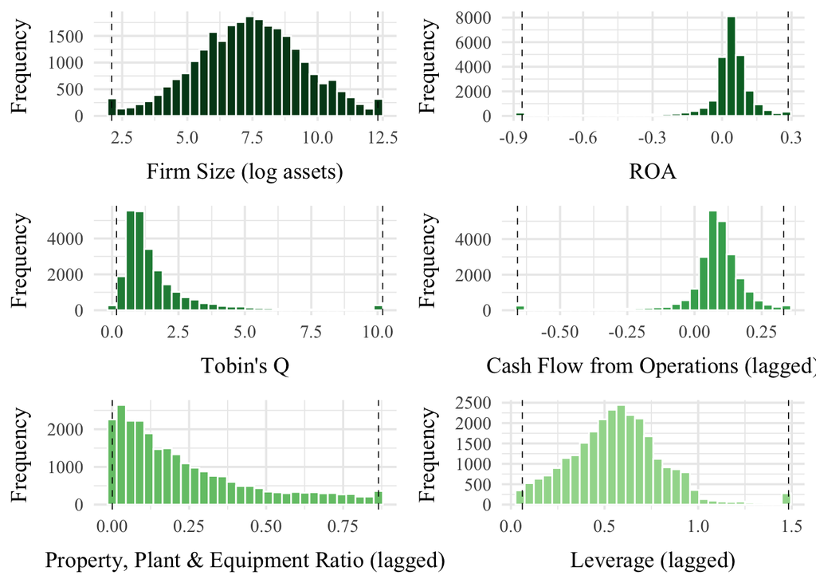

```r
# Define 6 distinct shades of green
green_shades <- c("#00441B", "#006D2C", "#238B45", "#41AB5D", "#74C476", "#A1D99B")

# Common theme for thesis
thesis_theme <- theme_minimal(base_size = 14) +
  theme(
    text = element_text(family = "Times New Roman"),
    axis.title.x = element_text(margin = margin(t = 10)),
    axis.title.y = element_text(margin = margin(r = 10)),
    plot.title = element_blank()
  )

# Helper function to make histograms with cutoff lines & custom axis label
plot_hist_with_cutoffs <- function(data, var, fill_color, x_label) {
  lower_cut <- quantile(data[[var]], 0.01, na.rm = TRUE)
  upper_cut <- quantile(data[[var]], 0.99, na.rm = TRUE)

  ggplot(data, aes_string(x = var)) +
    geom_histogram(bins = 30, fill = fill_color, color = "white") +
    geom_vline(xintercept = lower_cut, linetype = "dashed", color = "black", linewidth = 0.3) +
    geom_vline(xintercept = upper_cut, linetype = "dashed", color = "black", linewidth = 0.3) +
    labs(x = x_label, y = "Frequency") +
    thesis_theme
}

# Create histograms with better axis titles
p1 <- plot_hist_with_cutoffs(final_sample_df, "size", green_shades[1], "Firm Size (log assets)")
p2 <- plot_hist_with_cutoffs(final_sample_df, "roa", green_shades[2], "ROA")
p3 <- plot_hist_with_cutoffs(final_sample_df, "tobins_q", green_shades[3], "Tobin's Q")
p4 <- plot_hist_with_cutoffs(final_sample_df, "cfo_lag", green_shades[4], "Cash Flow from Operations (lagged)")
p5 <- plot_hist_with_cutoffs(final_sample_df, "ppe_lag", green_shades[5], "Property, Plant & Equipment Ratio (lagged)")
p6 <- plot_hist_with_cutoffs(final_sample_df, "leverage_lag", green_shades[6], "Leverage (lagged)")

# Arrange plots
library(gridExtra)
hist_grid <- grid.arrange(p1, p2, p3, p4, p5, p6, ncol = 2)
```

```r
# Save as PNG
ggsave(
  filename = paste0(dirRslt, "histograms_winsorized.png"),
  plot = hist_grid,
  width = 12,
  height = 6,
  dpi = 600
)
```

##### 1.5.7 Creating treatment & period dummies

```r
DiD_df <- final_sample_df %>%
  mutate(
    dPost = if_else(fyear >= 2015, 1, 0),
    dDirective = if_else(fyear == 2014, 1, 0),
    dTreat = if_else(fic == "USA", 0, 1) # EU firm under the NFRD
  )

skim(DiD_df)
```

Data summary

| Name | DiD_df |
| --- | --- |
| Number of rows | 26604 |
| Number of columns | 38 |
| _______________________ |  |
| Column type frequency: |  |
| character | 3 |
| factor | 3 |
| numeric | 32 |
| ________________________ |  |
| Group variables | None |

**Variable type: character**

| skim_variable | n_missing | complete_rate | min | max | empty | n_unique | whitespace |
| --- | --- | --- | --- | --- | --- | --- | --- |
| conm | 0 | 1 | 4 | 28 | 0 | 2217 | 0 |
| gvkey | 0 | 1 | 4 | 6 | 0 | 2217 | 0 |
| curcd | 0 | 1 | 3 | 3 | 0 | 9 | 0 |

**Variable type: factor**

| skim_variable | n_missing | complete_rate | ordered | n_unique | top_counts |
| --- | --- | --- | --- | --- | --- |
| fic | 0 | 1 | FALSE | 22 | USA: 15876, DEU: 2304, SWE: 2004, FRA: 1464 |
| gind | 0 | 1 | FALSE | 72 | 201: 1560, 101: 948, 352: 876, 351: 864 |
| gsector | 0 | 1 | FALSE | 11 | 20: 6396, 25: 3660, 45: 3432, 35: 3276 |

**Variable type: numeric**

| skim_variable | n_missing | complete_rate | mean | sd | p0 | p25 | p50 | p75 | p100 | hist |
| --- | --- | --- | --- | --- | --- | --- | --- | --- | --- | --- |
| fyear | 0 | 1.00 | 2014.51 | 3.45 | 2009.00 | 2012.00 | 2015.00 | 2018.00 | 2020.00 | ▇▅▅▆▇ |
| community | 11180 | 0.58 | 57.77 | 27.06 | 0.00 | 37.31 | 60.34 | 81.15 | 99.90 | ▃▅▇▇▇ |
| csr_strategy | 11179 | 0.58 | 32.97 | 33.32 | 0.00 | 0.00 | 24.42 | 62.82 | 99.97 | ▇▂▂▂▂ |
| emissions | 11180 | 0.58 | 40.11 | 34.00 | 0.00 | 1.25 | 37.88 | 71.15 | 99.89 | ▇▃▃▃▃ |
| environment_pillar | 11180 | 0.58 | 38.38 | 29.68 | 0.00 | 9.07 | 36.78 | 64.17 | 98.94 | ▇▅▅▅▂ |
| environmental_innovation | 11180 | 0.58 | 26.84 | 31.58 | 0.00 | 0.00 | 10.98 | 50.00 | 99.73 | ▇▂▂▂▂ |
| esg_combined | 11179 | 0.58 | 44.27 | 19.41 | 0.44 | 29.20 | 43.20 | 58.98 | 93.16 | ▂▇▇▆▂ |
| esg_controversies | 11180 | 0.58 | 90.33 | 23.32 | 0.83 | 100.00 | 100.00 | 100.00 | 100.00 | ▁▁▁▁▇ |
| esg_overall | 11179 | 0.58 | 46.02 | 20.57 | 0.44 | 29.58 | 44.96 | 62.54 | 95.16 | ▃▇▇▆▂ |
| governance_pillar | 11179 | 0.58 | 50.35 | 22.24 | 0.14 | 32.80 | 51.12 | 68.22 | 99.38 | ▃▆▇▇▃ |
| human_rights | 11180 | 0.58 | 32.66 | 34.42 | 0.00 | 0.00 | 21.43 | 64.14 | 99.43 | ▇▂▂▂▂ |
| management | 11179 | 0.58 | 53.23 | 28.33 | 0.05 | 29.33 | 54.71 | 77.64 | 99.98 | ▆▆▇▇▇ |
| product_responsibility | 11180 | 0.58 | 46.67 | 30.29 | 0.00 | 21.21 | 43.01 | 74.35 | 99.83 | ▇▇▅▆▆ |
| resource_use | 11180 | 0.58 | 41.55 | 34.81 | 0.00 | 1.39 | 40.13 | 74.00 | 99.88 | ▇▃▃▃▅ |
| shareholders | 11179 | 0.58 | 52.34 | 28.46 | 0.02 | 28.44 | 53.23 | 76.93 | 99.98 | ▆▇▇▇▇ |
| social_pillar | 11180 | 0.58 | 47.84 | 23.46 | 0.12 | 28.82 | 46.06 | 66.68 | 98.19 | ▃▇▇▆▃ |
| workforce | 11180 | 0.58 | 52.44 | 29.04 | 0.13 | 27.24 | 52.50 | 78.57 | 99.90 | ▆▇▆▇▇ |
| interest_rate | 0 | 1.00 | 1.54 | 1.08 | -4.17 | 0.74 | 1.48 | 2.31 | 12.67 | ▁▇▁▁▁ |
| rule_of_law | 0 | 1.00 | 1.52 | 0.33 | 0.05 | 1.45 | 1.59 | 1.62 | 2.12 | ▁▁▁▇▂ |
| size | 36 | 1.00 | 7.39 | 2.08 | 2.10 | 6.00 | 7.43 | 8.78 | 12.31 | ▁▅▇▆▂ |
| roa | 644 | 0.98 | 0.02 | 0.15 | -0.86 | 0.01 | 0.04 | 0.08 | 0.29 | ▁▁▁▇▅ |
| tobins_q | 1360 | 0.95 | 1.69 | 1.63 | 0.17 | 0.79 | 1.16 | 1.91 | 10.19 | ▇▂▁▁▁ |
| cfo_lag | 2115 | 0.92 | 0.07 | 0.13 | -0.66 | 0.05 | 0.09 | 0.13 | 0.33 | ▁▁▁▇▃ |
| ppe_lag | 695 | 0.97 | 0.24 | 0.22 | 0.00 | 0.06 | 0.17 | 0.35 | 0.86 | ▇▃▂▁▁ |
| leverage_lag | 74 | 1.00 | 0.57 | 0.25 | 0.06 | 0.41 | 0.57 | 0.71 | 1.48 | ▃▇▆▁▁ |
| inflation_lag | 0 | 1.00 | 1.48 | 0.70 | -4.62 | 0.95 | 1.65 | 1.86 | 8.91 | ▁▁▇▁▁ |
| gdp_growth_lag | 0 | 1.00 | 1.25 | 2.48 | -10.94 | 0.89 | 2.12 | 2.58 | 24.62 | ▁▇▁▁▁ |
| interest_rate_lag | 0 | 1.00 | 1.54 | 1.08 | -4.17 | 0.74 | 1.48 | 2.31 | 12.67 | ▁▇▁▁▁ |
| unemployment_rate_lag | 0 | 1.00 | 7.28 | 3.21 | 2.02 | 4.87 | 7.38 | 8.95 | 27.69 | ▇▇▁▁▁ |
| dPost | 0 | 1.00 | 0.50 | 0.50 | 0.00 | 0.00 | 1.00 | 1.00 | 1.00 | ▇▁▁▁▇ |
| dDirective | 0 | 1.00 | 0.08 | 0.28 | 0.00 | 0.00 | 0.00 | 0.00 | 1.00 | ▇▁▁▁▁ |
| dTreat | 0 | 1.00 | 0.40 | 0.49 | 0.00 | 0.00 | 0.00 | 1.00 | 1.00 | ▇▁▁▁▆ |

```r
DiD_df %>%
  summarise(unique_gvkeys = n_distinct(gvkey))
```

```
## # A tibble: 1 × 1
##   unique_gvkeys
##           <int>
## 1          2217
```

```r
write.csv(DiD_df, file = paste0(dirData, "DiD_df.csv"), row.names = FALSE)
```

### 2. Machine Learning Algorithms for Feature Importance

#### 2.1 Feature Engineering & Recipe Definition

##### 2.1.1 Set-up for analysis

```r
# Seed setting for reproducibility
set.seed(2025)

DiD_df <- read.csv("/Users/mihail/Desktop/Master BAM/Thesis/Data/DiD_df.csv")

# Ensure all firm-level (gvkey) observations are in only one set
split <- group_initial_split(DiD_df, prop = 0.75, group = gvkey)

# Data Split
train_set <- training(split)
test_set <- testing(split)

# Grouped k-fold CV at the firm (gvkey) level
folds <- group_vfold_cv(train_set, v = 5, group = gvkey)
```

##### 2.1.2 Exploratory Data Analysis

```r
# Explore training set
train_set |> skim()
```

Data summary

| Name | train_set |
| --- | --- |
| Number of rows | 19956 |
| Number of columns | 38 |
| _______________________ |  |
| Column type frequency: |  |
| character | 3 |
| numeric | 35 |
| ________________________ |  |
| Group variables | None |

**Variable type: character**

| skim_variable | n_missing | complete_rate | min | max | empty | n_unique | whitespace |
| --- | --- | --- | --- | --- | --- | --- | --- |
| fic | 0 | 1 | 3 | 3 | 0 | 22 | 0 |
| conm | 0 | 1 | 4 | 28 | 0 | 1663 | 0 |
| curcd | 0 | 1 | 3 | 3 | 0 | 9 | 0 |

**Variable type: numeric**

| skim_variable | n_missing | complete_rate | mean | sd | p0 | p25 | p50 | p75 | p100 | hist |
| --- | --- | --- | --- | --- | --- | --- | --- | --- | --- | --- |
| gvkey | 0 | 1.00 | 120817.84 | 102871.67 | 1004.00 | 14113.00 | 102840.00 | 216096.00 | 331330.00 | ▇▂▂▃▂ |
| gind | 0 | 1.00 | 313398.00 | 130736.79 | 101010.00 | 201060.00 | 301010.00 | 403010.00 | 602010.00 | ▇▇▆▆▃ |
| gsector | 0 | 1.00 | 31.17 | 13.07 | 10.00 | 20.00 | 30.00 | 40.00 | 60.00 | ▇▅▅▃▂ |
| fyear | 0 | 1.00 | 2014.51 | 3.45 | 2009.00 | 2012.00 | 2015.00 | 2018.00 | 2020.00 | ▇▅▅▆▇ |
| community | 8384 | 0.58 | 58.06 | 26.98 | 0.00 | 37.50 | 60.64 | 81.44 | 99.90 | ▃▅▆▇▇ |
| csr_strategy | 8384 | 0.58 | 32.84 | 33.08 | 0.00 | 0.00 | 25.00 | 62.38 | 99.97 | ▇▂▂▂▂ |
| emissions | 8384 | 0.58 | 40.15 | 34.04 | 0.00 | 0.44 | 38.06 | 70.95 | 99.89 | ▇▃▃▃▃ |
| environment_pillar | 8384 | 0.58 | 38.21 | 29.61 | 0.00 | 9.03 | 36.64 | 63.89 | 98.94 | ▇▅▅▅▂ |
| environmental_innovation | 8384 | 0.58 | 26.46 | 31.28 | 0.00 | 0.00 | 10.47 | 50.00 | 99.73 | ▇▂▂▂▂ |
| esg_combined | 8384 | 0.58 | 44.18 | 19.29 | 0.44 | 29.23 | 43.22 | 58.83 | 93.05 | ▂▇▇▆▂ |
| esg_controversies | 8384 | 0.58 | 90.10 | 23.59 | 0.83 | 100.00 | 100.00 | 100.00 | 100.00 | ▁▁▁▁▇ |
| esg_overall | 8384 | 0.58 | 45.95 | 20.42 | 0.44 | 29.67 | 45.08 | 62.34 | 95.16 | ▃▇▇▆▂ |
| governance_pillar | 8384 | 0.58 | 50.33 | 22.14 | 0.14 | 33.12 | 51.11 | 67.91 | 99.38 | ▃▆▇▇▃ |
| human_rights | 8384 | 0.58 | 32.44 | 34.22 | 0.00 | 0.00 | 21.43 | 63.24 | 99.43 | ▇▂▂▂▂ |
| management | 8384 | 0.58 | 53.39 | 28.24 | 0.05 | 29.63 | 55.02 | 77.62 | 99.98 | ▆▆▇▇▇ |
| product_responsibility | 8384 | 0.58 | 46.23 | 30.28 | 0.00 | 20.87 | 41.76 | 74.09 | 99.83 | ▇▇▅▅▆ |
| resource_use | 8384 | 0.58 | 41.34 | 34.78 | 0.00 | 1.53 | 39.41 | 73.94 | 99.88 | ▇▃▃▃▅ |
| shareholders | 8384 | 0.58 | 51.84 | 28.64 | 0.02 | 27.63 | 52.36 | 76.79 | 99.98 | ▇▇▇▇▇ |
| social_pillar | 8384 | 0.58 | 47.72 | 23.43 | 0.12 | 28.78 | 46.06 | 66.61 | 98.14 | ▃▇▇▆▃ |
| workforce | 8384 | 0.58 | 52.22 | 28.88 | 0.18 | 27.25 | 52.38 | 78.05 | 99.90 | ▆▇▇▇▇ |
| interest_rate | 0 | 1.00 | 1.55 | 1.08 | -4.17 | 0.75 | 1.48 | 2.31 | 12.67 | ▁▇▁▁▁ |
| rule_of_law | 0 | 1.00 | 1.52 | 0.34 | 0.05 | 1.45 | 1.59 | 1.62 | 2.12 | ▁▁▁▇▂ |
| size | 32 | 1.00 | 7.38 | 2.08 | 2.10 | 5.97 | 7.44 | 8.78 | 12.31 | ▂▅▇▆▂ |
| roa | 441 | 0.98 | 0.02 | 0.15 | -0.86 | 0.01 | 0.04 | 0.08 | 0.29 | ▁▁▁▇▆ |
| tobins_q | 980 | 0.95 | 1.71 | 1.64 | 0.17 | 0.80 | 1.18 | 1.93 | 10.19 | ▇▂▁▁▁ |
| cfo_lag | 1602 | 0.92 | 0.07 | 0.13 | -0.66 | 0.05 | 0.09 | 0.13 | 0.33 | ▁▁▁▇▃ |
| ppe_lag | 561 | 0.97 | 0.24 | 0.22 | 0.00 | 0.06 | 0.17 | 0.35 | 0.86 | ▇▃▂▁▁ |
| leverage_lag | 64 | 1.00 | 0.56 | 0.25 | 0.06 | 0.40 | 0.56 | 0.70 | 1.48 | ▃▇▆▁▁ |
| inflation_lag | 0 | 1.00 | 1.48 | 0.70 | -4.62 | 0.95 | 1.65 | 1.86 | 8.91 | ▁▁▇▁▁ |
| gdp_growth_lag | 0 | 1.00 | 1.25 | 2.48 | -10.94 | 0.89 | 2.12 | 2.58 | 24.62 | ▁▇▁▁▁ |
| interest_rate_lag | 0 | 1.00 | 1.55 | 1.08 | -4.17 | 0.75 | 1.48 | 2.31 | 12.67 | ▁▇▁▁▁ |
| unemployment_rate_lag | 0 | 1.00 | 7.24 | 3.11 | 2.02 | 4.87 | 7.38 | 8.95 | 27.69 | ▇▇▁▁▁ |
| dPost | 0 | 1.00 | 0.50 | 0.50 | 0.00 | 0.00 | 1.00 | 1.00 | 1.00 | ▇▁▁▁▇ |
| dDirective | 0 | 1.00 | 0.08 | 0.28 | 0.00 | 0.00 | 0.00 | 0.00 | 1.00 | ▇▁▁▁▁ |
| dTreat | 0 | 1.00 | 0.40 | 0.49 | 0.00 | 0.00 | 0.00 | 1.00 | 1.00 | ▇▁▁▁▆ |

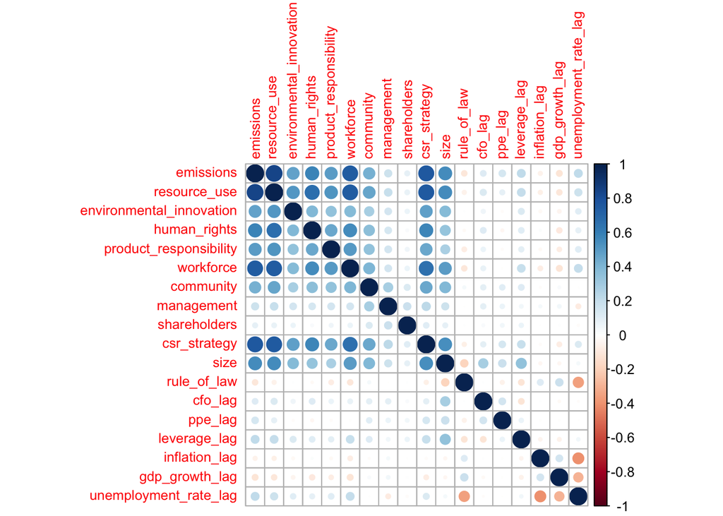

```r
vars_to_corr <- c(
  "emissions", "resource_use", "environmental_innovation", "human_rights", "product_responsibility", "workforce", "community", "management", "shareholders", "csr_strategy", "size", "rule_of_law", "cfo_lag", "ppe_lag", "leverage_lag", "inflation_lag", "gdp_growth_lag", "unemployment_rate_lag"
)

# Check correlations
train_set %>%
  select(all_of(vars_to_corr)) %>%
  cor(use = "pairwise.complete.obs") %>%
  corrplot::corrplot(method = "circle", tl.cex = 0.8)
```

##### 2.1.3 Recipe for Random Forest

```r
# Random Forest Recipe
reg_recipe_rf <- recipe(
  tobins_q ~ emissions + resource_use + environmental_innovation + human_rights + product_responsibility + workforce + community + management + shareholders + csr_strategy + size + rule_of_law + cfo_lag + ppe_lag + leverage_lag + inflation_lag + gdp_growth_lag + unemployment_rate_lag,
  data = train_set
) %>%
  step_naomit(all_predictors(), all_outcomes()) %>%
  step_dummy(all_nominal_predictors()) %>%
  step_zv(all_predictors())
```

#### 2.2 Model Training

##### 2.2.1 Model specifications

```r
# Define the RF model with tuning grid
rf_model_spec <-
  rand_forest(mtry = tune(), trees = 100, min_n = tune()) |>
  set_mode("regression") |>
  set_engine("ranger", importance = "permutation")
```

##### 2.2.2 Workflows set-up

```r
# Random Forest
rf_tune_wf <-
  workflow() |>
  add_recipe(reg_recipe_rf) |>
  add_model(rf_model_spec)

rf_tune_wf
```

```
## ══ Workflow ════════════════════════════════════════════════════════════════════
## Preprocessor: Recipe
## Model: rand_forest()
##
## ── Preprocessor ────────────────────────────────────────────────────────────────
## 3 Recipe Steps
##
## • step_naomit()
## • step_dummy()
## • step_zv()
##
## ── Model ───────────────────────────────────────────────────────────────────────
## Random Forest Model Specification (regression)
##
## Main Arguments:
##   mtry = tune()
##   trees = 100
##   min_n = tune()
##
## Engine-Specific Arguments:
##   importance = permutation
##
## Computational engine: ranger
```

#### 2.3 Hyperparameter Tuning

##### 2.3.1 Tuning grid and metrics

There are 18 features in the recipe, so the value of mtry will be tuned on values from 1 to 18.

```r
# Random Forest Grid
grid_rf <-
  grid_regular(
    mtry(range = c(1, 18)),
    min_n(range = c(5, 20)),
    levels = 18
  )

foreach::getDoParWorkers()
```

```
## [1] 1
```

##### 2.3.2 Tuning the hyperparameter

```r
reg_metrics <- metric_set(rmse, rsq, mae)

# Use parallel processing to speed up computation:
num_cores <- parallel::detectCores()
num_cores
```

```
## [1] 10
```

```r
doParallel::registerDoParallel(cores = num_cores - 1L)

# RF Tuning
rf_tune <- tune_grid(
  rf_tune_wf,
  resamples = folds,
  grid = grid_rf,
  metrics = reg_metrics,
  control = control_grid(verbose = TRUE, save_pred = TRUE)
)
```

##### 2.3.3 Plot the tuning results

```r
# Random Forest Metrics Plot with consistent style and more space between facets
rf_tune_metrics <- rf_tune |> collect_metrics()

rf_tune_plot <- autoplot(rf_tune) +
  theme_minimal(base_size = 14) +
  theme(
    text = element_text(family = "Times New Roman"),
    axis.text = element_text(family = "Times New Roman"),
    axis.title.x = element_text(margin = margin(t = 10)),
    axis.title.y = element_text(margin = margin(r = 10)),
    legend.position = "right",
    panel.spacing = unit(0.7, "cm") # Increase white space between facet panels
  )

# Save plot
ggsave(
  filename = paste0(dirRslt, "rf_tune_metrics.png"),
  plot = rf_tune_plot, width = 12, height = 6, dpi = 600
)
```

##### 2.3.2 Best model selection

```r
rf_tune %>% select_best(metric = "rmse")
```

```
## # A tibble: 1 × 3
##    mtry min_n .config
##   <int> <int> <chr>
## 1     4     5 Preprocessor1_Model004
```

```r
best_rf <- rf_tune |>
  select_best(metric = "rmse")

best_rf
```

```
## # A tibble: 1 × 3
##    mtry min_n .config
##   <int> <int> <chr>
## 1     4     5 Preprocessor1_Model004
```

```r
# Finalize workflow with best RF model
rf_final_wf <- finalize_workflow(rf_tune_wf, best_rf)

rf_final_wf
```

```
## ══ Workflow ════════════════════════════════════════════════════════════════════
## Preprocessor: Recipe
## Model: rand_forest()
##
## ── Preprocessor ────────────────────────────────────────────────────────────────
## 3 Recipe Steps
##
## • step_naomit()
## • step_dummy()
## • step_zv()
##
## ── Model ───────────────────────────────────────────────────────────────────────
## Random Forest Model Specification (regression)
##
## Main Arguments:
##   mtry = 4
##   trees = 100
##   min_n = 5
##
## Engine-Specific Arguments:
##   importance = permutation
##
## Computational engine: ranger
```

#### 2.4 Evaluation & Feature Importance

##### 2.4.1 Final model performance

```r
rf_final_fit <- rf_final_wf |>
  last_fit(split, metrics = reg_metrics)

# Results on test set:
rf_final_results <- rf_final_fit |>
  collect_metrics()

rf_final_results
```

```
## # A tibble: 3 × 4
##   .metric .estimator .estimate .config
##   <chr>   <chr>          <dbl> <chr>
## 1 rmse    standard       1.46  Preprocessor1_Model1
## 2 rsq     standard       0.319 Preprocessor1_Model1
## 3 mae     standard       1.07  Preprocessor1_Model1
```

##### 2.4.2 Permutation Feature Importance

```r
# Define variable groups
top5_esg_components_vars <- c("resource_use", "emissions", "workforce", "community", "csr_strategy")
financial_vars <- c("cfo_lag", "ppe_lag", "leverage_lag", "size")
macroeconomic_vars <- c("rule_of_law", "gdp_growth_lag", "inflation_lag", "unemployment_rate_lag")
esg_components_vars <- c("product_responsibility", "management", "human_rights", "environmental_innovation", "shareholders")

# Extract and prepare variable importance data
vi_df <- rf_final_fit %>%
  extract_fit_parsnip() %>%
  pluck("fit") %>%
  vi()

# Categorize each variable
vi_df <- vi_df %>%
  mutate(
    group = case_when(
      Variable %in% top5_esg_components_vars ~ "Top 5 ESG",
      Variable %in% esg_components_vars ~ "Other ESG",
      Variable %in% financial_vars ~ "Financial",
      Variable %in% macroeconomic_vars ~ "Macroeconomic",
      TRUE ~ "Other"
    ),
    alpha = if_else(group == "Top 5 ESG", 1, 0.5),
    size = if_else(group == "Top 5 ESG", 0.5, 0.3)
  )

# Custom color palette
group_colors <- c(
  "Top 5 ESG" = "#006E01",
  "Other ESG" = "#009E39",
  "Financial" = "gray20",
  "Macroeconomic" = "gray80",
  "Other" = "gray50"
)

# Plot
vi_plot <- ggplot(vi_df, aes(x = reorder(Variable, Importance), y = Importance)) +
  geom_col(aes(fill = group, alpha = alpha, linewidth = size), color = "black") +
  geom_text(
    data = filter(vi_df, group == "Top 5 ESG"),
    aes(label = round(Importance, 2)),
    hjust = -0.1,
    size = 3
  ) +
  scale_fill_manual(values = group_colors) +
  scale_alpha_identity() +
  scale_linewidth_identity() +
  coord_flip() +
  labs(
    x = "Variable",
    y = "Importance",
    fill = "Variable Group"
  ) +
  theme_minimal(base_size = 14) +
  theme(
    text = element_text(family = "Times New Roman"),
    axis.text = element_text(family = "Times New Roman"),
    axis.title = element_text(family = "Times New Roman"),
    axis.title.x = element_text(margin = margin(t = 10)),
    axis.title.y = element_text(margin = margin(r = 10)),
    legend.position = "bottom"
  )

# Save plot
ggsave(
  filename = paste0(dirRslt, "rf_variable_importance.png"),
  plot = vi_plot, width = 8, height = 6, dpi = 600
)
```

##### 2.4.3 Mean Decrease in Impurity

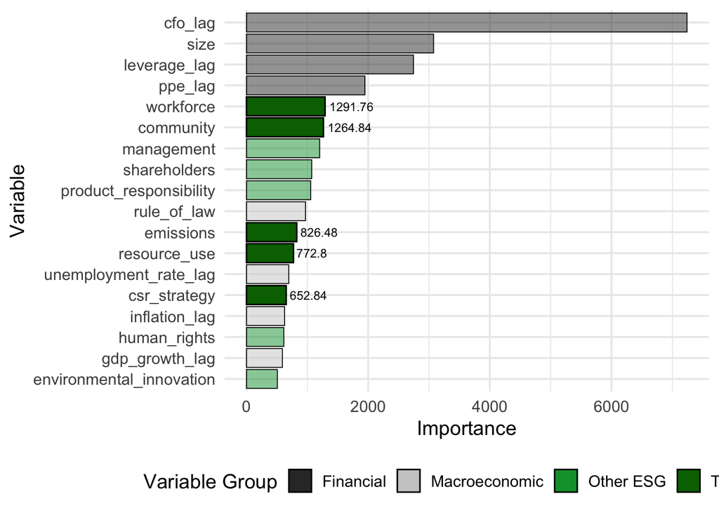

```r
# To check MDI:
rf_model_mdi <-
  rand_forest(mtry = best_rf$mtry, trees = 50, min_n = best_rf$min_n) %>%
  set_mode("regression") %>%
  set_engine("ranger", importance = "impurity")

# Finalize the workflow
rf_final_wf_mdi <- rf_tune_wf %>%
  update_model(rf_model_mdi)

# Fit on the training data
rf_fit_mdi <- rf_final_wf_mdi %>%
  fit(data = train_set)

# Extract fit object
mdi_vi_df <- rf_fit_mdi %>%
  extract_fit_parsnip() %>%
  pluck("fit") %>%
  vi()

# Optional: Order by importance
mdi_vi_df <- mdi_vi_df %>%
  arrange(desc(Importance))

# Categorize each variable
mdi_vi_df <- mdi_vi_df %>%
  mutate(
    group = case_when(
      Variable %in% top5_esg_components_vars ~ "Top 5 ESG",
      Variable %in% esg_components_vars ~ "Other ESG",
      Variable %in% financial_vars ~ "Financial",
      Variable %in% macroeconomic_vars ~ "Macroeconomic",
    ),
    alpha = if_else(group == "Top 5 ESG", 1, 0.5),
    size = if_else(group == "Top 5 ESG", 0.5, 0.3)
  )

# Custom color palette
group_colors <- c(
  "Top 5 ESG" = "#006E01",
  "Other ESG" = "#009E39",
  "Financial" = "gray20",
  "Macroeconomic" = "gray80"
)

# Plot
ggplot(mdi_vi_df, aes(x = reorder(Variable, Importance), y = Importance)) +
  geom_col(aes(fill = group, alpha = alpha, linewidth = size), color = "black") +
  geom_text(
    data = filter(mdi_vi_df, group == "Top 5 ESG"),
    aes(label = round(Importance, 2)),
    hjust = -0.1,
    size = 3,
  ) +
  scale_fill_manual(values = group_colors) +
  scale_alpha_identity() +
  scale_linewidth_identity() +
  coord_flip() +
  labs(
    x = "Variable",
    y = "Importance",
    fill = "Variable Group"
  ) +
  theme_minimal(base_size = 14) +
  theme(legend.position = "bottom")
```

### 3. Propensity Score Matching (PSM)

#### 3.1 Preparing Firm-level Data for PSM

##### 3.1.1 Dropping incomplete data firms

```r
esg_new_vars <- c("esg_overall", "governance_pillar", "environment_pillar", "social_pillar")

# Drop firms with missing values
drop_gvkeys <- DiD_df %>%
  group_by(gvkey) %>%
  summarise(any_na = any(rowSums(is.na(across(all_of(esg_new_vars)))) > 0)) %>%
  filter(any_na) %>%
  pull(gvkey)

DiD_df <- DiD_df %>%
  filter(!gvkey %in% drop_gvkeys)

DiD_df %>%
  summarise(unique_gvkeys = n_distinct(gvkey))
```

```
##   unique_gvkeys
## 1           780
```

##### 3.1.2 Dropping duplicates and sanity check for 12 firm-years observations

```r
# Remove duplicate firm-year rows
DiD_df_cleaned <- DiD_df %>%
  distinct(gvkey, fyear, .keep_all = TRUE)

# Check number of years per gvkey
firm_counts <- DiD_df_cleaned %>%
  filter(fyear >= 2009, fyear <= 2020) %>%
  group_by(gvkey) %>%
  summarise(n_years = n(), .groups = "drop")

# Identify gvkeys with less than 12 years
incomplete_firms <- firm_counts %>%
  filter(n_years < 12)

print(incomplete_firms)
```

```
## # A tibble: 1 × 2
##    gvkey n_years
##    <int>   <int>
## 1 201260      11
```

```r
# Drop those firms from the dataset
DiD_df <- DiD_df_cleaned %>%
  filter(!(gvkey %in% incomplete_firms$gvkey))

# Optional: confirm result
table(table(DiD_df$gvkey))
```

```
##
##  12
## 779
```

##### 3.1.3 Convert size to USD

```r
# Adjust size if currency is not already in USD and log-transform
DiD_df <- DiD_df %>%
  left_join(exchange_rates_df, by = c("curcd", "fyear")) %>%
  mutate(
    size = case_when(
      curcd != "USD" ~ log(size / rate),
      TRUE ~ log(size) # If already in USD, just log it
    )
  ) %>%
  select(-rate)
```

##### 3.1.4 Aggregating firm-level covariates (pre-2015)

```r
# Build firm-level dataset for PSM
firm_level_df <- DiD_df %>%
  filter(fyear < 2015) %>%
  group_by(gvkey) %>%
  summarise(
    dTreat = first(dTreat),
    size = mean(size, na.rm = TRUE),
    leverage_lag = mean(leverage_lag, na.rm = TRUE),
    cfo_lag = mean(cfo_lag, na.rm = TRUE),
    ppe_lag = mean(ppe_lag, na.rm = TRUE),
  )

# Drop firms with NA in covariates
firm_level_df <- firm_level_df %>%
  drop_na()

skim(firm_level_df)
```

Data summary

| Name | firm_level_df |
| --- | --- |
| Number of rows | 714 |
| Number of columns | 6 |
| _______________________ |  |
| Column type frequency: |  |
| numeric | 6 |
| ________________________ |  |
| Group variables | None |

**Variable type: numeric**

| skim_variable | n_missing | complete_rate | mean | sd | p0 | p25 | p50 | p75 | p100 | hist |
| --- | --- | --- | --- | --- | --- | --- | --- | --- | --- | --- |
| gvkey | 0 | 1 | 80885.03 | 87707.20 | 1045.00 | 7910.00 | 29141.50 | 139434.50 | 294508.00 | ▇▃▂▂▁ |
| dTreat | 0 | 1 | 0.31 | 0.46 | 0.00 | 0.00 | 0.00 | 1.00 | 1.00 | ▇▁▁▁▃ |
| size | 0 | 1 | 2.15 | 0.51 | -3.10 | 2.10 | 2.21 | 2.37 | 2.77 | ▁▁▁▁▇ |
| leverage_lag | 0 | 1 | 0.59 | 0.19 | 0.06 | 0.47 | 0.60 | 0.71 | 1.48 | ▂▇▆▁▁ |
| cfo_lag | 0 | 1 | 0.11 | 0.06 | -0.52 | 0.07 | 0.10 | 0.14 | 0.33 | ▁▁▁▇▂ |
| ppe_lag | 0 | 1 | 0.29 | 0.23 | 0.00 | 0.10 | 0.22 | 0.43 | 0.86 | ▇▅▃▂▂ |

#### 3.2 Running PSM

##### 3.2.1 Defining PSM models & calipers

```r
# Define PSM variables
psm_vars_core <- c("size", "ppe_lag", "cfo_lag", "leverage_lag")

# Run matching
final_m.out <- MatchIt::matchit(
  cobalt::f.build("dTreat", firm_level_df[, psm_vars_core]),
  data = firm_level_df,
  method = "optimal",
  replace = FALSE,
  caliper = 0.01,
)

# Summary of matching
summary(final_m.out)
```

```
##
## Call:
## MatchIt::matchit(formula = cobalt::f.build("dTreat", firm_level_df[,
##     psm_vars_core]), data = firm_level_df, method = "optimal",
##     replace = FALSE, caliper = 0.01)
##
## Summary of Balance for All Data:
##              Means Treated Means Control Std. Mean Diff. Var. Ratio eCDF Mean
## distance            0.3302        0.3002          0.3279     1.7938    0.0915
## size                2.0849        2.1799         -0.1077    36.1350    0.2858
## ppe_lag             0.2794        0.2975         -0.0889     0.7428    0.0287
## cfo_lag             0.0937        0.1112         -0.2936     0.8317    0.1364
## leverage_lag        0.6067        0.5833          0.1408     0.7143    0.0496
##              eCDF Max
## distance       0.1337
## size           0.5357
## ppe_lag        0.0864
## cfo_lag        0.2394
## leverage_lag   0.1214
##
## Summary of Balance for Matched Data:
##              Means Treated Means Control Std. Mean Diff. Var. Ratio eCDF Mean
## distance            0.3302        0.3216          0.0949     1.2741    0.0068
## size                2.0849        2.1697         -0.0961    34.3570    0.3018
## ppe_lag             0.2794        0.2690          0.0509     0.8180    0.0437
## cfo_lag             0.0937        0.0942         -0.0080     0.6369    0.0691
## leverage_lag        0.6067        0.6093         -0.0159     0.7033    0.0382
##              eCDF Max Std. Pair Dist.
## distance       0.0814          0.1249
## size           0.5656          0.6297
## ppe_lag        0.1131          1.0793
## cfo_lag        0.1584          0.7252
## leverage_lag   0.0769          1.0561
##
## Sample Sizes:
##           Control Treated
## All           493     221
## Matched       221     221
## Unmatched     272       0
## Discarded       0       0
```

##### 3.2.2 PSM Balance Table

```r
# Create matched data
matched_df <- match.data(final_m.out)

# Initialize balance results list
psm_balance_tbl <- purrr::map_dfr(psm_vars_core, function(var) {
  # Means before matching
  treat_mean_unmatched <- mean(firm_level_df[[var]][firm_level_df$dTreat == 1], na.rm = TRUE)
  control_mean_unmatched <- mean(firm_level_df[[var]][firm_level_df$dTreat == 0], na.rm = TRUE)
  t_test_unmatched <- t.test(firm_level_df[[var]] ~ firm_level_df$dTreat)

  # Means after matching
  treat_mean_matched <- mean(matched_df[[var]][matched_df$dTreat == 1], na.rm = TRUE)
  control_mean_matched <- mean(matched_df[[var]][matched_df$dTreat == 0], na.rm = TRUE)
  t_test_matched <- t.test(matched_df[[var]] ~ matched_df$dTreat)

  # Combine into data frame
  tibble(
    Variable = var,
    Match_Status = c("Unmatched", "Matched"),
    Treated_Mean = c(treat_mean_unmatched, treat_mean_matched),
    Control_Mean = c(control_mean_unmatched, control_mean_matched),
    `T-C` = c(
      treat_mean_unmatched - control_mean_unmatched,
      treat_mean_matched - control_mean_matched
    ),
    `P-Value` = c(t_test_unmatched$p.value, t_test_matched$p.value)
  )
})

# Format and print nicely
psm_balance_tbl %>%
  mutate(
    Treated_Mean = round(Treated_Mean, 3),
    Control_Mean = round(Control_Mean, 3),
    `T-C` = round(`T-C`, 3),
    `P-Value` = formatC(`P-Value`, digits = 3, format = "f")
  ) %>%
  knitr::kable("latex", booktabs = TRUE, caption = "PSM Covariate Balance Table (Before and After Matching)") %>%
  kableExtra::kable_styling(latex_options = c("hold_position", "striped"))
```

##### 3.2.3 Extract matched panel

```r
# Extract matched gvkeys
final_matched_gvkeys <- match.data(final_m.out)$gvkey

# Build final matched panel
final_matched_panel_df <- DiD_df %>%
  filter(gvkey %in% final_matched_gvkeys, fyear >= 2009, fyear <= 2020) %>%
  distinct(gvkey, fyear, .keep_all = TRUE)

# Check number of firms
length(unique(final_matched_panel_df$gvkey))
```

```
## [1] 442
```

```r
# Prepare panel data
final_panel_df <- pdata.frame(final_matched_panel_df, index = c("gvkey", "fyear"))

is.pbalanced(final_panel_df)
```

```
## [1] TRUE
```

##### 3.2.4 Save matched panel and love plot

```r
# Save final matched panel
write.csv(final_matched_panel_df, paste0(dirData, "final_matched_panel_df.csv"), row.names = FALSE)

# Create love plot with consistent style (no title)
love_plot <- love.plot(
  final_m.out,
  stats = "mean.diffs",
  threshold = 0.1, # Vertical line for acceptable SMD
  abs = TRUE,
  line = TRUE,
  binary = "std", # Use standardized diff for binary vars too
  colors = c("black", "green4"), # Before / After colors
  shapes = c("triangle filled", "circle filled"),
  size = 3
) +
  scale_color_manual(values = c("black", "green4")) +
  labs(title = NULL) + # Removes title
  theme_minimal(base_size = 14) +
  theme(
    text = element_text(family = "Times New Roman"),
    axis.text = element_text(family = "Times New Roman"),
    axis.title.x = element_text(margin = margin(t = 10)),
    axis.title.y = element_text(margin = margin(r = 10)),
    legend.position = "bottom"
  )
# Save plot
ggsave(
  filename = paste0(dirRslt, "final_psm_love_plot.png"),
  plot = love_plot, width = 8, height = 6, dpi = 600
)
```

### 4. Difference-in-Difference Models

#### 4.1 Parallel Trends Assumption Testing

##### 4.1.1 ROA Parallel Trends

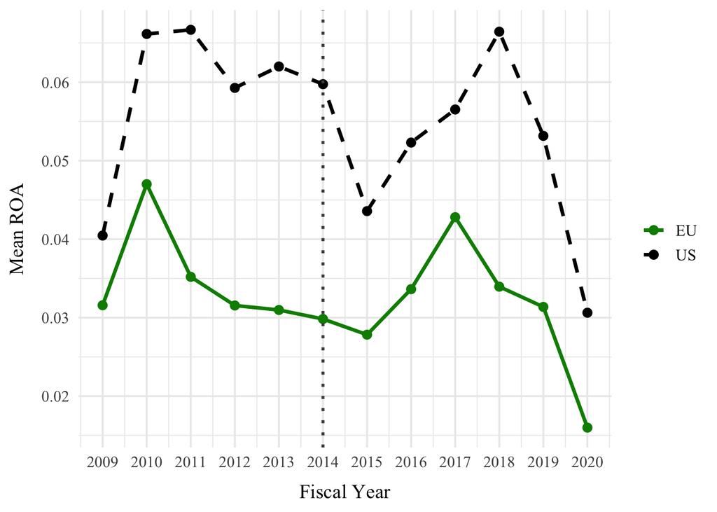

```r
# Prepare data → aggregate ROA per year per group
roa_plot_data <- DiD_df %>%
  filter(fyear >= 2009, fyear <= 2020) %>%
  group_by(fyear, dTreat) %>%
  summarise(mean_roa = mean(roa, na.rm = TRUE), .groups = "drop") %>%
  mutate(group = if_else(dTreat == 1, "EU", "US"))

# Plot ROA parallel trends
ggplot(roa_plot_data, aes(
  x = fyear, y = mean_roa,
  linetype = group, shape = group, color = group
)) +
  geom_line(size = 1.2) +
  geom_point(size = 3) +
  geom_vline(xintercept = 2014, linetype = "dotted", color = "gray30", linewidth = 1) +
  scale_x_continuous(breaks = 2009:2020) +
  scale_linetype_manual(values = c("solid", "dashed")) +
  scale_shape_manual(values = c(16, 16)) +
  scale_color_manual(values = c("EU" = "green4", "US" = "black")) +
  labs(
    x = "Fiscal Year",
    y = "Mean ROA",
    linetype = "",
    shape = "",
    color = ""
  ) +
  theme_minimal(base_size = 14) +
  theme(
    text = element_text(family = "Times New Roman"),
    axis.text = element_text(family = "Times New Roman"),
    axis.title = element_text(family = "Times New Roman"),
    axis.title.x = element_text(margin = margin(t = 10)),
    axis.title.y = element_text(margin = margin(r = 10))
  )
```

```r
# Save plot
ggsave(
  filename = paste0(dirRslt, "parallel_trends_roa.png"),
  plot = last_plot(), width = 8, height = 6, dpi = 600
)
```

##### 4.1.2 Tobin’s Q Parallel Trends

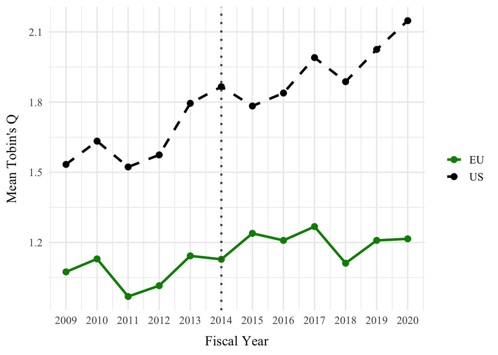

```r
# Prepare data → aggregate Tobin's Q per year per group
tobins_q_plot_data <- DiD_df %>%
  filter(fyear >= 2009, fyear <= 2020) %>%
  group_by(fyear, dTreat) %>%
  summarise(mean_tq = mean(tobins_q, na.rm = TRUE), .groups = "drop") %>%
  mutate(group = if_else(dTreat == 1, "EU", "US"))

# Plot Tobin's Q parallel trends
ggplot(tobins_q_plot_data, aes(
  x = fyear, y = mean_tq,
  linetype = group, shape = group, color = group
)) +
  geom_line(size = 1.2) +
  geom_point(size = 3) +
  geom_vline(xintercept = 2014, linetype = "dotted", color = "gray30", linewidth = 1) +
  scale_x_continuous(breaks = 2009:2020) +
  scale_linetype_manual(values = c("solid", "dashed")) +
  scale_shape_manual(values = c(16, 16)) +
  scale_color_manual(values = c("EU" = "green4", "US" = "black")) +
  labs(
    x = "Fiscal Year",
    y = "Mean Tobin's Q",
    linetype = "",
    shape = "",
    color = ""
  ) +
  theme_minimal(base_size = 14) +
  theme(
    text = element_text(family = "Times New Roman"),
    axis.text = element_text(family = "Times New Roman"),
    axis.title = element_text(family = "Times New Roman"),
    axis.title.x = element_text(margin = margin(t = 10)),
    axis.title.y = element_text(margin = margin(r = 10))
  )
```

```r
# Save plot
ggsave(
  filename = paste0(dirRslt, "parallel_trends_tobins_q.png"),
  plot = last_plot(), width = 8, height = 6, dpi = 600
)
```

#### 4.2 H1 ESG and CFP Association

```r
# Check balance
is.pbalanced(final_panel_df)
```

```
## [1] TRUE
```

```r
# H1 model formula
h1_model_tq <- tobins_q ~ esg_overall + size + rule_of_law + cfo_lag + ppe_lag + leverage_lag +
  inflation_lag + gdp_growth_lag + unemployment_rate_lag

# Model 1: Pooled OLS
h1_rslts_pool <- plm(h1_model_tq, data = final_panel_df, model = "pooling")

# Model 2: Fixed Effects (Within)
h1_rslts_fe <- plm(h1_model_tq, data = final_panel_df, model = "within")

# Model 3: Between Effects
h1_rslts_bw <- plm(h1_model_tq, data = final_panel_df, model = "between")

# Model 4: Random Effects
h1_rslts_re <- plm(h1_model_tq, data = final_panel_df, model = "random")

# Cluster-robust standard errors
se_pool <- coeftest(h1_rslts_pool, vcovHC(h1_rslts_pool, cluster = "group", type = "HC1"))
se_fe <- coeftest(h1_rslts_fe, vcovHC(h1_rslts_fe, cluster = "group", type = "HC1"))
se_re <- coeftest(h1_rslts_re, vcovHC(h1_rslts_re, cluster = "group", type = "HC1"))

# Stargazer table
stargazer(
  h1_rslts_pool, h1_rslts_fe, h1_rslts_bw, h1_rslts_re,
  se = list(
    se_pool[, "Std. Error"],
    se_fe[, "Std. Error"],
    NULL,
    se_re[, "Std. Error"]
  ),
  type = "text",
  title = "Panel Models: ESG → Tobin's Q (H1)",
  column.labels = c("Pooled OLS", "Fixed Effects", "Between", "Random Effects"),
  dep.var.labels = "Tobin's Q",
  omit.stat = c("f", "ser"),
  digits = 3,
  no.space = TRUE,
  star.cutoffs = c(0.1, 0.05, 0.01),
  notes = c("* p < 0.1; ** p < 0.05; *** p < 0.01")
)
```

```
##
## Panel Models: ESG → Tobin's Q (H1)
## =======================================================================
##                                      Dependent variable:
##                       -------------------------------------------------
##                                           Tobin's Q
##                       Pooled OLS Fixed Effects  Between  Random Effects
##                          (1)          (2)         (3)         (4)
## -----------------------------------------------------------------------
## esg_overall             -0.004     0.005***    -0.010***    0.004***
##                        (0.002)      (0.002)     (0.003)     (0.001)
## size                    -0.075     1.283***     -0.106       0.454*
##                        (0.089)      (0.409)     (0.091)     (0.261)
## rule_of_law             0.161      -1.010***    0.491**    -0.488***
##                        (0.153)      (0.186)     (0.196)     (0.133)
## cfo_lag                6.567***    3.810***    8.197***     4.108***
##                        (2.333)      (0.537)     (0.849)     (0.575)
## ppe_lag                -0.649**     -0.210     -0.627***    -0.372*
##                        (0.255)      (0.297)     (0.231)     (0.205)
## leverage_lag           -0.529*       0.006      -0.496*      -0.106
##                        (0.317)      (0.239)     (0.298)     (0.230)
## inflation_lag           -0.023      -0.029*     -0.258      -0.028*
##                        (0.035)      (0.015)     (0.285)     (0.016)
## gdp_growth_lag         0.021***    0.027***     0.105*      0.017***
##                        (0.006)      (0.006)     (0.058)     (0.005)
## unemployment_rate_lag   -0.017     -0.031***     0.021     -0.043***
##                        (0.012)      (0.007)     (0.030)     (0.007)
## Constant               1.682**                   1.339       1.220*
##                        (0.688)                  (0.813)     (0.656)
## -----------------------------------------------------------------------
## Observations            5,182        5,182        436        5,182
## R2                      0.178        0.142       0.265       0.108
## Adjusted R2             0.177        0.062       0.250       0.106
## =======================================================================
## Note:                                       *p<0.1; **p<0.05; ***p<0.01
##                                    * p < 0.1; ** p < 0.05; *** p < 0.01
```

```r
# F test: compare fixed effects and pooled models
ftest <- pooltest(h1_rslts_pool, h1_rslts_fe)
print(ftest)
```

```
##
##  F statistic
##
## data:  h1_model_tq
## F = 32.307, df1 = 435, df2 = 4737, p-value < 2.2e-16
## alternative hypothesis: unstability
```

```r
# Hausman Test: FE vs RE
hausman_test <- phtest(h1_rslts_fe, h1_rslts_re)
print(hausman_test)
```

```
##
##  Hausman Test
##
## data:  h1_model_tq
## chisq = 277.6, df = 9, p-value < 2.2e-16
## alternative hypothesis: one model is inconsistent
```

```r
# Create the results table
model_tests <- data.frame(
  Test = c("F-test", "Hausman test"),
  Comparison = c("Pooled OLS vs Fixed Effects", "Fixed Effects vs Random Effects"),
  Statistic = c(round(ftest$statistic, 3), round(hausman_test$statistic, 3)),
  df = c(
    paste0("(", ftest$parameter[1], ", ", ftest$parameter[2], ")"),
    as.character(hausman_test$parameter)
  ),
  p_value = c(
    format.pval(ftest$p.value, digits = 3, eps = .001),
    format.pval(hausman_test$p.value, digits = 3, eps = .001)
  )
)

# Print table using knitr::kable
kable(model_tests,
  format = "latex", # Use "markdown" for HTML/PDF flex output
  caption = "Model Specification Tests for Panel Data",
  align = c("l", "l", "r", "r", "r"),
  booktabs = TRUE
)
```

#### 4.3 H2 Model - ESG Dimensions as Dependent Variables

##### 4.3.1 Overall ESG Score and main pillars

```r
# Model 1: Environment Pillar as dependent variable
model_env <- environment_pillar ~ dPost + dTreat + dDirective + dPost:dTreat +
  size + cfo_lag + ppe_lag + leverage_lag + inflation_lag + gdp_growth_lag +
  unemployment_rate_lag + rule_of_law + factor(gsector) + factor(fic)

rslts_env <- lm(model_env, data = final_panel_df)

summary(rslts_env)
```

```
##
## Call:
## lm(formula = model_env, data = final_panel_df)
##
## Residuals:
##      Min       1Q   Median       3Q      Max
## -111.218  -16.019    0.779   17.371   62.486
##
## Coefficients: (1 not defined because of singularities)
##                        Estimate Std. Error t value Pr(>|t|)
## (Intercept)            15.28171    8.88837   1.719 0.085620 .
## dPost                   9.10571    1.29611   7.025 2.41e-12 ***
## dTreat                 17.25112    2.76474   6.240 4.73e-10 ***
## dDirective              4.81853    1.23675   3.896 9.90e-05 ***
## size                   22.75599    1.34607  16.906  < 2e-16 ***
## cfo_lag                13.70258    4.54425   3.015 0.002579 **
## ppe_lag                -1.01910    1.98052  -0.515 0.606881
## leverage_lag           12.63774    1.76507   7.160 9.19e-13 ***
## inflation_lag           0.71881    0.47842   1.502 0.133038
## gdp_growth_lag          0.07644    0.13261   0.576 0.564371
## unemployment_rate_lag   0.24876    0.21662   1.148 0.250866
## rule_of_law           -23.37435    4.64240  -5.035 4.94e-07 ***
## factor(gsector)15      -0.17249    1.82497  -0.095 0.924701
## factor(gsector)20      -7.33493    1.76940  -4.145 3.45e-05 ***
## factor(gsector)25      -5.89281    1.85911  -3.170 0.001535 **
## factor(gsector)30       4.82528    2.06327   2.339 0.019390 *
## factor(gsector)35      -9.84889    2.04736  -4.811 1.55e-06 ***
## factor(gsector)40     -23.81862    2.59225  -9.188  < 2e-16 ***
## factor(gsector)45      -3.01725    2.06422  -1.462 0.143887
## factor(gsector)50     -21.35119    2.06607 -10.334  < 2e-16 ***
## factor(gsector)55       0.57535    1.93464   0.297 0.766177
## factor(gsector)60      -6.65411    4.18304  -1.591 0.111730
## factor(fic)BEL        -12.53284    3.55225  -3.528 0.000422 ***
## factor(fic)CZE         45.34165    9.21407   4.921 8.88e-07 ***
## factor(fic)DEU         -3.09804    2.66085  -1.164 0.244353
## factor(fic)DNK         35.51080    3.64289   9.748  < 2e-16 ***
## factor(fic)ESP         -9.71654    5.29148  -1.836 0.066375 .
## factor(fic)FIN         14.14685    3.00964   4.701 2.66e-06 ***
## factor(fic)FRA          2.48568    3.22054   0.772 0.440254
## factor(fic)GRC        -53.53485    7.95502  -6.730 1.88e-11 ***
## factor(fic)HUN        106.99568   12.04574   8.882  < 2e-16 ***
## factor(fic)IRL        -23.09150    3.81798  -6.048 1.57e-09 ***
## factor(fic)ITA        -30.80193    7.37129  -4.179 2.98e-05 ***
## factor(fic)LUX        -11.22967    7.16208  -1.568 0.116957
## factor(fic)NLD         -3.62447    2.92721  -1.238 0.215697
## factor(fic)POL         -3.10924    7.00750  -0.444 0.657276
## factor(fic)PRT        -11.83335    5.40171  -2.191 0.028520 *
## factor(fic)SWE         53.74974    3.88889  13.821  < 2e-16 ***
## factor(fic)USA               NA         NA      NA       NA
## dPost:dTreat            2.43817    1.36869   1.781 0.074906 .
## ---
## Signif. codes:  0 '***' 0.001 '**' 0.01 '*' 0.05 '.' 0.1 ' ' 1
##
## Residual standard error: 23.06 on 5257 degrees of freedom
##   (8 observations deleted due to missingness)
## Multiple R-squared:  0.3145, Adjusted R-squared:  0.3096
## F-statistic: 63.47 on 38 and 5257 DF,  p-value: < 2.2e-16
```

```r
se_env <- coeftest(rslts_env, vcov = vcovCL(rslts_env, cluster = ~gvkey))[, "Std. Error"]

# Model 2: Social Pillar as dependent variable
model_soc <- social_pillar ~ dPost + dTreat + dDirective + dPost:dTreat +
  size + cfo_lag + ppe_lag + leverage_lag + inflation_lag + gdp_growth_lag +
  unemployment_rate_lag + rule_of_law + factor(fyear) + factor(gvkey) + factor(gsector) + factor(fic)

rslts_soc <- lm(model_soc, data = final_panel_df)

summary(rslts_soc)
```

```
##
## Call:
## lm(formula = model_soc, data = final_panel_df)
##
## Residuals:
##     Min      1Q  Median      3Q     Max
## -41.497  -5.710  -0.156   5.618  41.879
##
## Coefficients: (30 not defined because of singularities)
##                        Estimate Std. Error t value Pr(>|t|)
## (Intercept)            32.68297    6.58649   4.962 7.21e-07 ***
## dPost                  22.72215    0.94084  24.151  < 2e-16 ***
## dTreat                  2.80287    4.59659   0.610 0.542042
## dDirective              9.06391    0.87694  10.336  < 2e-16 ***
## size                    3.38596    1.44521   2.343 0.019176 *
## cfo_lag                -8.76023    3.22589  -2.716 0.006639 **
## ppe_lag                 0.37311    2.60812   0.143 0.886250
## leverage_lag            0.08271    1.60152   0.052 0.958813
## inflation_lag          -0.27139    0.22285  -1.218 0.223346
## gdp_growth_lag         -0.11313    0.09983  -1.133 0.257159
## unemployment_rate_lag   0.47133    0.10087   4.673 3.05e-06 ***
## rule_of_law             7.03561    2.54463   2.765 0.005716 **
## factor(fyear)2010       3.11295    0.89530   3.477 0.000512 ***
## factor(fyear)2011       6.02677    0.83925   7.181 7.97e-13 ***
## factor(fyear)2012       6.99061    0.79049   8.843  < 2e-16 ***
## factor(fyear)2013       7.48530    0.79934   9.364  < 2e-16 ***
## factor(fyear)2014            NA         NA      NA       NA
## factor(fyear)2015     -11.83103    1.09690 -10.786  < 2e-16 ***
## factor(fyear)2016      -9.14071    1.02771  -8.894  < 2e-16 ***
## factor(fyear)2017      -5.69890    1.04374  -5.460 5.00e-08 ***
## factor(fyear)2018      -3.00163    0.96604  -3.107 0.001900 **
## factor(fyear)2019      -0.65824    0.94407  -0.697 0.485692
## factor(fyear)2020            NA         NA      NA       NA
## factor(gvkey)1075      -1.38450    4.05261  -0.342 0.732644
## factor(gvkey)1076     -44.01092    4.14492 -10.618  < 2e-16 ***
## factor(gvkey)1161       8.57998    4.19885   2.043 0.041066 *
## factor(gvkey)1209      11.79154    4.07314   2.895 0.003809 **
## factor(gvkey)1300      -3.21006    4.21497  -0.762 0.446344
## factor(gvkey)1440      -0.12084    4.03576  -0.030 0.976114
## factor(gvkey)1598     -31.25673    4.29881  -7.271 4.14e-13 ***
```

[output cut: 454 more lines]

```
## factor(fic)ITA               NA         NA      NA       NA
## factor(fic)LUX               NA         NA      NA       NA
## factor(fic)NLD               NA         NA      NA       NA
## factor(fic)POL               NA         NA      NA       NA
## factor(fic)PRT               NA         NA      NA       NA
## factor(fic)SWE               NA         NA      NA       NA
## factor(fic)USA               NA         NA      NA       NA
## dPost:dTreat            5.91891    0.62242   9.509  < 2e-16 ***
## ---
## Signif. codes:  0 '***' 0.001 '**' 0.01 '*' 0.05 '.' 0.1 ' ' 1
##
## Residual standard error: 9.743 on 4834 degrees of freedom
##   (8 observations deleted due to missingness)
## Multiple R-squared:  0.8387, Adjusted R-squared:  0.8233
## F-statistic: 54.51 on 461 and 4834 DF,  p-value: < 2.2e-16
```

```r
se_soc <- coeftest(rslts_soc, vcov = vcovCL(rslts_soc, cluster = ~gvkey))[, "Std. Error"]

# Model 3: Governance Pillar as dependent variable
model_gov <- governance_pillar ~ dPost + dTreat + dDirective + dPost:dTreat +
  size + cfo_lag + ppe_lag + leverage_lag + inflation_lag + gdp_growth_lag +
  unemployment_rate_lag + rule_of_law + factor(fyear) + factor(gvkey) + factor(gsector) + factor(fic)

rslts_gov <- lm(model_gov, data = final_panel_df)

summary(rslts_gov)
```

```
##
## Call:
## lm(formula = model_gov, data = final_panel_df)
##
## Residuals:
##     Min      1Q  Median      3Q     Max
## -48.509  -8.475   0.068   8.568  54.586
##
## Coefficients: (30 not defined because of singularities)
##                        Estimate Std. Error t value Pr(>|t|)
## (Intercept)            44.96313    8.97465   5.010 5.64e-07 ***
## dPost                  15.98316    1.28197  12.468  < 2e-16 ***
## dTreat                 16.56454    6.26324   2.645 0.008202 **
## dDirective              1.47849    1.19490   1.237 0.216024
## size                   -5.48094    1.96923  -2.783 0.005402 **
## cfo_lag                 0.51777    4.39555   0.118 0.906236
## ppe_lag                -1.60623    3.55379  -0.452 0.651305
## leverage_lag            3.78648    2.18221   1.735 0.082777 .
## inflation_lag           0.79398    0.30365   2.615 0.008957 **
## gdp_growth_lag         -0.11377    0.13602  -0.836 0.402950
## unemployment_rate_lag   0.07839    0.13744   0.570 0.568469
## rule_of_law            11.13623    3.46727   3.212 0.001328 **
## factor(fyear)2010       2.11121    1.21992   1.731 0.083585 .
## factor(fyear)2011       1.57982    1.14355   1.381 0.167190
## factor(fyear)2012       1.27946    1.07711   1.188 0.234942
## factor(fyear)2013       2.08116    1.08917   1.911 0.056093 .
## factor(fyear)2014            NA         NA      NA       NA
## factor(fyear)2015     -10.61844    1.49462  -7.104 1.38e-12 ***
## factor(fyear)2016      -9.24448    1.40035  -6.602 4.51e-11 ***
## factor(fyear)2017      -7.24830    1.42219  -5.097 3.59e-07 ***
## factor(fyear)2018      -3.23865    1.31631  -2.460 0.013913 *
## factor(fyear)2019      -1.76336    1.28638  -1.371 0.170501
## factor(fyear)2020            NA         NA      NA       NA
## factor(gvkey)1075       3.86713    5.52203   0.700 0.483768
## factor(gvkey)1076     -25.55328    5.64780  -4.524 6.20e-06 ***
## factor(gvkey)1161      -1.57403    5.72129  -0.275 0.783238
## factor(gvkey)1209      17.60220    5.54999   3.172 0.001526 **
## factor(gvkey)1300       5.96178    5.74325   1.038 0.299299
## factor(gvkey)1440      10.82755    5.49906   1.969 0.049012 *
## factor(gvkey)1598     -20.38074    5.85750  -3.479 0.000507 ***
```

[output cut: 454 more lines]

```
## factor(fic)ITA               NA         NA      NA       NA
## factor(fic)LUX               NA         NA      NA       NA
## factor(fic)NLD               NA         NA      NA       NA
## factor(fic)POL               NA         NA      NA       NA
## factor(fic)PRT               NA         NA      NA       NA
## factor(fic)SWE               NA         NA      NA       NA
## factor(fic)USA               NA         NA      NA       NA
## dPost:dTreat           -1.52812    0.84810  -1.802 0.071638 .
## ---
## Signif. codes:  0 '***' 0.001 '**' 0.01 '*' 0.05 '.' 0.1 ' ' 1
##
## Residual standard error: 13.28 on 4834 degrees of freedom
##   (8 observations deleted due to missingness)
## Multiple R-squared:  0.6559, Adjusted R-squared:  0.6231
## F-statistic: 19.99 on 461 and 4834 DF,  p-value: < 2.2e-16
```

```r
se_gov <- coeftest(rslts_gov, vcov = vcovCL(rslts_gov, cluster = ~gvkey))[, "Std. Error"]

# Model 4: ESG Overall Score as dependent variable
model_esg <- esg_overall ~ dPost + dTreat + dDirective + dPost:dTreat +
  size + cfo_lag + ppe_lag + leverage_lag + inflation_lag + gdp_growth_lag +
  unemployment_rate_lag + rule_of_law + factor(fyear) + factor(gvkey) + factor(gsector) + factor(fic)

rslts_esg <- lm(model_esg, data = final_panel_df)

summary(rslts_esg)
```

```
##
## Call:
## lm(formula = model_esg, data = final_panel_df)
##
## Residuals:
##     Min      1Q  Median      3Q     Max
## -41.764  -4.623  -0.071   4.690  35.954
##
## Coefficients: (30 not defined because of singularities)
##                        Estimate Std. Error t value Pr(>|t|)
## (Intercept)            38.52731    5.32017   7.242 5.13e-13 ***
## dPost                  20.52025    0.75995  27.002  < 2e-16 ***
## dTreat                  9.93501    3.71285   2.676 0.007479 **
## dDirective              6.41899    0.70834   9.062  < 2e-16 ***
## size                    0.33681    1.16736   0.289 0.772957
## cfo_lag                -6.03636    2.60568  -2.317 0.020566 *
## ppe_lag                -0.16004    2.10668  -0.076 0.939449
## leverage_lag            1.18803    1.29361   0.918 0.358467
## inflation_lag          -0.02134    0.18000  -0.119 0.905618
## gdp_growth_lag         -0.06351    0.08063  -0.788 0.430933
## unemployment_rate_lag   0.26881    0.08148   3.299 0.000976 ***
## rule_of_law             5.71820    2.05540   2.782 0.005423 **
## factor(fyear)2010       2.77856    0.72317   3.842 0.000123 ***
## factor(fyear)2011       4.54279    0.67790   6.701 2.30e-11 ***
## factor(fyear)2012       5.26826    0.63851   8.251  < 2e-16 ***
## factor(fyear)2013       5.74882    0.64566   8.904  < 2e-16 ***
## factor(fyear)2014            NA         NA      NA       NA
## factor(fyear)2015     -11.21401    0.88601 -12.657  < 2e-16 ***
## factor(fyear)2016      -9.20501    0.83012 -11.089  < 2e-16 ***
## factor(fyear)2017      -6.44203    0.84307  -7.641 2.58e-14 ***
## factor(fyear)2018      -3.46719    0.78031  -4.443 9.05e-06 ***
## factor(fyear)2019      -1.29667    0.76256  -1.700 0.089117 .
## factor(fyear)2020            NA         NA      NA       NA
## factor(gvkey)1075       8.26492    3.27346   2.525 0.011607 *
## factor(gvkey)1076     -40.11626    3.34802 -11.982  < 2e-16 ***
## factor(gvkey)1161       7.70698    3.39158   2.272 0.023107 *
## factor(gvkey)1209      19.95908    3.29003   6.067 1.41e-09 ***
## factor(gvkey)1300       3.71163    3.40460   1.090 0.275687
## factor(gvkey)1440       5.41350    3.25984   1.661 0.096846 .
## factor(gvkey)1598     -28.65235    3.47232  -8.252  < 2e-16 ***
```

[output cut: 454 more lines]

```
## factor(fic)ITA               NA         NA      NA       NA
## factor(fic)LUX               NA         NA      NA       NA
## factor(fic)NLD               NA         NA      NA       NA
## factor(fic)POL               NA         NA      NA       NA
## factor(fic)PRT               NA         NA      NA       NA
## factor(fic)SWE               NA         NA      NA       NA
## factor(fic)USA               NA         NA      NA       NA
## dPost:dTreat            1.50048    0.50276   2.985 0.002854 **
## ---
## Signif. codes:  0 '***' 0.001 '**' 0.01 '*' 0.05 '.' 0.1 ' ' 1
##
## Residual standard error: 7.87 on 4834 degrees of freedom
##   (8 observations deleted due to missingness)
## Multiple R-squared:  0.8539, Adjusted R-squared:  0.8399
## F-statistic: 61.27 on 461 and 4834 DF,  p-value: < 2.2e-16
```

```r
se_esg <- coeftest(rslts_esg, vcov = vcovCL(rslts_esg, cluster = ~gvkey))[, "Std. Error"]

# Stargazer summary
stargazer(
  rslts_env, rslts_soc, rslts_gov, rslts_esg,
  se = list(se_env, se_soc, se_gov, se_esg),
  type = "latex",
  title = "DiD Models with ESG Pillars and Overall as Dependent Variables",
  dep.var.labels = c("Environment Pillar", "Social Pillar", "Governance Pillar", "ESG Overall"),
  omit = c(
    "factor\\(fyear\\)", "factor\\(gvkey\\)", "factor\\(gsector\\)", "factor\\(fic\\)",
    "size", "cfo_lag", "ppe_lag", "leverage_lag",
    "inflation_lag", "gdp_growth_lag", "unemployment_rate_lag", "rule_of_law"
  ),
  omit.stat = c("ser", "f"),
  digits = 3,
  no.space = TRUE,
  star.cutoffs = c(0.1, 0.05, 0.01),
  notes.align = "l",
  notes = c("* p < 0.1; ** p < 0.05; *** p < 0.01"),
  label = "tab:DiD_ESG_pillars",
  float.env = "table",
  add.lines = list(
    c("Controlss ", "Yes", "Yes", "Yes", "Yes"),
    c("Firm FE", "Yes", "Yes", "Yes", "Yes"),
    c("Year FE", "Yes", "Yes", "Yes", "Yes"),
    c("Sector FE", "Yes", "Yes", "Yes", "Yes"),
    c("Country FE", "Yes", "Yes", "Yes", "Yes"),
    c("Cluster SE (firm)", "Yes", "Yes", "Yes", "Yes")
  )
)
```

```
##
## % Table created by stargazer v.5.2.3 by Marek Hlavac, Social Policy Institute. E-mail: marek.hlavac at gmail.com
## % Date and time: Fri, Aug 15, 2025 - 23:31:15
## \begin{table}[!htbp] \centering
##   \caption{DiD Models with ESG Pillars and Overall as Dependent Variables}
##   \label{tab:DiD_ESG_pillars}
## \begin{tabular}{@{\extracolsep{5pt}}lcccc}
## \\[-1.8ex]\hline
## \hline \\[-1.8ex]
##  & \multicolumn{4}{c}{\textit{Dependent variable:}} \\
## \cline{2-5}
## \\[-1.8ex] & Environment Pillar & Social Pillar & Governance Pillar & ESG Overall \\
## \\[-1.8ex] & (1) & (2) & (3) & (4)\\
## \hline \\[-1.8ex]
##  dPost & 9.106$^{***}$ & 22.722$^{***}$ & 15.983$^{***}$ & 20.520$^{***}$ \\
##   & (1.112) & (1.584) & (1.825) & (1.269) \\
##   dTreat & 17.251$^{***}$ & 2.803 & 16.565$^{***}$ & 9.935$^{***}$ \\
##   & (5.568) & (4.149) & (4.795) & (3.469) \\
##   dDirective & 4.819$^{***}$ & 9.064$^{***}$ & 1.478 & 6.419$^{***}$ \\
##   & (0.696) & (1.057) & (1.417) & (0.902) \\
##   dPost:dTreat & 2.438 & 5.919$^{***}$ & $-$1.528 & 1.500 \\
##   & (2.071) & (1.339) & (1.595) & (1.152) \\
##   Constant & 15.282 & 32.683$^{***}$ & 44.963$^{***}$ & 38.527$^{***}$ \\
##   & (23.858) & (11.733) & (13.785) & (10.472) \\
##  \hline \\[-1.8ex]
## Controlss  & Yes & Yes & Yes & Yes \\
## Firm FE & Yes & Yes & Yes & Yes \\
## Year FE & Yes & Yes & Yes & Yes \\
## Sector FE & Yes & Yes & Yes & Yes \\
## Country FE & Yes & Yes & Yes & Yes \\
## Cluster SE (firm) & Yes & Yes & Yes & Yes \\
## Observations & 5,296 & 5,296 & 5,296 & 5,296 \\
## R$^{2}$ & 0.315 & 0.839 & 0.656 & 0.854 \\
## Adjusted R$^{2}$ & 0.310 & 0.823 & 0.623 & 0.840 \\
## \hline
## \hline \\[-1.8ex]
## \textit{Note:}  & \multicolumn{4}{l}{$^{*}$p$<$0.1; $^{**}$p$<$0.05; $^{***}$p$<$0.01} \\
##  & \multicolumn{4}{l}{* p < 0.1; ** p < 0.05; *** p < 0.01} \\
## \end{tabular}
## \end{table}
```

##### 4.3.2 ESG Components Scores

```r
# Model 1: Emissions
model_emissions <- emissions ~ dPost + dTreat + dDirective + dPost:dTreat +
  size + cfo_lag + ppe_lag + leverage_lag + inflation_lag + gdp_growth_lag +
  unemployment_rate_lag + rule_of_law + factor(fyear) + factor(gvkey) +
  factor(gsector) + factor(fic)

rslts_emissions <- lm(model_emissions, data = final_panel_df, na.action = na.exclude)

summary(rslts_emissions)
```

```
##
## Call:
## lm(formula = model_emissions, data = final_panel_df, na.action = na.exclude)
##
## Residuals:
##     Min      1Q  Median      3Q     Max
## -52.689  -7.663  -0.015   7.227  61.070
##
## Coefficients: (30 not defined because of singularities)
##                        Estimate Std. Error t value Pr(>|t|)
## (Intercept)            54.11713    9.14363   5.919 3.47e-09 ***
## dPost                  25.05208    1.30611  19.181  < 2e-16 ***
## dTreat                  1.52649    6.38117   0.239 0.810947
## dDirective              6.82093    1.21740   5.603 2.23e-08 ***
## size                    5.42242    2.00631   2.703 0.006902 **
## cfo_lag               -12.52007    4.47832  -2.796 0.005199 **
## ppe_lag                 5.39039    3.62070   1.489 0.136613
## leverage_lag           -3.69869    2.22330  -1.664 0.096257 .
## inflation_lag          -0.23395    0.30937  -0.756 0.449560
## gdp_growth_lag          0.12432    0.13858   0.897 0.369700
## unemployment_rate_lag   0.26054    0.14003   1.861 0.062856 .
## rule_of_law            -6.47526    3.53255  -1.833 0.066860 .
## factor(fyear)2010       2.43347    1.24289   1.958 0.050298 .
## factor(fyear)2011       4.48565    1.16509   3.850 0.000120 ***
## factor(fyear)2012       5.56681    1.09739   5.073 4.07e-07 ***
## factor(fyear)2013       5.90105    1.10968   5.318 1.10e-07 ***
## factor(fyear)2014            NA         NA      NA       NA
## factor(fyear)2015     -12.96993    1.52276  -8.517  < 2e-16 ***
## factor(fyear)2016     -11.05265    1.42671  -7.747 1.14e-14 ***
## factor(fyear)2017      -8.75579    1.44897  -6.043 1.63e-09 ***
## factor(fyear)2018      -6.34392    1.34109  -4.730 2.30e-06 ***
## factor(fyear)2019      -2.60937    1.31060  -1.991 0.046539 *
## factor(fyear)2020            NA         NA      NA       NA
## factor(gvkey)1075       4.21670    5.62600   0.750 0.453591
## factor(gvkey)1076     -67.43087    5.75414 -11.719  < 2e-16 ***
## factor(gvkey)1161      14.45208    5.82901   2.479 0.013197 *
## factor(gvkey)1209      24.19711    5.65449   4.279 1.91e-05 ***
## factor(gvkey)1300     -14.65980    5.85139  -2.505 0.012265 *
## factor(gvkey)1440      -7.11957    5.60261  -1.271 0.203875
## factor(gvkey)1598     -51.66810    5.96779  -8.658  < 2e-16 ***
```

[output cut: 454 more lines]

```
## factor(fic)ITA               NA         NA      NA       NA
## factor(fic)LUX               NA         NA      NA       NA
## factor(fic)NLD               NA         NA      NA       NA
## factor(fic)POL               NA         NA      NA       NA
## factor(fic)PRT               NA         NA      NA       NA
## factor(fic)SWE               NA         NA      NA       NA
## factor(fic)USA               NA         NA      NA       NA
## dPost:dTreat           -3.75112    0.86407  -4.341 1.45e-05 ***
## ---
## Signif. codes:  0 '***' 0.001 '**' 0.01 '*' 0.05 '.' 0.1 ' ' 1
##
## Residual standard error: 13.53 on 4834 degrees of freedom
##   (8 observations deleted due to missingness)
## Multiple R-squared:  0.8413, Adjusted R-squared:  0.8261
## F-statistic: 55.58 on 461 and 4834 DF,  p-value: < 2.2e-16
```

```r
se_emissions <- coeftest(rslts_emissions, vcov = vcovCL(rslts_emissions, cluster = ~gvkey))[, "Std. Error"]

# Model 2: Workforce
model_workforce <- workforce ~ dPost + dTreat + dDirective + dPost:dTreat +
  size + cfo_lag + ppe_lag + leverage_lag + inflation_lag + gdp_growth_lag +
  unemployment_rate_lag + rule_of_law + factor(fyear) + factor(gvkey) +
  factor(gsector) + factor(fic)

rslts_workforce <- lm(model_workforce, data = final_panel_df, na.action = na.exclude)

summary(rslts_workforce)
```

```
##
## Call:
## lm(formula = model_workforce, data = final_panel_df, na.action = na.exclude)
##
## Residuals:
##     Min      1Q  Median      3Q     Max
## -57.540  -6.350   0.101   6.492  53.064
##
## Coefficients: (30 not defined because of singularities)
##                        Estimate Std. Error t value Pr(>|t|)
## (Intercept)            80.88602    8.22538   9.834  < 2e-16 ***
## dPost                  13.63053    1.17494  11.601  < 2e-16 ***
## dTreat                  8.24896    5.74033   1.437 0.150778
## dDirective              1.77419    1.09514   1.620 0.105285
## size                    3.12662    1.80482   1.732 0.083271 .
## cfo_lag                -2.17585    4.02858  -0.540 0.589150
## ppe_lag                 4.85045    3.25709   1.489 0.136500
## leverage_lag           -5.17954    2.00002  -2.590 0.009634 **
## inflation_lag          -0.41004    0.27830  -1.473 0.140718
## gdp_growth_lag          0.18951    0.12466   1.520 0.128527
## unemployment_rate_lag   0.19781    0.12597   1.570 0.116413
## rule_of_law            -5.35699    3.17779  -1.686 0.091907 .
## factor(fyear)2010       1.89745    1.11807   1.697 0.089747 .
## factor(fyear)2011       3.38254    1.04808   3.227 0.001258 **
## factor(fyear)2012       1.81576    0.98718   1.839 0.065927 .
## factor(fyear)2013       1.19928    0.99824   1.201 0.229656
## factor(fyear)2014            NA         NA      NA       NA
## factor(fyear)2015      -7.41207    1.36983  -5.411 6.57e-08 ***
## factor(fyear)2016      -4.77405    1.28343  -3.720 0.000202 ***
## factor(fyear)2017      -2.68650    1.30345  -2.061 0.039350 *
## factor(fyear)2018      -3.02098    1.20641  -2.504 0.012309 *
## factor(fyear)2019      -1.91511    1.17898  -1.624 0.104360
## factor(fyear)2020            NA         NA      NA       NA
## factor(gvkey)1075     -27.82302    5.06101  -5.498 4.05e-08 ***
## factor(gvkey)1076     -63.22478    5.17628 -12.214  < 2e-16 ***
## factor(gvkey)1161       7.39217    5.24363   1.410 0.158680
## factor(gvkey)1209      -9.74371    5.08664  -1.916 0.055481 .
## factor(gvkey)1300     -22.84422    5.26376  -4.340 1.45e-05 ***
## factor(gvkey)1440       0.37195    5.03996   0.074 0.941173
## factor(gvkey)1598     -65.82688    5.36847 -12.262  < 2e-16 ***
```

[output cut: 454 more lines]

```
## factor(fic)ITA               NA         NA      NA       NA
## factor(fic)LUX               NA         NA      NA       NA
## factor(fic)NLD               NA         NA      NA       NA
## factor(fic)POL               NA         NA      NA       NA
## factor(fic)PRT               NA         NA      NA       NA
## factor(fic)SWE               NA         NA      NA       NA
## factor(fic)USA               NA         NA      NA       NA
## dPost:dTreat           -2.12907    0.77730  -2.739 0.006184 **
## ---
## Signif. codes:  0 '***' 0.001 '**' 0.01 '*' 0.05 '.' 0.1 ' ' 1
##
## Residual standard error: 12.17 on 4834 degrees of freedom
##   (8 observations deleted due to missingness)
## Multiple R-squared:  0.8182, Adjusted R-squared:  0.8008
## F-statistic: 47.19 on 461 and 4834 DF,  p-value: < 2.2e-16
```

```r
se_workforce <- coeftest(rslts_workforce, vcov = vcovCL(rslts_workforce, cluster = ~gvkey))[, "Std. Error"]

# Model 3: Community
model_community <- community ~ dPost + dTreat + dDirective + dPost:dTreat +
  size + cfo_lag + ppe_lag + leverage_lag + inflation_lag + gdp_growth_lag +
  unemployment_rate_lag + rule_of_law + factor(fyear) + factor(gvkey) +
  factor(gsector) + factor(fic)

rslts_community <- lm(model_community, data = final_panel_df, na.action = na.exclude)

summary(rslts_community)
```

```
##
## Call:
## lm(formula = model_community, data = final_panel_df, na.action = na.exclude)
##
## Residuals:
##     Min      1Q  Median      3Q     Max
## -53.620  -8.021  -0.054   8.091  57.579
##
## Coefficients: (30 not defined because of singularities)
##                        Estimate Std. Error t value Pr(>|t|)
## (Intercept)            51.06389    9.82100   5.199 2.08e-07 ***
## dPost                  16.78770    1.40287  11.967  < 2e-16 ***
## dTreat                -14.99427    6.85389  -2.188 0.028739 *
## dDirective              6.74419    1.30758   5.158 2.60e-07 ***
## size                    0.19120    2.15494   0.089 0.929304
## cfo_lag               -10.81640    4.81007  -2.249 0.024577 *
## ppe_lag                 2.47479    3.88893   0.636 0.524566
## leverage_lag           -0.71630    2.38800  -0.300 0.764222
## inflation_lag           0.07192    0.33229   0.216 0.828651
## gdp_growth_lag         -0.22115    0.14885  -1.486 0.137410
## unemployment_rate_lag   0.62734    0.15040   4.171 3.09e-05 ***
## rule_of_law            10.86174    3.79425   2.863 0.004219 **
## factor(fyear)2010       3.32401    1.33497   2.490 0.012809 *
## factor(fyear)2011       3.55994    1.25140   2.845 0.004463 **
## factor(fyear)2012       4.89721    1.17868   4.155 3.31e-05 ***
## factor(fyear)2013       4.49856    1.19188   3.774 0.000162 ***
## factor(fyear)2014            NA         NA      NA       NA
## factor(fyear)2015      -9.73571    1.63557  -5.953 2.83e-09 ***
## factor(fyear)2016      -8.94864    1.53241  -5.840 5.57e-09 ***
## factor(fyear)2017      -5.53137    1.55631  -3.554 0.000383 ***
## factor(fyear)2018      -3.46772    1.44044  -2.407 0.016104 *
## factor(fyear)2019      -0.45779    1.40769  -0.325 0.745037
## factor(fyear)2020            NA         NA      NA       NA
## factor(gvkey)1075      13.01240    6.04278   2.153 0.031338 *
## factor(gvkey)1076     -25.72968    6.18042  -4.163 3.19e-05 ***
## factor(gvkey)1161       9.72771    6.26083   1.554 0.120312
## factor(gvkey)1209       7.36153    6.07338   1.212 0.225535
## factor(gvkey)1300      -8.45840    6.28487  -1.346 0.178418
## factor(gvkey)1440       7.10847    6.01765   1.181 0.237554
## factor(gvkey)1598     -14.91933    6.40989  -2.328 0.019977 *
```

[output cut: 454 more lines]

```
## factor(fic)ITA               NA         NA      NA       NA
## factor(fic)LUX               NA         NA      NA       NA
## factor(fic)NLD               NA         NA      NA       NA
## factor(fic)POL               NA         NA      NA       NA
## factor(fic)PRT               NA         NA      NA       NA
## factor(fic)SWE               NA         NA      NA       NA
## factor(fic)USA               NA         NA      NA       NA
## dPost:dTreat            8.03290    0.92808   8.655  < 2e-16 ***
## ---
## Signif. codes:  0 '***' 0.001 '**' 0.01 '*' 0.05 '.' 0.1 ' ' 1
##
## Residual standard error: 14.53 on 4834 degrees of freedom
##   (8 observations deleted due to missingness)
## Multiple R-squared:  0.7334, Adjusted R-squared:  0.708
## F-statistic: 28.85 on 461 and 4834 DF,  p-value: < 2.2e-16
```

```r
se_community <- coeftest(rslts_community, vcov = vcovCL(rslts_community, cluster = ~gvkey))[, "Std. Error"]

# Model 4: Resource Use
model_resource <- resource_use ~ dPost + dTreat + dDirective + dPost:dTreat +
  size + cfo_lag + ppe_lag + leverage_lag + inflation_lag + gdp_growth_lag +
  unemployment_rate_lag + rule_of_law + factor(fyear) + factor(gvkey) +
  factor(gsector) + factor(fic)

rslts_resource <- lm(model_resource, data = final_panel_df, na.action = na.exclude)

summary(rslts_resource)
```

```
##
## Call:
## lm(formula = model_resource, data = final_panel_df, na.action = na.exclude)
##
## Residuals:
##     Min      1Q  Median      3Q     Max
## -56.178  -7.970   0.050   7.404  70.765
##
## Coefficients: (30 not defined because of singularities)
##                        Estimate Std. Error t value Pr(>|t|)
## (Intercept)            30.49053    9.54771   3.193 0.001415 **
## dPost                  26.45363    1.36383  19.397  < 2e-16 ***
## dTreat                 11.07027    6.66317   1.661 0.096696 .
## dDirective              8.89034    1.27120   6.994 3.04e-12 ***
## size                    3.75060    2.09497   1.790 0.073470 .
## cfo_lag               -14.33508    4.67622  -3.066 0.002185 **
## ppe_lag                 0.92359    3.78071   0.244 0.807017
## leverage_lag            4.35372    2.32155   1.875 0.060805 .
## inflation_lag          -0.79805    0.32304  -2.470 0.013529 *
## gdp_growth_lag          0.11082    0.14471   0.766 0.443836
## unemployment_rate_lag   0.35148    0.14622   2.404 0.016261 *
## rule_of_law             1.56411    3.68867   0.424 0.671562
## factor(fyear)2010       3.33267    1.29782   2.568 0.010261 *
## factor(fyear)2011       6.18875    1.21657   5.087 3.77e-07 ***
## factor(fyear)2012       8.00704    1.14588   6.988 3.18e-12 ***
## factor(fyear)2013       8.10295    1.15872   6.993 3.06e-12 ***
## factor(fyear)2014            NA         NA      NA       NA
## factor(fyear)2015     -13.85707    1.59005  -8.715  < 2e-16 ***
## factor(fyear)2016     -11.81708    1.48976  -7.932 2.65e-15 ***
## factor(fyear)2017      -8.63061    1.51300  -5.704 1.24e-08 ***
## factor(fyear)2018      -5.03290    1.40036  -3.594 0.000329 ***
## factor(fyear)2019      -1.88542    1.36852  -1.378 0.168355
## factor(fyear)2020            NA         NA      NA       NA
## factor(gvkey)1075      39.37032    5.87463   6.702 2.29e-11 ***
## factor(gvkey)1076     -48.43048    6.00844  -8.060 9.50e-16 ***
## factor(gvkey)1161      36.59830    6.08661   6.013 1.96e-09 ***
## factor(gvkey)1209      18.70164    5.90438   3.167 0.001548 **
## factor(gvkey)1300       3.90142    6.10998   0.639 0.523157
## factor(gvkey)1440      29.40638    5.85020   5.027 5.17e-07 ***
## factor(gvkey)1598     -48.97985    6.23152  -7.860 4.70e-15 ***
```

[output cut: 454 more lines]

```
## factor(fic)ITA               NA         NA      NA       NA
## factor(fic)LUX               NA         NA      NA       NA
## factor(fic)NLD               NA         NA      NA       NA
## factor(fic)POL               NA         NA      NA       NA
## factor(fic)PRT               NA         NA      NA       NA
## factor(fic)SWE               NA         NA      NA       NA
## factor(fic)USA               NA         NA      NA       NA
## dPost:dTreat           -0.52060    0.90226  -0.577 0.563972
## ---
## Signif. codes:  0 '***' 0.001 '**' 0.01 '*' 0.05 '.' 0.1 ' ' 1
##
## Residual standard error: 14.12 on 4834 degrees of freedom
##   (8 observations deleted due to missingness)
## Multiple R-squared:  0.832,  Adjusted R-squared:  0.816
## F-statistic: 51.95 on 461 and 4834 DF,  p-value: < 2.2e-16
```

```r
se_resource <- coeftest(rslts_resource, vcov = vcovCL(rslts_resource, cluster = ~gvkey))[, "Std. Error"]

# Model 5: CSR Strategy
model_csr <- csr_strategy ~ dPost + dTreat + dDirective + dPost:dTreat +
  size + cfo_lag + ppe_lag + leverage_lag + inflation_lag + gdp_growth_lag +
  unemployment_rate_lag + rule_of_law + factor(fyear) + factor(gvkey) +
  factor(gsector) + factor(fic)

rslts_csr <- lm(model_csr, data = final_panel_df, na.action = na.exclude)

summary(rslts_csr)
```

```
##
## Call:
## lm(formula = model_csr, data = final_panel_df, na.action = na.exclude)
##
## Residuals:
##     Min      1Q  Median      3Q     Max
## -69.080  -8.825   0.038   8.187  63.117
##
## Coefficients: (30 not defined because of singularities)
##                       Estimate Std. Error t value Pr(>|t|)
## (Intercept)            39.2604    10.5599   3.718 0.000203 ***
## dPost                  26.4019     1.5084  17.503  < 2e-16 ***
## dTreat                -20.8611     7.3696  -2.831 0.004664 **
## dDirective              6.2382     1.4060   4.437 9.33e-06 ***
## size                    3.4374     2.3171   1.484 0.137999
## cfo_lag               -16.8913     5.1720  -3.266 0.001099 **
## ppe_lag                12.6420     4.1815   3.023 0.002513 **
## leverage_lag            0.1666     2.5677   0.065 0.948258
## inflation_lag           0.1562     0.3573   0.437 0.661989
## gdp_growth_lag          0.2113     0.1600   1.320 0.186738
## unemployment_rate_lag   0.5040     0.1617   3.117 0.001840 **
## rule_of_law            -0.3754     4.0797  -0.092 0.926689
## factor(fyear)2010       1.8415     1.4354   1.283 0.199588
## factor(fyear)2011       4.4485     1.3455   3.306 0.000953 ***
## factor(fyear)2012       5.2028     1.2674   4.105 4.11e-05 ***
## factor(fyear)2013       5.4400     1.2816   4.245 2.23e-05 ***
## factor(fyear)2014           NA         NA      NA       NA
## factor(fyear)2015     -19.9718     1.7586 -11.357  < 2e-16 ***
## factor(fyear)2016     -18.0359     1.6477 -10.946  < 2e-16 ***
## factor(fyear)2017     -15.5972     1.6734  -9.321  < 2e-16 ***
## factor(fyear)2018      -8.1308     1.5488  -5.250 1.59e-07 ***
## factor(fyear)2019      -4.1873     1.5136  -2.766 0.005688 **
## factor(fyear)2020           NA         NA      NA       NA
## factor(gvkey)1075       5.2527     6.4974   0.808 0.418883
## factor(gvkey)1076     -64.0309     6.6454  -9.635  < 2e-16 ***
## factor(gvkey)1161       5.1465     6.7319   0.764 0.444612
## factor(gvkey)1209      20.9839     6.5303   3.213 0.001321 **
## factor(gvkey)1300     -30.0731     6.7577  -4.450 8.77e-06 ***
## factor(gvkey)1440      21.4458     6.4704   3.314 0.000925 ***
## factor(gvkey)1598     -52.8269     6.8921  -7.665 2.15e-14 ***
```

[output cut: 454 more lines]

```
## factor(fic)ITA              NA         NA      NA       NA
## factor(fic)LUX              NA         NA      NA       NA
## factor(fic)NLD              NA         NA      NA       NA
## factor(fic)POL              NA         NA      NA       NA
## factor(fic)PRT              NA         NA      NA       NA
## factor(fic)SWE              NA         NA      NA       NA
## factor(fic)USA              NA         NA      NA       NA
## dPost:dTreat            2.0533     0.9979   2.058 0.039680 *
## ---
## Signif. codes:  0 '***' 0.001 '**' 0.01 '*' 0.05 '.' 0.1 ' ' 1
##
## Residual standard error: 15.62 on 4834 degrees of freedom
##   (8 observations deleted due to missingness)
## Multiple R-squared:  0.7882, Adjusted R-squared:  0.768
## F-statistic: 39.02 on 461 and 4834 DF,  p-value: < 2.2e-16
```

```r
se_csr <- coeftest(rslts_csr, vcov = vcovCL(rslts_csr, cluster = ~gvkey))[, "Std. Error"]
```

Reporting in 2 tables as stargazer cannot handle more than 4 models.

```r
# Stargazer table
stargazer(
  rslts_emissions, rslts_resource, rslts_workforce, rslts_community,
  se = list(se_emissions, se_resource, se_workforce, se_community),
  type = "latex",
  title = "DiD Models with ESG Subdimensions as Dependent Variables",
  dep.var.labels = c("Emissions", "Resource Use", "Workforce", "Community"),
  omit = c(
    "factor\\(fyear\\)", "factor\\(gvkey\\)", "factor\\(gsector\\)", "factor\\(fic\\)",
    "size", "cfo_lag", "ppe_lag", "leverage_lag",
    "inflation_lag", "gdp_growth_lag", "unemployment_rate_lag", "rule_of_law"
  ),
  omit.stat = c("ser", "f"),
  digits = 3,
  no.space = TRUE,
  star.cutoffs = c(0.1, 0.05, 0.01),
  notes.align = "l",
  notes = c("* p < 0.1; ** p < 0.05; *** p < 0.01"),
  label = "tab:DiD_ESG_subdimensions",
  float.env = "table",
  add.lines = list(
    c("Controls", "Yes", "Yes", "Yes", "Yes"),
    c("Firm FE", "Yes", "Yes", "Yes", "Yes"),
    c("Year FE", "Yes", "Yes", "Yes", "Yes"),
    c("Sector FE", "Yes", "Yes", "Yes", "Yes"),
    c("Country FE", "Yes", "Yes", "Yes", "Yes"),
    c("Cluster SE (firm)", "Yes", "Yes", "Yes", "Yes")
  )
)
```

```
##
## % Table created by stargazer v.5.2.3 by Marek Hlavac, Social Policy Institute. E-mail: marek.hlavac at gmail.com
## % Date and time: Fri, Aug 15, 2025 - 23:31:24
## \begin{table}[!htbp] \centering
##   \caption{DiD Models with ESG Subdimensions as Dependent Variables}
##   \label{tab:DiD_ESG_subdimensions}
## \begin{tabular}{@{\extracolsep{5pt}}lcccc}
## \\[-1.8ex]\hline
## \hline \\[-1.8ex]
##  & \multicolumn{4}{c}{\textit{Dependent variable:}} \\
## \cline{2-5}
## \\[-1.8ex] & Emissions & Resource Use & Workforce & Community \\
## \\[-1.8ex] & (1) & (2) & (3) & (4)\\
## \hline \\[-1.8ex]
##  dPost & 25.052$^{***}$ & 26.454$^{***}$ & 13.631$^{***}$ & 16.788$^{***}$ \\
##   & (1.931) & (2.239) & (1.905) & (1.994) \\
##   dTreat & 1.526 & 11.070$^{**}$ & 8.249$^{*}$ & $-$14.994$^{***}$ \\
##   & (5.703) & (5.552) & (5.008) & (5.565) \\
##   dDirective & 6.821$^{***}$ & 8.890$^{***}$ & 1.774 & 6.744$^{***}$ \\
##   & (1.488) & (1.438) & (1.302) & (1.586) \\
##   dPost:dTreat & $-$3.751 & $-$0.521 & $-$2.129 & 8.033$^{***}$ \\
##   & (1.942) & (1.899) & (1.595) & (1.736) \\
##   Constant & 54.117$^{***}$ & 30.491$^{**}$ & 80.886$^{***}$ & 51.064$^{***}$ \\
##   & (16.326) & (15.301) & (12.627) & (15.226) \\
##  \hline \\[-1.8ex]
## Controls & Yes & Yes & Yes & Yes \\
## Firm FE & Yes & Yes & Yes & Yes \\
## Year FE & Yes & Yes & Yes & Yes \\
## Sector FE & Yes & Yes & Yes & Yes \\
## Country FE & Yes & Yes & Yes & Yes \\
## Cluster SE (firm) & Yes & Yes & Yes & Yes \\
## Observations & 5,296 & 5,296 & 5,296 & 5,296 \\
## R$^{2}$ & 0.841 & 0.832 & 0.818 & 0.733 \\
## Adjusted R$^{2}$ & 0.826 & 0.816 & 0.801 & 0.708 \\
## \hline
## \hline \\[-1.8ex]
## \textit{Note:}  & \multicolumn{4}{l}{$^{*}$p$<$0.1; $^{**}$p$<$0.05; $^{***}$p$<$0.01} \\
##  & \multicolumn{4}{l}{* p < 0.1; ** p < 0.05; *** p < 0.01} \\
## \end{tabular}
## \end{table}
```

```r
stargazer(
  rslts_csr,
  se = list(se_csr),
  type = "latex",
  title = "DiD Models with ESG Subdimensions as Dependent Variables - CSR",
  dep.var.labels = c("CSR Strategy"),
  omit = c(
    "factor\\(fyear\\)", "factor\\(gvkey\\)", "factor\\(gsector\\)", "factor\\(fic\\)",
    "size", "cfo_lag", "ppe_lag", "leverage_lag",
    "inflation_lag", "gdp_growth_lag", "unemployment_rate_lag", "rule_of_law"
  ),
  omit.stat = c("ser", "f"),
  digits = 3,
  no.space = TRUE,
  star.cutoffs = c(0.1, 0.05, 0.01),
  notes.align = "l",
  notes = c("* p < 0.1; ** p < 0.05; *** p < 0.01"),
  label = "tab:DiD_ESG_subdimensions",
  float.env = "table"
)
```

```
##
## % Table created by stargazer v.5.2.3 by Marek Hlavac, Social Policy Institute. E-mail: marek.hlavac at gmail.com
## % Date and time: Fri, Aug 15, 2025 - 23:31:25
## \begin{table}[!htbp] \centering
##   \caption{DiD Models with ESG Subdimensions as Dependent Variables - CSR}
##   \label{tab:DiD_ESG_subdimensions}
## \begin{tabular}{@{\extracolsep{5pt}}lc}
## \\[-1.8ex]\hline
## \hline \\[-1.8ex]
##  & \multicolumn{1}{c}{\textit{Dependent variable:}} \\
## \cline{2-2}
## \\[-1.8ex] & CSR Strategy \\
## \hline \\[-1.8ex]
##  dPost & 26.402$^{***}$ \\
##   & (2.293) \\
##   dTreat & $-$20.861$^{***}$ \\
##   & (5.519) \\
##   dDirective & 6.238$^{***}$ \\
##   & (1.592) \\
##   dPost:dTreat & 2.053 \\
##   & (2.022) \\
##   Constant & 39.260$^{**}$ \\
##   & (16.799) \\
##  \hline \\[-1.8ex]
## Observations & 5,296 \\
## R$^{2}$ & 0.788 \\
## Adjusted R$^{2}$ & 0.768 \\
## \hline
## \hline \\[-1.8ex]
## \textit{Note:}  & \multicolumn{1}{l}{$^{*}$p$<$0.1; $^{**}$p$<$0.05; $^{***}$p$<$0.01} \\
##  & \multicolumn{1}{l}{* p < 0.1; ** p < 0.05; *** p < 0.01} \\
## \end{tabular}
## \end{table}
```

#### 4.4 H3 & H4 DiD Model Recipes

```r
# ROA Basic
model_ROA <- roa ~ dPost + dTreat + dDirective + dPost:dTreat +
  size + cfo_lag + ppe_lag + leverage_lag + inflation_lag + gdp_growth_lag +
  unemployment_rate_lag + rule_of_law + factor(gsector) + factor(fic)

# ROA Extended
model_ROA_ext <- roa ~ dPost + dTreat + dDirective + dPost:dTreat +
  emissions + resource_use + workforce + community + csr_strategy + size + cfo_lag + ppe_lag + leverage_lag + inflation_lag + gdp_growth_lag +
  unemployment_rate_lag + rule_of_law + factor(gsector) + factor(fic)

# Tobin's Q Basic
model_TQ <- tobins_q ~ dPost + dTreat + dDirective + dPost:dTreat + cfo_lag + size + cfo_lag + ppe_lag + leverage_lag + inflation_lag + gdp_growth_lag +
  unemployment_rate_lag + rule_of_law + factor(gsector) + factor(fic)

# Tobin's Q Extended
model_TQ_ext <- tobins_q ~ dPost + dTreat + dDirective + dPost:dTreat +
  emissions + resource_use + workforce + community + csr_strategy + size + cfo_lag + ppe_lag + leverage_lag + inflation_lag + gdp_growth_lag +
  unemployment_rate_lag + rule_of_law + factor(gsector) + factor(fic)
```

##### 4.4.1 Run DiD Models for Matched Sample

```r
# ROA Basic
rslts_ROA <- plm(model_ROA,
  data = final_panel_df, index = c("gvkey", "fyear"),
  model = "within", effect = "twoways"
)
summary(rslts_ROA)
```

```
## Twoways effects Within Model
##
## Call:
## plm(formula = model_ROA, data = final_panel_df, effect = "twoways",
##     model = "within", index = c("gvkey", "fyear"))
##
## Unbalanced Panel: n = 436, T = 2-12, N = 5206
##
## Residuals:
##       Min.    1st Qu.     Median    3rd Qu.       Max.
## -0.7538385 -0.0137726  0.0014969  0.0181020  0.7962432
##
## Coefficients:
##                          Estimate  Std. Error  t-value  Pr(>|t|)
## size                   0.00810907  0.00780764   1.0386  0.299041
## cfo_lag                0.47577589  0.01754936  27.1107 < 2.2e-16 ***
## ppe_lag               -0.03838046  0.01403218  -2.7352  0.006258 **
## leverage_lag          -0.15308578  0.00870323 -17.5895 < 2.2e-16 ***
## inflation_lag          0.00255293  0.00136032   1.8767  0.060620 .
## gdp_growth_lag         0.00072709  0.00058836   1.2358  0.216602
## unemployment_rate_lag -0.00114088  0.00056308  -2.0262  0.042804 *
## rule_of_law           -0.01911422  0.01406134  -1.3593  0.174102
## dPost:dTreat          -0.00757056  0.00339374  -2.2307  0.025745 *
## ---
## Signif. codes:  0 '***' 0.001 '**' 0.01 '*' 0.05 '.' 0.1 ' ' 1
##
## Total Sum of Squares:    16.218
## Residual Sum of Squares: 12.92
## R-Squared:      0.20339
## Adj. R-Squared: 0.12708
## F-statistic: 134.751 on 9 and 4750 DF, p-value: < 2.22e-16
```

```r
# ROA Extended
rslts_ROA_ext <- plm(model_ROA_ext,
  data = final_panel_df, index = c("gvkey", "fyear"),
  model = "within", effect = "twoways"
)
summary(rslts_ROA_ext)
```

```
## Twoways effects Within Model
##
## Call:
## plm(formula = model_ROA_ext, data = final_panel_df, effect = "twoways",
##     model = "within", index = c("gvkey", "fyear"))
##
## Unbalanced Panel: n = 436, T = 2-12, N = 5206
##
## Residuals:
##       Min.    1st Qu.     Median    3rd Qu.       Max.
## -0.7535538 -0.0138280  0.0014739  0.0179591  0.7943775
##
## Coefficients:
##                          Estimate  Std. Error  t-value  Pr(>|t|)
## emissions              1.0695e-04  6.9442e-05   1.5401  0.123595
## resource_use          -1.1180e-04  6.6094e-05  -1.6915  0.090802 .
## workforce              1.5604e-04  7.2160e-05   2.1625  0.030633 *
## community             -1.4381e-05  5.4429e-05  -0.2642  0.791621
## csr_strategy           4.5934e-05  5.4171e-05   0.8479  0.396517
## size                   7.5916e-03  7.8078e-03   0.9723  0.330950
## cfo_lag                4.7591e-01  1.7579e-02  27.0732 < 2.2e-16 ***
## ppe_lag               -4.0457e-02  1.4041e-02  -2.8813  0.003978 **
## leverage_lag          -1.5158e-01  8.7130e-03 -17.3970 < 2.2e-16 ***
## inflation_lag          2.5427e-03  1.3601e-03   1.8695  0.061616 .
## gdp_growth_lag         6.9231e-04  5.8833e-04   1.1767  0.239359
## unemployment_rate_lag -1.1960e-03  5.6405e-04  -2.1203  0.034029 *
## rule_of_law           -1.7782e-02  1.4072e-02  -1.2636  0.206428
## dPost:dTreat          -6.7961e-03  3.4398e-03  -1.9758  0.048241 *
## ---
## Signif. codes:  0 '***' 0.001 '**' 0.01 '*' 0.05 '.' 0.1 ' ' 1
##
## Total Sum of Squares:    16.218
## Residual Sum of Squares: 12.887
## R-Squared:      0.20539
## Adj. R-Squared: 0.12836
## F-statistic: 87.6063 on 14 and 4745 DF, p-value: < 2.22e-16
```

```r
# Tobin's Q Basic
rslts_TQ <- plm(model_TQ,
  data = final_panel_df, index = c("gvkey", "fyear"),
  model = "within", effect = "twoways"
)
summary(rslts_TQ)
```

```
## Twoways effects Within Model
##
## Call:
## plm(formula = model_TQ, data = final_panel_df, effect = "twoways",
##     model = "within", index = c("gvkey", "fyear"))
##
## Unbalanced Panel: n = 436, T = 2-12, N = 5182
##
## Residuals:
##      Min.   1st Qu.    Median   3rd Qu.      Max.
## -5.436481 -0.210157 -0.019168  0.181739  6.337187
##
## Coefficients:
##                          Estimate  Std. Error t-value  Pr(>|t|)
## cfo_lag                3.90611385  0.21415650 18.2395 < 2.2e-16 ***
## size                   1.62107492  0.09423199 17.2030 < 2.2e-16 ***
## ppe_lag               -0.22153384  0.16956600 -1.3065  0.191454
## leverage_lag          -0.07088997  0.10497726 -0.6753  0.499525
## inflation_lag          0.00062165  0.01640992  0.0379  0.969783
## gdp_growth_lag         0.03580950  0.00709648  5.0461 4.679e-07 ***
## unemployment_rate_lag -0.00373266  0.00679179 -0.5496  0.582631
## rule_of_law           -0.29250282  0.16949135 -1.7258  0.084454 .
## dPost:dTreat           0.11608873  0.04092675  2.8365  0.004581 **
## ---
## Signif. codes:  0 '***' 0.001 '**' 0.01 '*' 0.05 '.' 0.1 ' ' 1
##
## Total Sum of Squares:    2135.8
## Residual Sum of Squares: 1864.2
## R-Squared:      0.12718
## Adj. R-Squared: 0.043149
## F-statistic: 76.5149 on 9 and 4726 DF, p-value: < 2.22e-16
```

```r
# Tobin's Q Extended
rslts_TQ_ext <- plm(model_TQ_ext,
  data = final_panel_df, index = c("gvkey", "fyear"),
  model = "within", effect = "twoways"
)
summary(rslts_TQ_ext)
```

```
## Twoways effects Within Model
##
## Call:
## plm(formula = model_TQ_ext, data = final_panel_df, effect = "twoways",
##     model = "within", index = c("gvkey", "fyear"))
##
## Unbalanced Panel: n = 436, T = 2-12, N = 5182
##
## Residuals:
##     Min.  1st Qu.   Median  3rd Qu.     Max.
## -5.42233 -0.21181 -0.02016  0.18068  6.30682
##
## Coefficients:
##                          Estimate  Std. Error t-value  Pr(>|t|)
## emissions             -0.00129186  0.00083839 -1.5409 0.1234133
## resource_use          -0.00125000  0.00079611 -1.5701 0.1164478
## workforce              0.00060756  0.00087014  0.6982 0.4850689
## community              0.00243825  0.00065802  3.7055 0.0002134 ***
## csr_strategy           0.00035314  0.00065361  0.5403 0.5890257
## size                   1.63033786  0.09415819 17.3149 < 2.2e-16 ***
## cfo_lag                3.91231126  0.21431991 18.2545 < 2.2e-16 ***
## ppe_lag               -0.22803175  0.16952906 -1.3451 0.1786610
## leverage_lag          -0.06474633  0.10501980 -0.6165 0.5375841
## inflation_lag         -0.00073941  0.01639334 -0.0451 0.9640262
## gdp_growth_lag         0.03645026  0.00708977  5.1412 2.839e-07 ***
## unemployment_rate_lag -0.00471072  0.00679704 -0.6931 0.4883092
## rule_of_law           -0.32048156  0.16946978 -1.8911 0.0586743 .
## dPost:dTreat           0.09071991  0.04146286  2.1880 0.0287199 *
## ---
## Signif. codes:  0 '***' 0.001 '**' 0.01 '*' 0.05 '.' 0.1 ' ' 1
##
## Total Sum of Squares:    2135.8
## Residual Sum of Squares: 1856.3
## R-Squared:      0.13086
## Adj. R-Squared: 0.046176
## F-statistic: 50.7728 on 14 and 4721 DF, p-value: < 2.22e-16
```

##### 4.4.2 Calculate robust Standard Errors for Matched Sample

```r
# ROA Basic
roa_se <- coeftest(rslts_ROA, vcov. = vcovHC(rslts_ROA, type = "HC1", cluster = "group"))[, "Std. Error"]

# ROA Extended
roa_ext_se <- coeftest(rslts_ROA_ext, vcov. = vcovHC(rslts_ROA_ext, type = "HC1", cluster = "group"))[, "Std. Error"]

# Tobin's Q Basic
tq_se <- coeftest(rslts_TQ, vcov. = vcovHC(rslts_TQ, type = "HC1", cluster = "group"))[, "Std. Error"]

# Tobin's Q Extended
tq_ext_se <- coeftest(rslts_TQ_ext, vcov. = vcovHC(rslts_TQ_ext, type = "HC1", cluster = "group"))[, "Std. Error"]
```

##### 4.4.3 Main DiD Results Table for Matched Sample

```r
# Generate stargazer table
stargazer(
  rslts_ROA, rslts_ROA_ext, rslts_TQ, rslts_TQ_ext,
  se = list(roa_se, roa_ext_se, tq_se, tq_ext_se),
  type = "latex",
  title = "Difference-in-Differences Regression Results",
  dep.var.labels = c("ROA", "Tobin's Q"),
  column.labels = c("ROA", "Tobin's Q"),
  omit.stat = c("ser"),
  order = c("dTreat:DPost", "dPost", "dTreat", "dDirective"),
  no.space = TRUE,
  digits = 3,
  star.cutoffs = c(0.1, 0.05, 0.01),
  notes.align = "l",
  notes = c("* p < 0.1; ** p < 0.05; *** p < 0.01"),
  label = "tab:DiD_results_lm",
  float.env = "table"
)
```

```
##
## % Table created by stargazer v.5.2.3 by Marek Hlavac, Social Policy Institute. E-mail: marek.hlavac at gmail.com
## % Date and time: Fri, Aug 15, 2025 - 23:31:26
## \begin{table}[!htbp] \centering
##   \caption{Difference-in-Differences Regression Results}
##   \label{tab:DiD_results_lm}
## \begin{tabular}{@{\extracolsep{5pt}}lcccc}
## \\[-1.8ex]\hline
## \hline \\[-1.8ex]
##  & \multicolumn{4}{c}{\textit{Dependent variable:}} \\
## \cline{2-5}
## \\[-1.8ex] & \multicolumn{2}{c}{ROA} & \multicolumn{2}{c}{Tobin's Q} \\
##  & ROA & Tobin's Q &  &  \\
## \\[-1.8ex] & (1) & (2) & (3) & (4)\\
## \hline \\[-1.8ex]
##  dPost:dTreat & $-$0.008 & $-$0.007 & 0.116 & 0.091 \\
##   & (0.005) & (0.005) & (0.110) & (0.111) \\
##   emissions &  & 0.0001 &  & $-$0.001 \\
##   &  & (0.0001) &  & (0.001) \\
##   resource\_use &  & $-$0.0001 &  & $-$0.001 \\
##   &  & (0.0001) &  & (0.001) \\
##   workforce &  & 0.0002$^{*}$ &  & 0.001 \\
##   &  & (0.0001) &  & (0.001) \\
##   community &  & $-$0.00001 &  & 0.002$^{**}$ \\
##   &  & (0.0001) &  & (0.001) \\
##   csr\_strategy &  & 0.00005 &  & 0.0004 \\
##   &  & (0.0001) &  & (0.001) \\
##   size & 0.008 & 0.008 & 1.621$^{***}$ & 1.630$^{***}$ \\
##   & (0.011) & (0.011) & (0.484) & (0.486) \\
##   cfo\_lag & 0.476$^{***}$ & 0.476$^{***}$ & 3.906$^{***}$ & 3.912$^{***}$ \\
##   & (0.045) & (0.045) & (0.540) & (0.541) \\
##   ppe\_lag & $-$0.038 & $-$0.040$^{*}$ & $-$0.222 & $-$0.228 \\
##   & (0.024) & (0.024) & (0.300) & (0.299) \\
##   leverage\_lag & $-$0.153$^{***}$ & $-$0.152$^{***}$ & $-$0.071 & $-$0.065 \\
##   & (0.022) & (0.022) & (0.241) & (0.244) \\
##   inflation\_lag & 0.003$^{**}$ & 0.003$^{**}$ & 0.001 & $-$0.001 \\
##   & (0.001) & (0.001) & (0.020) & (0.020) \\
##   gdp\_growth\_lag & 0.001 & 0.001 & 0.036$^{***}$ & 0.036$^{***}$ \\
##   & (0.0005) & (0.0005) & (0.008) & (0.008) \\
##   unemployment\_rate\_lag & $-$0.001$^{**}$ & $-$0.001$^{**}$ & $-$0.004 & $-$0.005 \\
##   & (0.001) & (0.001) & (0.009) & (0.009) \\
##   rule\_of\_law & $-$0.019 & $-$0.018 & $-$0.293 & $-$0.320 \\
##   & (0.012) & (0.013) & (0.222) & (0.225) \\
##  \hline \\[-1.8ex]
## Observations & 5,206 & 5,206 & 5,182 & 5,182 \\
## R$^{2}$ & 0.203 & 0.205 & 0.127 & 0.131 \\
## Adjusted R$^{2}$ & 0.127 & 0.128 & 0.043 & 0.046 \\
## F Statistic & 134.751$^{***}$ (df = 9; 4750) & 87.606$^{***}$ (df = 14; 4745) & 76.515$^{***}$ (df = 9; 4726) & 50.773$^{***}$ (df = 14; 4721) \\
## \hline
## \hline \\[-1.8ex]
## \textit{Note:}  & \multicolumn{4}{l}{$^{*}$p$<$0.1; $^{**}$p$<$0.05; $^{***}$p$<$0.01} \\
##  & \multicolumn{4}{l}{* p < 0.1; ** p < 0.05; *** p < 0.01} \\
## \end{tabular}
## \end{table}
```

##### 4.4.4 Run DiD Models for Unmatched Sample

```r
# ROA Basic
rslts_ROA2 <- plm(model_ROA,
  data = DiD_df, index = c("gvkey", "fyear"),
  model = "within", effect = "twoways"
)

# ROA Extended
rslts_ROA_ext2 <- plm(model_ROA_ext,
  data = DiD_df, index = c("gvkey", "fyear"),
  model = "within", effect = "twoways"
)

# Tobin's Q Basic
rslts_TQ2 <- plm(model_TQ,
  data = DiD_df, index = c("gvkey", "fyear"),
  model = "within", effect = "twoways"
)

# Tobin's Q Extended
rslts_TQ_ext2 <- plm(model_TQ_ext,
  data = DiD_df, index = c("gvkey", "fyear"),
  model = "within", effect = "twoways"
)
```

##### 4.4.5 Calculate robust Standard Errors for Unmatched Sample

```r
# ROA Basic
roa_se2 <- coeftest(rslts_ROA2, vcov. = vcovHC(rslts_ROA2, type = "HC1", cluster = "group"))[, "Std. Error"]

# ROA Extended
roa_ext_se2 <- coeftest(rslts_ROA_ext2, vcov. = vcovHC(rslts_ROA_ext2, type = "HC1", cluster = "group"))[, "Std. Error"]

# Tobin's Q Basic
tq_se2 <- coeftest(rslts_TQ2, vcov. = vcovHC(rslts_TQ2, type = "HC1", cluster = "group"))[, "Std. Error"]

# Tobin's Q Extended
tq_ext_se2 <- coeftest(rslts_TQ_ext2, vcov. = vcovHC(rslts_TQ_ext2, type = "HC1", cluster = "group"))[, "Std. Error"]
```

##### 4.4.6 Main DiD Results Table for Unmatched Sample

```r
# Generate stargazer table
stargazer(
  rslts_ROA2, rslts_ROA_ext2, rslts_TQ2, rslts_TQ_ext2,
  se = list(roa_se2, roa_ext_se2, tq_se2, tq_ext_se2),
  type = "latex",
  title = "Difference-in-Differences Regression Unmatched Results",
  dep.var.labels = c("ROA", "Tobin's Q"),
  column.labels = c("ROA", "Tobin's Q"),
  order = c("dTreat:DPost", "dPost", "dTreat", "dDirective"),
  omit.stat = c("ser"),
  no.space = TRUE,
  digits = 3,
  star.cutoffs = c(0.1, 0.05, 0.01),
  notes.align = "l",
  notes = c("* p < 0.1; ** p < 0.05; *** p < 0.01"),
  label = "tab:DiD_results",
  float.env = "table"
)
```

```
##
## % Table created by stargazer v.5.2.3 by Marek Hlavac, Social Policy Institute. E-mail: marek.hlavac at gmail.com
## % Date and time: Fri, Aug 15, 2025 - 23:31:27
## \begin{table}[!htbp] \centering
##   \caption{Difference-in-Differences Regression Unmatched Results}
##   \label{tab:DiD_results}
## \begin{tabular}{@{\extracolsep{5pt}}lcccc}
## \\[-1.8ex]\hline
## \hline \\[-1.8ex]
##  & \multicolumn{4}{c}{\textit{Dependent variable:}} \\
## \cline{2-5}
## \\[-1.8ex] & \multicolumn{2}{c}{ROA} & \multicolumn{2}{c}{Tobin's Q} \\
##  & ROA & Tobin's Q &  &  \\
## \\[-1.8ex] & (1) & (2) & (3) & (4)\\
## \hline \\[-1.8ex]
##  dPost:dTreat & $-$0.002 & $-$0.001 & 0.111 & 0.095 \\
##   & (0.005) & (0.005) & (0.103) & (0.104) \\
##   emissions &  & 0.00003 &  & $-$0.001 \\
##   &  & (0.0001) &  & (0.001) \\
##   resource\_use &  & $-$0.0001 &  & $-$0.001 \\
##   &  & (0.0001) &  & (0.001) \\
##   workforce &  & 0.0002$^{***}$ &  & 0.002$^{*}$ \\
##   &  & (0.0001) &  & (0.001) \\
##   community &  & 0.00000 &  & 0.002$^{*}$ \\
##   &  & (0.0001) &  & (0.001) \\
##   csr\_strategy &  & 0.00004 &  & $-$0.00001 \\
##   &  & (0.00005) &  & (0.001) \\
##   size & 0.025 & 0.023 & 1.299$^{***}$ & 1.295$^{***}$ \\
##   & (0.018) & (0.017) & (0.488) & (0.493) \\
##   cfo\_lag & 0.504$^{***}$ & 0.505$^{***}$ & 4.936$^{***}$ & 4.933$^{***}$ \\
##   & (0.036) & (0.036) & (0.486) & (0.487) \\
##   ppe\_lag & $-$0.014 & $-$0.015 & $-$0.367 & $-$0.365 \\
##   & (0.025) & (0.025) & (0.263) & (0.265) \\
##   leverage\_lag & $-$0.141$^{***}$ & $-$0.140$^{***}$ & 0.513$^{**}$ & 0.516$^{**}$ \\
##   & (0.019) & (0.019) & (0.228) & (0.230) \\
##   inflation\_lag & 0.003$^{**}$ & 0.003$^{**}$ & $-$0.0002 & $-$0.0004 \\
##   & (0.001) & (0.001) & (0.018) & (0.019) \\
##   gdp\_growth\_lag & 0.001$^{*}$ & 0.001 & 0.037$^{***}$ & 0.037$^{***}$ \\
##   & (0.0004) & (0.0004) & (0.008) & (0.008) \\
##   unemployment\_rate\_lag & $-$0.001$^{*}$ & $-$0.001$^{**}$ & 0.003 & 0.003 \\
##   & (0.0005) & (0.001) & (0.009) & (0.009) \\
##   rule\_of\_law & $-$0.024$^{**}$ & $-$0.023$^{*}$ & $-$0.210 & $-$0.226 \\
##   & (0.012) & (0.012) & (0.207) & (0.210) \\
##  \hline \\[-1.8ex]
## Observations & 8,459 & 8,459 & 8,432 & 8,432 \\
## R$^{2}$ & 0.191 & 0.193 & 0.118 & 0.120 \\
## Adjusted R$^{2}$ & 0.115 & 0.116 & 0.035 & 0.037 \\
## F Statistic & 202.555$^{***}$ (df = 9; 7731) & 131.782$^{***}$ (df = 14; 7726) & 114.309$^{***}$ (df = 9; 7704) & 75.176$^{***}$ (df = 14; 7699) \\
## \hline
## \hline \\[-1.8ex]
## \textit{Note:}  & \multicolumn{4}{l}{$^{*}$p$<$0.1; $^{**}$p$<$0.05; $^{***}$p$<$0.01} \\
##  & \multicolumn{4}{l}{* p < 0.1; ** p < 0.05; *** p < 0.01} \\
## \end{tabular}
## \end{table}
```

##### 4.4.7 LM Models

```r
# ROA Basic
model_ROA_lm <- roa ~ dPost + dTreat + dDirective + dPost:dTreat +
  size + cfo_lag + ppe_lag + leverage_lag + inflation_lag + gdp_growth_lag +
  unemployment_rate_lag + rule_of_law + factor(gsector) + factor(fic) + factor(fyear) + factor(gvkey)
# ROA Extended
model_ROA_ext_lm <- roa ~ dPost + dTreat + dDirective + dPost:dTreat +
  emissions + resource_use + workforce + community + csr_strategy +
  size + cfo_lag + ppe_lag + leverage_lag + inflation_lag + gdp_growth_lag +
  unemployment_rate_lag + rule_of_law + factor(gsector) + factor(fic) + factor(fyear) + factor(gvkey)

# Tobin's Q Basic
model_TQ_lm <- tobins_q ~ dPost + dTreat + dDirective + dPost:dTreat +
  size + cfo_lag + ppe_lag + leverage_lag + inflation_lag + gdp_growth_lag +
  unemployment_rate_lag + rule_of_law + factor(gsector) + factor(fic) + factor(fyear) + factor(gvkey)

# Tobin's Q Extended
model_TQ_ext_lm <- tobins_q ~ dPost + dTreat + dDirective + dPost:dTreat +
  emissions + resource_use + workforce + community + csr_strategy +
  size + cfo_lag + ppe_lag + leverage_lag + inflation_lag + gdp_growth_lag +
  unemployment_rate_lag + rule_of_law + factor(gsector) + factor(fic) + factor(fyear) + factor(gvkey)

rslts_ROA_lm <- lm(model_ROA_lm, data = final_panel_df)
summary(rslts_ROA_lm)
```

```
##
## Call:
## lm(formula = model_ROA_lm, data = final_panel_df)
##
## Residuals:
##      Min       1Q   Median       3Q      Max
## -0.75384 -0.01377  0.00150  0.01810  0.79624
##
## Coefficients: (29 not defined because of singularities)
##                         Estimate Std. Error t value Pr(>|t|)
## (Intercept)            0.1450526  0.0474582   3.056 0.002252 **
## dPost                  0.0060257  0.0051490   1.170 0.241952
## dTreat                -0.0423613  0.0222446  -1.904 0.056926 .
## dDirective             0.0169704  0.0049213   3.448 0.000569 ***
## size                   0.0081091  0.0078076   1.039 0.299041
## cfo_lag                0.4757759  0.0175494  27.111  < 2e-16 ***
## ppe_lag               -0.0383805  0.0140322  -2.735 0.006258 **
## leverage_lag          -0.1530858  0.0087032 -17.590  < 2e-16 ***
## inflation_lag          0.0025529  0.0013603   1.877 0.060620 .
## gdp_growth_lag         0.0007271  0.0005884   1.236 0.216602
## unemployment_rate_lag -0.0011409  0.0005631  -2.026 0.042804 *
## rule_of_law           -0.0191142  0.0140613  -1.359 0.174102
## factor(gsector)15      0.0117568  0.0310440   0.379 0.704917
## factor(gsector)20      0.0087945  0.0302972   0.290 0.771618
## factor(gsector)25      0.1205398  0.0488150   2.469 0.013572 *
## factor(gsector)30     -0.0419305  0.0514569  -0.815 0.415190
## factor(gsector)35      0.0020562  0.0224060   0.092 0.926884
## factor(gsector)40      0.0432824  0.0370785   1.167 0.243141
## factor(gsector)45     -0.1252705  0.0371857  -3.369 0.000761 ***
## factor(gsector)50      0.1736559  0.0381490   4.552 5.45e-06 ***
## factor(gsector)55      0.1129707  0.0435790   2.592 0.009562 **
## factor(gsector)60     -0.0570951  0.0370424  -1.541 0.123299
## factor(fic)BEL        -0.0885359  0.0379396  -2.334 0.019658 *
## factor(fic)CZE        -0.0885322  0.0451649  -1.960 0.050031 .
## factor(fic)DEU        -0.0011108  0.0217665  -0.051 0.959303
## factor(fic)DNK        -0.0780223  0.0218295  -3.574 0.000355 ***
## factor(fic)ESP        -0.1038115  0.0393783  -2.636 0.008410 **
## factor(fic)FIN         0.0287133  0.0303753   0.945 0.344561
## factor(fic)FRA         0.0203189  0.0224726   0.904 0.365955
## factor(fic)GRC         0.0352101  0.0426307   0.826 0.408884
```

[output cut: 447 more lines]

```
## factor(gvkey)284944           NA         NA      NA       NA
## factor(gvkey)286961           NA         NA      NA       NA
## factor(gvkey)287162           NA         NA      NA       NA
## factor(gvkey)288766           NA         NA      NA       NA
## factor(gvkey)288970           NA         NA      NA       NA
## factor(gvkey)293530           NA         NA      NA       NA
## factor(gvkey)294508           NA         NA      NA       NA
## dPost:dTreat          -0.0075706  0.0033937  -2.231 0.025745 *
## ---
## Signif. codes:  0 '***' 0.001 '**' 0.01 '*' 0.05 '.' 0.1 ' ' 1
##
## Residual standard error: 0.05215 on 4750 degrees of freedom
##   (98 observations deleted due to missingness)
## Multiple R-squared:  0.6319, Adjusted R-squared:  0.5966
## F-statistic: 17.92 on 455 and 4750 DF,  p-value: < 2.2e-16
```

```r
rslts_ROA_ext_lm <- lm(model_ROA_ext_lm, data = final_panel_df)
summary(rslts_ROA_ext_lm)
```

```
##
## Call:
## lm(formula = model_ROA_ext_lm, data = final_panel_df)
##
## Residuals:
##      Min       1Q   Median       3Q      Max
## -0.75355 -0.01383  0.00147  0.01796  0.79438
##
## Coefficients: (29 not defined because of singularities)
##                         Estimate Std. Error t value Pr(>|t|)
## (Intercept)            1.225e-01  4.810e-02   2.547 0.010908 *
## dPost                  3.004e-03  5.459e-03   0.550 0.582160
## dTreat                -4.286e-02  2.226e-02  -1.926 0.054156 .
## dDirective             1.671e-02  4.955e-03   3.373 0.000750 ***
## emissions              1.069e-04  6.944e-05   1.540 0.123595
## resource_use          -1.118e-04  6.609e-05  -1.692 0.090802 .
## workforce              1.560e-04  7.216e-05   2.162 0.030633 *
## community             -1.438e-05  5.443e-05  -0.264 0.791621
## csr_strategy           4.593e-05  5.417e-05   0.848 0.396517
## size                   7.592e-03  7.808e-03   0.972 0.330950
## cfo_lag                4.759e-01  1.758e-02  27.073  < 2e-16 ***
## ppe_lag               -4.046e-02  1.404e-02  -2.881 0.003978 **
## leverage_lag          -1.516e-01  8.713e-03 -17.397  < 2e-16 ***
## inflation_lag          2.543e-03  1.360e-03   1.869 0.061616 .
## gdp_growth_lag         6.923e-04  5.883e-04   1.177 0.239359
## unemployment_rate_lag -1.196e-03  5.640e-04  -2.120 0.034029 *
## rule_of_law           -1.778e-02  1.407e-02  -1.264 0.206428
## factor(gsector)15      1.876e-02  3.130e-02   0.599 0.548917
## factor(gsector)20      1.610e-02  3.061e-02   0.526 0.598984
## factor(gsector)25      1.261e-01  4.909e-02   2.570 0.010213 *
## factor(gsector)30     -2.766e-02  5.164e-02  -0.536 0.592195
## factor(gsector)35      9.716e-03  2.282e-02   0.426 0.670338
## factor(gsector)40      5.052e-02  3.776e-02   1.338 0.180968
## factor(gsector)45     -1.074e-01  3.801e-02  -2.825 0.004754 **
## factor(gsector)50      1.781e-01  3.847e-02   4.630 3.75e-06 ***
## factor(gsector)55      1.204e-01  4.391e-02   2.741 0.006139 **
## factor(gsector)60     -4.277e-02  3.742e-02  -1.143 0.253046
## factor(fic)BEL        -8.410e-02  3.808e-02  -2.209 0.027238 *
## factor(fic)CZE        -8.359e-02  4.526e-02  -1.847 0.064822 .
## factor(fic)DEU         3.151e-03  2.182e-02   0.144 0.885201
```

[output cut: 452 more lines]

```
## factor(gvkey)284944           NA         NA      NA       NA
## factor(gvkey)286961           NA         NA      NA       NA
## factor(gvkey)287162           NA         NA      NA       NA
## factor(gvkey)288766           NA         NA      NA       NA
## factor(gvkey)288970           NA         NA      NA       NA
## factor(gvkey)293530           NA         NA      NA       NA
## factor(gvkey)294508           NA         NA      NA       NA
## dPost:dTreat          -6.796e-03  3.440e-03  -1.976 0.048241 *
## ---
## Signif. codes:  0 '***' 0.001 '**' 0.01 '*' 0.05 '.' 0.1 ' ' 1
##
## Residual standard error: 0.05212 on 4745 degrees of freedom
##   (98 observations deleted due to missingness)
## Multiple R-squared:  0.6328, Adjusted R-squared:  0.5972
## F-statistic: 17.78 on 460 and 4745 DF,  p-value: < 2.2e-16
```

```r
rslts_TQ_lm <- lm(model_TQ_lm, data = final_panel_df)
summary(rslts_TQ_lm)
```

```
##
## Call:
## lm(formula = model_TQ_lm, data = final_panel_df)
##
## Residuals:
##     Min      1Q  Median      3Q     Max
## -5.4365 -0.2102 -0.0192  0.1817  6.3372
##
## Coefficients: (29 not defined because of singularities)
##                         Estimate Std. Error t value Pr(>|t|)
## (Intercept)           -2.2035224  0.5721970  -3.851 0.000119 ***
## dPost                  0.4509380  0.0620739   7.265 4.36e-13 ***
## dTreat                 0.2488467  0.2679500   0.929 0.353089
## dDirective             0.2226067  0.0594008   3.748 0.000181 ***
## size                   1.6210749  0.0942320  17.203  < 2e-16 ***
## cfo_lag                3.9061138  0.2141565  18.240  < 2e-16 ***
## ppe_lag               -0.2215338  0.1695660  -1.306 0.191454
## leverage_lag          -0.0708900  0.1049773  -0.675 0.499525
## inflation_lag          0.0006217  0.0164099   0.038 0.969783
## gdp_growth_lag         0.0358095  0.0070965   5.046 4.68e-07 ***
## unemployment_rate_lag -0.0037327  0.0067918  -0.550 0.582631
## rule_of_law           -0.2925028  0.1694913  -1.726 0.084454 .
## factor(gsector)15      0.1899835  0.3738985   0.508 0.611396
## factor(gsector)20     -0.5967446  0.3648606  -1.636 0.102002
## factor(gsector)25     -0.2005433  0.6401812  -0.313 0.754097
## factor(gsector)30      0.0731411  0.6196904   0.118 0.906050
## factor(gsector)35     -0.5458771  0.2698763  -2.023 0.043161 *
## factor(gsector)40     -0.8556672  0.4465368  -1.916 0.055396 .
## factor(gsector)45     -0.1808889  0.4478302  -0.404 0.686288
## factor(gsector)50     -0.4694187  0.5266070  -0.891 0.372759
## factor(gsector)55     -1.7103646  0.5865544  -2.916 0.003563 **
## factor(gsector)60      0.8369720  0.4460965   1.876 0.060688 .
## factor(fic)BEL         0.8053527  0.5254228   1.533 0.125399
## factor(fic)CZE         5.4963349  0.6022428   9.126  < 2e-16 ***
## factor(fic)DEU        -0.0531683  0.2621542  -0.203 0.839290
## factor(fic)DNK         3.0342703  0.2629679  11.539  < 2e-16 ***
## factor(fic)ESP         0.5070834  0.5399263   0.939 0.347691
## factor(fic)FIN        -0.2654759  0.3658244  -0.726 0.468063
## factor(fic)FRA         0.7288375  0.2706670   2.693 0.007112 **
## factor(fic)GRC        -0.9730676  0.5135410  -1.895 0.058177 .
```

[output cut: 447 more lines]

```
## factor(gvkey)284944           NA         NA      NA       NA
## factor(gvkey)286961           NA         NA      NA       NA
## factor(gvkey)287162           NA         NA      NA       NA
## factor(gvkey)288766           NA         NA      NA       NA
## factor(gvkey)288970           NA         NA      NA       NA
## factor(gvkey)293530           NA         NA      NA       NA
## factor(gvkey)294508           NA         NA      NA       NA
## dPost:dTreat           0.1160887  0.0409268   2.836 0.004581 **
## ---
## Signif. codes:  0 '***' 0.001 '**' 0.01 '*' 0.05 '.' 0.1 ' ' 1
##
## Residual standard error: 0.6281 on 4726 degrees of freedom
##   (122 observations deleted due to missingness)
## Multiple R-squared:  0.8021, Adjusted R-squared:  0.7831
## F-statistic: 42.11 on 455 and 4726 DF,  p-value: < 2.2e-16
```

```r
rslts_TQ_ext_lm <- lm(model_TQ_ext_lm, data = final_panel_df)
summary(rslts_TQ_ext_lm)
```

```
##
## Call:
## lm(formula = model_TQ_ext_lm, data = final_panel_df)
##
## Residuals:
##     Min      1Q  Median      3Q     Max
## -5.4223 -0.2118 -0.0202  0.1807  6.3068
##
## Coefficients: (29 not defined because of singularities)
##                         Estimate Std. Error t value Pr(>|t|)
## (Intercept)           -2.1019124  0.5795192  -3.627 0.000290 ***
## dPost                  0.4583799  0.0657663   6.970 3.61e-12 ***
## dTreat                 0.2728263  0.2678510   1.019 0.308457
## dDirective             0.2229918  0.0597411   3.733 0.000192 ***
## emissions             -0.0012919  0.0008384  -1.541 0.123413
## resource_use          -0.0012500  0.0007961  -1.570 0.116448
## workforce              0.0006076  0.0008701   0.698 0.485069
## community              0.0024383  0.0006580   3.705 0.000213 ***
## csr_strategy           0.0003531  0.0006536   0.540 0.589026
## size                   1.6303379  0.0941582  17.315  < 2e-16 ***
## cfo_lag                3.9123113  0.2143199  18.255  < 2e-16 ***
## ppe_lag               -0.2280317  0.1695291  -1.345 0.178661
## leverage_lag          -0.0647463  0.1050198  -0.617 0.537584
## inflation_lag         -0.0007394  0.0163933  -0.045 0.964026
## gdp_growth_lag         0.0364503  0.0070898   5.141 2.84e-07 ***
## unemployment_rate_lag -0.0047107  0.0067970  -0.693 0.488309
## rule_of_law           -0.3204816  0.1694698  -1.891 0.058674 .
## factor(gsector)15      0.0078495  0.3767227   0.021 0.983377
## factor(gsector)20     -0.7839270  0.3682948  -2.129 0.033345 *
## factor(gsector)25     -0.3660852  0.6421579  -0.570 0.568647
## factor(gsector)30      0.1202521  0.6213841   0.194 0.846558
## factor(gsector)35     -0.6983447  0.2747067  -2.542 0.011049 *
## factor(gsector)40     -1.1756176  0.4544107  -2.587 0.009708 **
## factor(gsector)45     -0.3669107  0.4574335  -0.802 0.422531
## factor(gsector)50     -0.6158391  0.5290161  -1.164 0.244434
## factor(gsector)55     -1.8307224  0.5892047  -3.107 0.001900 **
## factor(gsector)60      0.6672963  0.4502724   1.482 0.138411
## factor(fic)BEL         0.8667030  0.5260867   1.647 0.099532 .
## factor(fic)CZE         5.5321994  0.6023649   9.184  < 2e-16 ***
## factor(fic)DEU         0.0055795  0.2625990   0.021 0.983049
```

[output cut: 452 more lines]

```
## factor(gvkey)284944           NA         NA      NA       NA
## factor(gvkey)286961           NA         NA      NA       NA
## factor(gvkey)287162           NA         NA      NA       NA
## factor(gvkey)288766           NA         NA      NA       NA
## factor(gvkey)288970           NA         NA      NA       NA
## factor(gvkey)293530           NA         NA      NA       NA
## factor(gvkey)294508           NA         NA      NA       NA
## dPost:dTreat           0.0907199  0.0414629   2.188 0.028720 *
## ---
## Signif. codes:  0 '***' 0.001 '**' 0.01 '*' 0.05 '.' 0.1 ' ' 1
##
## Residual standard error: 0.6271 on 4721 degrees of freedom
##   (122 observations deleted due to missingness)
## Multiple R-squared:  0.803,  Adjusted R-squared:  0.7838
## F-statistic: 41.83 on 460 and 4721 DF,  p-value: < 2.2e-16
```

```r
roa_se_lm <- coeftest(rslts_ROA_lm, vcov = vcovCL(rslts_ROA_lm, cluster = ~gvkey))[, "Std. Error"]
roa_ext_se_lm <- coeftest(rslts_ROA_ext_lm, vcov = vcovCL(rslts_ROA_ext_lm, cluster = ~gvkey))[, "Std. Error"]
tq_se_lm <- coeftest(rslts_TQ_lm, vcov = vcovCL(rslts_TQ_lm, cluster = ~gvkey))[, "Std. Error"]
tq_ext_se_lm <- coeftest(rslts_TQ_ext_lm, vcov = vcovCL(rslts_TQ_ext_lm, cluster = ~gvkey))[, "Std. Error"]

stargazer(
  rslts_ROA_lm, rslts_ROA_ext_lm, rslts_TQ_lm, rslts_TQ_ext_lm,
  se = list(roa_se_lm, roa_ext_se_lm, tq_se_lm, tq_ext_se_lm),
  type = "text", # use "latex" for LaTeX output
  title = "Difference-in-Differences Regression Results (LM Models)",
  dep.var.labels = c("ROA", "Tobin's Q"),
  column.labels = c("ROA", "ROA Extended", "Tobin's Q", "Tobin's Q Extended"),
  order = c("dTreat:DPost", "dPost", "dTreat", "dDirective"),
  omit = c("factor\\(fyear\\)", "factor\\(gvkey\\)", "factor\\(gsector\\)", "factor\\(fic\\)"),
  omit.stat = c("ser"),
  no.space = TRUE,
  digits = 3,
  star.cutoffs = c(0.1, 0.05, 0.01),
  notes.align = "l",
  notes = c("* p < 0.1; ** p < 0.05; *** p < 0.01"),
  label = "tab:DiD_results_lm",
  float.env = "table"
)
```

```
##
## Difference-in-Differences Regression Results (LM Models)
## =================================================================================================================================
##                                                                   Dependent variable:
##                       -----------------------------------------------------------------------------------------------------------
##                                                ROA                                                Tobin's Q
##                                  ROA                    ROA Extended                Tobin's Q              Tobin's Q Extended
##                                  (1)                        (2)                        (3)                        (4)
## ---------------------------------------------------------------------------------------------------------------------------------
## dPost                           0.006                      0.003                     0.451***                   0.458***
##                                (0.006)                    (0.007)                    (0.090)                    (0.095)
## dPost:dTreat                    -0.008                     -0.007                     0.116                      0.091
##                                (0.005)                    (0.005)                    (0.115)                    (0.116)
## dTreat                        -0.042***                  -0.043***                    0.249                      0.273
##                                (0.012)                    (0.012)                    (0.184)                    (0.187)
## dDirective                     0.017***                   0.017***                   0.223***                   0.223***
##                                (0.005)                    (0.005)                    (0.076)                    (0.076)
## emissions                                                  0.0001                                                -0.001
##                                                           (0.0001)                                              (0.001)
## resource_use                                              -0.0001                                                -0.001
##                                                           (0.0001)                                              (0.001)
## workforce                                                 0.0002*                                                0.001
##                                                           (0.0001)                                              (0.001)
## community                                                 -0.00001                                              0.002**
##                                                           (0.0001)                                              (0.001)
## csr_strategy                                              0.00005                                                0.0004
##                                                           (0.0001)                                              (0.001)
## size                            0.008                      0.008                     1.621***                   1.630***
##                                (0.012)                    (0.011)                    (0.507)                    (0.509)
## cfo_lag                        0.476***                   0.476***                   3.906***                   3.912***
##                                (0.047)                    (0.047)                    (0.565)                    (0.567)
## ppe_lag                         -0.038                     -0.040                     -0.222                     -0.228
##                                (0.025)                    (0.025)                    (0.314)                    (0.313)
## leverage_lag                  -0.153***                  -0.152***                    -0.071                     -0.065
##                                (0.023)                    (0.023)                    (0.253)                    (0.255)
```

[output cut: 18 more lines]

#### 4.5 Descriptive Statistics

##### 4.5.1 Correlation Matrix

```r
# Define variable list
DiD_vars_corr <- c(
  "esg_overall", "environment_pillar", "social_pillar", "governance_pillar",
  "emissions", "resource_use", "workforce", "community", "csr_strategy",
  "roa", "tobins_q", "size", "cfo_lag", "ppe_lag", "leverage_lag",
  "gdp_growth_lag", "unemployment_rate_lag", "inflation_lag", "rule_of_law"
)

# Compute correlation matrix with p-values
rc <- rcorr(as.matrix(DiD_df[, DiD_vars_corr]))
r <- rc$r
p <- rc$P

# Create matrix with proper dimnames
n <- length(DiD_vars_corr)
corr_star <- matrix("",
  nrow = n, ncol = n,
  dimnames = list(DiD_vars_corr, DiD_vars_corr)
)


for (i in 2:n) {
  for (j in 1:(i - 1)) {
    star <- ifelse(p[i, j] < 0.05, "*", "")
    corr_star[i, j] <- paste0(sprintf("%.2f", r[i, j]), star)
  }
}

# Keep only lower triangle
for (i in 1:(n - 1)) {
  for (j in (i + 1):n) {
    corr_star[i, j] <- ""
  }
}

# Convert to LaTeX table
latex_table <- xtable(corr_star)
align(latex_table) <- rep("l", n + 1) # left-align all columns

# Sanitize and print
print(latex_table,
  include.rownames = TRUE,
  include.colnames = FALSE,
  sanitize.text.function = identity,
  floating = TRUE,
  floating.environment = "table",
  table.placement = "ht",
  tabular.environment = "tabular",
  hline.after = c(-1, 0, n),
  comment = FALSE
)
```

```
## \begin{table}[ht]
## \centering
## \begin{tabular}{llllllllllllllllllll}
##   \hline
##   \hline
## esg_overall &  &  &  &  &  &  &  &  &  &  &  &  &  &  &  &  &  &  &  \\
##   environment_pillar & 0.86* &  &  &  &  &  &  &  &  &  &  &  &  &  &  &  &  &  &  \\
##   social_pillar & 0.90* & 0.74* &  &  &  &  &  &  &  &  &  &  &  &  &  &  &  &  &  \\
##   governance_pillar & 0.65* & 0.35* & 0.37* &  &  &  &  &  &  &  &  &  &  &  &  &  &  &  &  \\
##   emissions & 0.80* & 0.89* & 0.72* & 0.34* &  &  &  &  &  &  &  &  &  &  &  &  &  &  &  \\
##   resource_use & 0.83* & 0.89* & 0.77* & 0.34* & 0.82* &  &  &  &  &  &  &  &  &  &  &  &  &  &  \\
##   workforce & 0.77* & 0.72* & 0.80* & 0.29* & 0.74* & 0.74* &  &  &  &  &  &  &  &  &  &  &  &  &  \\
##   community & 0.58* & 0.39* & 0.63* & 0.36* & 0.38* & 0.42* & 0.35* &  &  &  &  &  &  &  &  &  &  &  &  \\
##   csr_strategy & 0.76* & 0.74* & 0.67* & 0.45* & 0.74* & 0.73* & 0.63* & 0.44* &  &  &  &  &  &  &  &  &  &  &  \\
##   roa & 0.07* & 0.01 & 0.09* & 0.04* & 0.01 & 0.03* & 0.05* & 0.11* & 0.01 &  &  &  &  &  &  &  &  &  &  \\
##   tobins_q & -0.01 & -0.10* & 0.03* & -0.01 & -0.07* & -0.03* & -0.04* & 0.07* & -0.07* & 0.41* &  &  &  &  &  &  &  &  &  \\
##   size & 0.10* & 0.09* & 0.07* & 0.09* & 0.11* & 0.09* & 0.09* & 0.10* & 0.05* & -0.03* & -0.04* &  &  &  &  &  &  &  &  \\
##   cfo_lag & 0.02* & -0.03* & 0.05* & 0.04* & -0.02 & 0.01 & 0.02* & 0.06* & -0.03* & 0.61* & 0.46* & -0.04* &  &  &  &  &  &  &  \\
##   ppe_lag & 0.03* & 0.03* & -0.03* & 0.09* & 0.09* & 0.04* & -0.04* & 0.09* & 0.12* & -0.12* & -0.09* & 0.05* & 0.02* &  &  &  &  &  &  \\
##   leverage_lag & 0.16* & 0.17* & 0.14* & 0.12* & 0.15* & 0.14* & 0.14* & 0.09* & 0.15* & -0.22* & -0.14* & 0.11* & -0.15* & -0.03* &  &  &  &  &  \\
##   gdp_growth_lag & -0.04* & -0.07* & -0.05* & 0.03* & -0.09* & -0.07* & -0.09* & 0.05* & -0.05* & 0.11* & 0.07* & -0.10* & 0.01 & 0.00 & -0.05* &  &  &  &  \\
##   unemployment_rate_lag & -0.03* & 0.05* & -0.00 & -0.13* & 0.07* & 0.03* & 0.10* & -0.12* & -0.03* & -0.07* & -0.13* & 0.09* & -0.05* & -0.02* & 0.03* & -0.30* &  &  &  \\
##   inflation_lag & 0.04* & -0.01 & 0.03* & 0.08* & -0.02 & -0.01 & -0.05* & 0.09* & 0.05* & 0.07* & 0.05* & -0.17* & 0.03* & 0.02 & -0.03* & 0.23* & -0.45* &  &  \\
##   rule_of_law & -0.06* & -0.11* & -0.07* & 0.01 & -0.10* & -0.07* & -0.11* & 0.05* & -0.06* & 0.12* & 0.15* & -0.13* & 0.08* & 0.00 & -0.18* & 0.23* & -0.46* & 0.19* &  \\
##    \hline
## \end{tabular}
## \end{table}
```

##### 4.5.1 Numeric variables

```r
desc_vars <- c(
  "roa", "tobins_q", "emissions", "resource_use", "environmental_innovation", "human_rights", "product_responsibility", "workforce", "community", "management", "shareholders", "csr_strategy", "size", "rule_of_law", "cfo_lag", "ppe_lag", "leverage_lag", "inflation_lag", "gdp_growth_lag", "unemployment_rate_lag"
)

# Extract skim summary
skim_df <- skimr::skim(final_panel_df %>% select(all_of(desc_vars))) %>%
  filter(skim_type == "numeric") %>%
  select(
    Variable = skim_variable,
    N_missing = n_missing,
    Mean = numeric.mean,
    SD = numeric.sd,
    Min = numeric.p0,
    Median = numeric.p50,
    Max = numeric.p100
  )

# Compute actual N
total_N <- nrow(final_panel_df)

skim_df <- skim_df %>%
  mutate(N = total_N - N_missing) %>%
  select(Variable, N, Mean, SD, Min, Median, Max)

# Create LaTeX table
skim_df %>%
  kable(
    format = "latex", booktabs = TRUE, digits = 3,
    caption = "Descriptive Statistics for Main Variables in DiD Sample",
    label = "tab:desc_did"
  ) %>%
  kable_styling(latex_options = c("hold_position", "striped"))
```

[output not shown]